# Matematika Keuangan

Materi Pembelajaran Lengkap Berbasis RPS-OBE | S2 Statistika Terapan FMIPA Universitas Padjadjaran

Dr. Lienda Noviyanti, M.Si

Januari 2025

[figure not shown]

S2 Statistika Terapan | FMIPA Universitas Padjadjaran

## Matematika Keuangan

Materi Pembelajaran Lengkap Berbasis RPS-OBE | S2 Statistika Terapan FMIPA Universitas Padjadjaran  
Penulis: Dr. Lienda Noviyanti, M.Si | Januari 2025

[figure not shown]

**Catatan validasi akademik.** Materi ini diseragamkan dengan rujukan ADWTL Januari 2025: rumus dibaca bersama asumsi, contoh kode diposisikan sebagai template reproducible, dan interpretasi diarahkan pada validitas data, diagnosis model, evaluasi ketidakpastian, serta komunikasi hasil secara ilmiah.

S2 Statistika Terapan FMIPA UNPAD Semester 2 3 SKS: T=2, P=1

Materi ini disusun sebagai bahan ajar komprehensif untuk mata kuliah **Matematika Keuangan** pada Program Studi **S2 Statistika Terapan, Fakultas Matematika dan Ilmu Pengetahuan Alam, Universitas Padjadjaran**. Penyusunan mengikuti struktur RPS-OBE 2025 yang memuat capaian pembelajaran tentang analisis instrumen dan risiko investasi, portofolio Markowitz, algoritma harga opsi Binomial Tree, Brownian motion, proses Ito, dan model Black-Scholes (Noviyanti 2025).

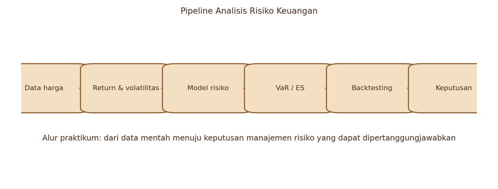

# 1 Prakata dan Orientasi Mata Kuliah

## 1.1 Identitas mata kuliah

| Komponen | Keterangan |
| --- | --- |
| Nama mata kuliah | Matematika Keuangan |
| Program studi | S2 Statistika Terapan, FMIPA Universitas Padjadjaran |
| Semester | 2 |
| Bobot | 3 SKS: Teori 2 SKS dan Praktikum 1 SKS |
| Dosen penulis RPS / author | Dr. Lienda Noviyanti, M.Si |
| Tahun materi | Januari 2025 |
| Perangkat lunak | R dan Python |
| Perangkat keras | TV dan laptop |

## 1.2 Posisi mata kuliah dalam kurikulum S2 Statistika Terapan

Matematika Keuangan dalam konteks S2 Statistika Terapan tidak hanya mengajarkan rumus bunga, harga saham, atau kontrak opsi. Mata kuliah ini menempatkan masalah keuangan sebagai **laboratorium statistika terapan**: mahasiswa belajar menghubungkan data historis, model probabilistik, risiko, keputusan investasi, komputasi, dan interpretasi bisnis. Dengan demikian, mahasiswa tidak berhenti pada jawaban numerik, tetapi mampu menjelaskan mengapa model tertentu digunakan, asumsi apa yang menopang model tersebut, bagaimana data diproses, bagaimana hasil diuji kewajarannya, dan bagaimana hasil akhirnya dikomunikasikan kepada pengambil keputusan.

RPS memetakan mata kuliah ini ke empat capaian pembelajaran utama. Pertama, mahasiswa menganalisis instrumen dan risiko investasi di pasar keuangan dengan pendekatan statistika interdisipliner. Kedua, mahasiswa membangun model diversifikasi portofolio dan strategi alokasi aset berbasis metode Markowitz. Ketiga, mahasiswa merancang algoritma penentuan harga opsi Eropa dan Amerika berbasis Binomial Tree dan simulasi komputer. Keempat, mahasiswa mengelola riset penerapan model stokastik untuk penentuan harga opsi berbasis Brownian motion dan Black-Scholes serta melakukan inovasi pengembangan model. Keempat capaian ini bergerak dari analisis menuju konstruksi model dan akhirnya inovasi, sehingga kelas tidak hanya bersifat teoretis, tetapi juga sangat aplikatif.

Secara pedagogis, materi ini disusun dalam bentuk modul yang dapat dipakai untuk perkuliahan, praktikum, tugas, mini project, UTS, dan UAS. Setiap bagian memuat konsep, definisi, formula, contoh kasus, interpretasi statistik, kode R yang dapat dikembangkan, serta latihan. Nuansa visual dibuat dengan warna coklat degradasi agar konsisten dengan permintaan dan tetap nyaman dibaca. Dalam setiap kotak rumus, warna latar dibuat coklat muda dengan tulisan gelap agar formula tidak berubah menjadi “kopi pekat tanpa gula”: harum, tetapi sulit dibaca.

## 1.3 Peta capaian pembelajaran

| CPMK | Fokus kemampuan | Area materi |
| --- | --- | --- |
| CPMK1 | Menganalisis instrumen dan risiko investasi | Instrumen pasar keuangan, return, risiko, Value at Risk, simulasi historis, Monte Carlo |
| CPMK2 | Membangun model portofolio optimal | Diversifikasi, utility, risk aversion, mean-variance, efficient frontier, CML |
| CPMK3 | Merancang algoritma harga opsi | Opsi call/put, opsi Eropa/Amerika, put-call parity, risk-neutral pricing, Binomial Tree |
| CPMK4 | Mengelola riset model stokastik harga opsi | Brownian motion, proses Ito, Ito Lemma, Black-Scholes, inovasi model |

## 1.4 Cara menggunakan bahan ajar ini

Bahan ajar ini dapat dibaca secara linear dari awal sampai akhir, tetapi juga dapat dipakai secara modular. Mahasiswa yang sedang mengerjakan tugas VaR dapat langsung masuk ke bagian risiko dan simulasi. Mahasiswa yang sedang mengembangkan project Markowitz dapat menggunakan bab portofolio sebagai rujukan konseptual dan kode. Mahasiswa yang sedang mengerjakan algoritma opsi dapat memulai dari bab opsi, Binomial Tree, kemudian melanjutkan ke Black-Scholes. Dalam pembelajaran kelas, dosen dapat memilih bagian teori untuk sesi sinkron, sedangkan bagian kode, latihan, dan studi kasus dapat ditempatkan sebagai praktikum atau belajar mandiri.

**Catatan akademik.** Materi ini menggunakan referensi utama RPS: Bodie, Kane, dan Marcus untuk investasi (Bodie, Kane, dan Marcus 2021), Hull untuk derivatif (Hull 2022), Campbell, Lo, dan MacKinlay untuk ekonometrika pasar keuangan (Campbell, Lo, dan MacKinlay 1997), serta Shreve untuk kalkulus stokastik keuangan (Shreve 2004). Referensi tambahan digunakan untuk memperkuat bagian portofolio, VaR, simulasi Monte Carlo, dan model opsi klasik.

# 2 Kontrak Pembelajaran, Aktivitas, dan Penilaian

Integrasi AI pada Bab 1

### Generative dan Agentic AI untuk Kontrak Pembelajaran, Aktivitas, dan Penilaian

**Arah RPS.** AI untuk forecasting, pricing, portfolio analytics, dan deteksi anomali dengan pembanding model matematis/statistik.

| Komponen | Implementasi pada bab ini |
| --- | --- |
| Target pembelajaran | Mendukung CPMK1 melalui fokus: Pendahuluan Matematika Keuangan; Pengertian dan ruang lingkup matematika keuangan; Definisi investasi dan pengelolaan investasi. |
| Generative AI | Digunakan untuk merumuskan alternatif penjelasan, contoh, dan hipotesis awal. |
| Agentic AI | Dapat menjalankan rangkaian pemeriksaan data–model–diagnostik secara bertahap; agen wajib berhenti pada checkpoint dosen/mahasiswa. |
| Human checkpoint | Mahasiswa memeriksa ketepatan konsep, asumsi metode, hasil numerik, dan interpretasi substantif; keluaran AI tidak diterima sebagai bukti kebenaran. |
| Artefak wajib | prompt log ringkas, keluaran awal, perubahan yang dilakukan mahasiswa, sumber pembanding, kode/notebook yang dapat dijalankan ulang, hasil validasi, dan keputusan akhir manusia. |

**Batas penggunaan.** AI tidak boleh mengerjakan asesmen tertutup, menetapkan kesimpulan akhir, atau menerima/mengirim data sensitif ke layanan yang tidak disetujui. Mahasiswa wajib mampu mengulang dan menjelaskan analisis tanpa bergantung pada percakapan AI.

## 2.1 Prinsip pembelajaran

Pembelajaran Matematika Keuangan dirancang sebagai kombinasi antara teori, praktikum, diskusi, penugasan mandiri, dan project. Pada pertemuan teori, dosen menekankan konsep, derivasi formula, logika model, dan interpretasi. Pada pertemuan praktikum, mahasiswa menerjemahkan konsep ke dalam kode R atau Python. Pada tugas dan project, mahasiswa mengolah data riil, membangun model, menyajikan hasil, dan mempertahankan keputusan analitiknya.

Dalam RPS, penilaian mencakup partisipasi, tugas, kuis, UTS, UAS, dan proyek. SubCPMK1 menekankan identifikasi instrumen dan perhitungan Value at Risk. SubCPMK2 menekankan portofolio Markowitz dan alokasi aset. SubCPMK3 menekankan algoritma harga opsi dengan Binomial Tree. SubCPMK4 menekankan simulasi Brownian motion, penerapan Black-Scholes, dan pengembangan model inovatif. Dengan struktur seperti ini, penilaian tidak sekadar menguji hafalan rumus, tetapi menguji kemampuan berpikir statistik, kemampuan komputasi, dan kemampuan menyampaikan analisis secara profesional.

## 2.2 Format minimal laporan praktikum dan project

Agentic AI dengan checkpoint

#### Penerapan pada Format minimal laporan praktikum dan project

**Konteks:** Pertemuan 1: Kontrak Pembelajaran, Aktivitas, dan Penilaian.

Agen dapat merakit tabel, grafik, pemeriksaan konsistensi, dan daftar klaim–bukti sebelum laporan disetujui manusia. Tetapkan checkpoint sebelum perubahan data, pemilihan model, dan penerbitan hasil. **Mahasiswa wajib memeriksa:** kesesuaian klaim dengan bukti, ketidakpastian, keterbatasan, fairness, dan dampak keputusan. Simpan prompt log ringkas, keluaran awal, perubahan yang dilakukan mahasiswa, sumber pembanding, kode/notebook yang dapat dijalankan ulang, hasil validasi, dan keputusan akhir manusia.

Setiap laporan praktikum atau project sebaiknya memuat komponen berikut. Pertama, latar belakang kasus dan rumusan masalah. Kedua, deskripsi data, sumber data, periode observasi, dan penjelasan variabel. Ketiga, metode yang digunakan, termasuk asumsi dan alasan pemilihan metode. Keempat, hasil analisis dalam bentuk tabel, grafik, dan ringkasan numerik. Kelima, interpretasi hasil dari sudut pandang statistik dan keuangan. Keenam, kesimpulan, rekomendasi, keterbatasan, dan saran pengembangan. Ketujuh, lampiran kode program yang dapat direproduksi.

**Prinsip reproducibility.** Project yang baik bukan hanya project yang menghasilkan angka bagus, tetapi project yang dapat dijalankan ulang oleh orang lain. Gunakan struktur folder yang rapi, tulis sumber data, simpan seed simulasi, beri komentar kode secukupnya, dan pastikan grafik serta tabel berasal dari data yang sama dengan yang dijelaskan di laporan.

# 3 Pengantar Matematika Keuangan, Investasi, dan Pasar Keuangan

Integrasi AI pada Bab 2

### Generative dan Agentic AI untuk Pengantar Matematika Keuangan, Investasi, dan Pasar Keuangan

**Arah RPS.** Stress testing, backtesting, uncertainty, model risk management, interpretabilitas, dan konsekuensi keputusan finansial.

| Komponen | Implementasi pada bab ini |
| --- | --- |
| Target pembelajaran | Mendukung CPMK1 melalui fokus: Pasar keuangan dan instrumen keuangan; Tingkat bunga, premi risiko; Instrumen Investasi & Manajemen Risiko. |
| Generative AI | Digunakan untuk mengurai notasi dan menawarkan langkah derivasi alternatif tanpa menggantikan pembuktian mahasiswa. |
| Agentic AI | Dapat menguji kasus batas, simulasi numerik, dan konsistensi hasil pada beberapa parameter; agen wajib berhenti pada checkpoint dosen/mahasiswa. |
| Human checkpoint | Mahasiswa memeriksa setiap langkah aljabar, syarat regularitas, satuan, kasus batas, dan makna parameter; keluaran AI tidak diterima sebagai bukti kebenaran. |
| Artefak wajib | prompt log ringkas, keluaran awal, perubahan yang dilakukan mahasiswa, sumber pembanding, kode/notebook yang dapat dijalankan ulang, hasil validasi, dan keputusan akhir manusia. |

**Batas penggunaan.** AI tidak boleh mengerjakan asesmen tertutup, menetapkan kesimpulan akhir, atau menerima/mengirim data sensitif ke layanan yang tidak disetujui. Mahasiswa wajib mampu mengulang dan menjelaskan analisis tanpa bergantung pada percakapan AI.

**Tujuan bab.** Mahasiswa memahami ruang lingkup matematika keuangan, definisi investasi, fungsi pasar keuangan, serta hubungan antara tingkat bunga, premi risiko, dan keputusan investasi.

## 3.1 Konteks dan ide utama

Matematika keuangan mempelajari bagaimana nilai uang, risiko, dan waktu dihubungkan dalam suatu kerangka kuantitatif. Di pasar keuangan, keputusan membeli, menjual, menahan, atau melakukan lindung nilai selalu berhubungan dengan ekspektasi masa depan dan ketidakpastian. Dalam matematika keuangan, topik ini penting karena menghubungkan konsep abstrak dengan keputusan yang benar-benar dihadapi investor, analis risiko, manajer portofolio, dan pengembang produk derivatif. Mahasiswa S2 Statistika Terapan perlu memandang investasi dan pasar keuangan bukan sekadar sebagai istilah keuangan, tetapi sebagai objek analisis statistik: ada data, ada ketidakpastian, ada model, ada parameter, ada estimasi, dan ada keputusan.

Literatur investasi modern menekankan bahwa keputusan keuangan selalu melibatkan trade-off antara return dan risiko (Bodie, Kane, dan Marcus 2021). Pada saat yang sama, pemodelan derivatif dan risiko pasar membutuhkan pemahaman probabilitas, simulasi, dan proses stokastik (Hull 2022; Shreve 2004). Karena itu, bagian ini selalu dibaca dengan dua kacamata: kacamata ekonomi-keuangan untuk memahami makna keputusan, dan kacamata statistika-komputasi untuk memahami bagaimana angka dihasilkan. Rujukan utama bagian ini antara lain (Bodie, Kane, dan Marcus 2021); (Luenberger 1998).

Dalam analisis keuangan, nilai numerik sebaiknya tidak diperlakukan sebagai jawaban final, melainkan sebagai titik awal interpretasi. Return tinggi dapat menarik, tetapi tanpa pemahaman volatilitas, korelasi, drawdown, likuiditas, dan horizon investasi, keputusan akan menjadi rapuh. Inilah alasan pendekatan statistika sangat penting: statistika membantu membedakan sinyal dari kebisingan, pola dari kebetulan, dan risiko terukur dari ketidakpastian yang belum dipahami.

Setiap model membawa asumsi. Pada tahap pembelajaran, asumsi sering tampak sebagai syarat teknis; pada praktik profesional, asumsi berubah menjadi sumber risiko model. Asumsi normalitas return, kestasioneran volatilitas, independensi residual, atau tidak adanya biaya transaksi dapat memudahkan perhitungan, tetapi hasilnya perlu diuji dengan data dan dibaca secara kritis.

Kekuatan mata kuliah ini terletak pada integrasi teori, komputasi, dan komunikasi. Mahasiswa diharapkan mampu menulis kode yang benar, tetapi juga mampu menjelaskan keluaran kode tersebut. Grafik, tabel, dan angka ringkasan perlu diterjemahkan menjadi narasi keputusan: apakah portofolio terlalu terkonsentrasi, apakah VaR terlalu optimistis, apakah opsi terlihat mahal atau murah, dan apakah model masih sesuai dengan kondisi pasar.

Dalam kelas S2, pembahasan tidak cukup berhenti pada contoh sederhana. Contoh sederhana tetap penting untuk membangun intuisi, tetapi setelah itu mahasiswa perlu bertanya: bagaimana jika data tidak normal, bagaimana jika return memiliki ekor tebal, bagaimana jika korelasi berubah saat krisis, bagaimana jika volatilitas naik tiba-tiba, dan bagaimana jika pembatasan investasi membuat solusi optimal secara matematis tidak realistis secara kebijakan.

Secara praktis, investasi dan pasar keuangan sering menuntut keputusan yang tidak sepenuhnya pasti. Misalnya, ketika analis memilih instrumen investasi, ia tidak mengetahui harga masa depan; ketika menghitung VaR, ia tidak mengetahui kerugian esok hari; ketika memilih bobot portofolio, ia tidak mengetahui return aktual; dan ketika menentukan harga opsi, ia tidak mengetahui lintasan harga aset hingga jatuh tempo. Model berperan sebagai peta, bukan wilayah itu sendiri. Peta yang baik membantu perjalanan, tetapi peta tetap perlu dibandingkan dengan medan sebenarnya. Dalam bahasa keuangan: model harus berguna, tetapi pengguna model tidak boleh jatuh cinta terlalu dalam pada modelnya. Model itu partner kerja, bukan jodoh abadi.

Dalam pembelajaran, kita memisahkan tiga lapis pemahaman. Lapis pertama adalah definisi dan formula. Lapis kedua adalah algoritma komputasi. Lapis ketiga adalah interpretasi dan evaluasi model. Banyak kesalahan mahasiswa terjadi ketika hanya menguasai lapis pertama, tetapi tidak memahami lapis kedua dan ketiga. Sebaliknya, banyak kesalahan praktisi terjadi ketika kode berjalan lancar, tetapi asumsi model tidak dibaca. Oleh karena itu, setiap pembahasan dalam bab ini akan diarahkan pada pemahaman konseptual, prosedural, dan kritis.

## 3.2 Definisi, notasi, dan formula inti

### 3.2.1 Formula yang perlu dikuasai

$$FV = PV(1+i)^n$$

$$PV = \frac{FV}{(1+i)^n}$$

$$1+i_{\text{nominal}} \approx (1+r_{\text{real}})(1+\pi)$$

Formula di atas harus dibaca bersama konteksnya. Simbol yang sama dapat memiliki arti berbeda dalam topik berbeda. Misalnya, $r$ dapat berarti tingkat bunga bebas risiko, return diskrit, atau log-return tergantung model. Demikian pula $\sigma$ dapat berarti volatilitas historis, volatilitas implisit, atau parameter difusi pada proses stokastik. Dalam laporan akademik, notasi harus ditulis konsisten sejak awal. Ketidakkonsistenan notasi sering membuat pembaca merasa seperti membaca peta harta karun, tetapi petanya digambar oleh tiga bajak laut yang tidak saling bicara.

Pada level komputasi, formula harus diterjemahkan menjadi langkah yang dapat diuji. Setiap variabel harus berasal dari data atau asumsi yang eksplisit. Jika menggunakan data harga, jelaskan apakah return yang dihitung adalah return sederhana atau log-return. Jika menggunakan volatilitas, jelaskan apakah volatilitas diannualisasi. Jika menggunakan tingkat bunga, jelaskan apakah bunga dinyatakan dalam compounding diskrit atau kontinu. Detail seperti ini terlihat kecil, tetapi dapat mengubah hasil secara substansial.

## 3.3 Contoh kasus terarah: pemilihan instrumen antara deposito, obligasi, saham, dan reksa dana untuk horizon investasi satu tahun

AI untuk aplikasi dan komunikasi

#### Penerapan pada Contoh kasus terarah: pemilihan instrumen antara deposito, obligasi, saham, dan reksa dana untuk horizon investasi satu tahun

**Konteks:** Pertemuan 2: Pengantar Matematika Keuangan, Investasi, dan Pasar Keuangan.

Terapkan arahan RPS berikut pada kasus bab ini: Stress testing, backtesting, uncertainty, model risk management, interpretabilitas, dan konsekuensi keputusan finansial. Generative AI dapat menghasilkan beberapa skenario pemangku kepentingan dan draf narasi yang kemudian diperiksa terhadap hasil analisis; Agentic AI dapat merakit tabel, grafik, pemeriksaan konsistensi, dan daftar klaim–bukti sebelum laporan disetujui manusia. Checkpoint manusia mencakup kesesuaian klaim dengan bukti, ketidakpastian, keterbatasan, fairness, dan dampak keputusan. Semua klaim harus ditautkan ke output, ketidakpastian, dan sumber yang dapat diperiksa.

Bayangkan seorang analis pada institusi keuangan ingin menggunakan investasi dan pasar keuangan untuk membantu keputusan alokasi dana. Data yang tersedia berupa harga historis beberapa instrumen, informasi tingkat bunga bebas risiko, dan batasan kebijakan investasi. Tujuan analis bukan hanya menghitung angka, melainkan menyusun argumen yang dapat dipertanggungjawabkan: instrumen mana yang dipilih, risiko mana yang dominan, asumsi mana yang digunakan, hasil mana yang stabil, dan rekomendasi apa yang masuk akal.

Langkah pertama adalah melakukan pemeriksaan data. Periksa missing value, outlier, perubahan denominasi, corporate action, serta konsistensi frekuensi data. Dalam data keuangan, kesalahan kecil pada data harga dapat menghasilkan return ekstrem yang bukan risiko pasar, melainkan risiko spreadsheet. Langkah kedua adalah menghitung ringkasan statistik: mean, median, standar deviasi, quantile, skewness, kurtosis, korelasi, dan grafik time series. Langkah ketiga adalah menerapkan model sesuai tujuan analisis. Langkah keempat adalah mengevaluasi kewajaran output model dan menulis interpretasi.

Pada laporan mahasiswa, contoh kasus sebaiknya tidak berhenti pada angka final. Misalnya, jika hasil menunjukkan bahwa suatu aset memiliki volatilitas tinggi, jelaskan apakah volatilitas itu konsisten dengan karakter aset tersebut. Jika hasil menunjukkan korelasi negatif antara dua aset, jelaskan implikasinya untuk diversifikasi. Jika hasil opsi menunjukkan harga model lebih rendah dari harga pasar, diskusikan kemungkinan adanya perbedaan volatilitas implisit, biaya transaksi, likuiditas, atau asumsi model.

## 3.4 Implementasi awal di R

Agentic AI dengan checkpoint

#### Penerapan pada Implementasi awal di R

**Konteks:** Pertemuan 2: Pengantar Matematika Keuangan, Investasi, dan Pasar Keuangan.

Agen dapat menjalankan rangkaian pemeriksaan data–model–diagnostik secara bertahap. Tetapkan checkpoint sebelum perubahan data, pemilihan model, dan penerbitan hasil. **Mahasiswa wajib memeriksa:** ketepatan konsep, asumsi metode, hasil numerik, dan interpretasi substantif. Simpan prompt log ringkas, keluaran awal, perubahan yang dilakukan mahasiswa, sumber pembanding, kode/notebook yang dapat dijalankan ulang, hasil validasi, dan keputusan akhir manusia.

```r
# Kerangka sederhana nilai masa depan dan nilai sekarang
pv <- 100000000
rate <- 0.06
n <- 3
fv <- pv * (1 + rate)^n
pv_back <- fv / (1 + rate)^n
c(PV = pv, FV = fv, PV_ulang = pv_back)
```

Kode di atas bersifat kerangka awal. Dalam praktikum, mahasiswa perlu menyesuaikan kode dengan data riil, nama kolom, frekuensi data, dan tujuan analisis. Dosen dapat meminta mahasiswa menjalankan kode secara bertahap: mulai dari import data, pembersihan, transformasi return, estimasi parameter, visualisasi, hingga penyusunan output. Pendekatan bertahap ini membantu menghindari kesalahan umum ketika mahasiswa langsung menyalin kode panjang tanpa memahami fungsi setiap baris.

## 3.5 Interpretasi, validasi, dan jebakan umum

Validasi dalam investasi dan pasar keuangan mencakup validasi matematis dan validasi empiris. Validasi matematis berarti memeriksa apakah formula, batasan, dan algoritma sudah benar. Validasi empiris berarti memeriksa apakah output masuk akal terhadap data dan konteks pasar. Dalam kasus VaR, validasi empiris dapat berupa backtesting jumlah pelanggaran. Dalam kasus portofolio, validasi dapat berupa uji sensitivitas terhadap estimasi mean dan kovarians. Dalam kasus opsi, validasi dapat berupa pembandingan harga model dengan harga pasar atau dengan model lain.

Jebakan pertama adalah memperlakukan data historis sebagai masa depan yang pasti. Data historis penting, tetapi pasar bisa berubah. Jebakan kedua adalah mengabaikan horizon waktu. Risiko satu hari tidak sama dengan risiko satu bulan, dan volatilitas harian tidak boleh dicampur dengan return bulanan tanpa annualization yang benar. Jebakan ketiga adalah menganggap optimasi selalu menghasilkan jawaban yang stabil. Pada portofolio mean-variance, bobot optimal dapat berubah drastis ketika estimasi mean sedikit berubah. Jebakan keempat adalah menafsirkan hasil model tanpa mempertimbangkan biaya transaksi, likuiditas, pajak, dan batasan institusional.

Dari sisi penulisan akademik, interpretasi yang baik memiliki tiga komponen: angka, makna, dan konsekuensi. Angka menunjukkan hasil. Makna menjelaskan apa arti hasil itu dalam bahasa statistik dan keuangan. Konsekuensi menjelaskan implikasi keputusan. Contoh interpretasi yang lemah adalah: “VaR sebesar 2%.” Contoh yang lebih kuat adalah: “Pada tingkat keyakinan 95%, estimasi VaR harian portofolio sebesar 2% menunjukkan bahwa dalam kondisi historis yang digunakan, kerugian harian diperkirakan tidak melebihi 2% pada sekitar 95 dari 100 hari; namun hasil ini sensitif terhadap periode data dan tidak menangkap risiko ekor ekstrem secara sempurna.”

## 3.6 Latihan dan diskusi

Aturan AI untuk latihan dan asesmen

#### Penerapan pada Latihan dan diskusi

**Konteks:** Pertemuan 2: Pengantar Matematika Keuangan, Investasi, dan Pasar Keuangan.

Ikuti status asesmen yang ditetapkan dosen: tanpa AI, AI terbatas, atau AI terbuka. Jika diizinkan, AI hanya memberi kritik, pertanyaan tandingan, atau pemeriksaan awal; jawaban, keputusan metode, dan pembelaan lisan tetap karya mahasiswa. Bukti yang diserahkan: prompt log ringkas, keluaran awal, perubahan yang dilakukan mahasiswa, sumber pembanding, kode/notebook yang dapat dijalankan ulang, hasil validasi, dan keputusan akhir manusia.

1. Jelaskan perbedaan investasi dan spekulasi dari perspektif risiko, horizon, dan informasi.
2. Hitung nilai masa depan Rp100 juta dengan bunga 6% selama 1, 3, dan 5 tahun.
3. Diskusikan mengapa premi risiko dibutuhkan dalam pasar keuangan.

Untuk diskusi kelas, mahasiswa dapat diminta membandingkan jawaban antar-kelompok. Perbedaan hasil bukan selalu berarti ada kelompok yang salah. Dalam analisis keuangan, hasil dapat berbeda karena pilihan periode data, frekuensi return, metode estimasi volatilitas, asumsi risk-free rate, atau batasan optimasi. Yang penting adalah setiap pilihan metodologis dijelaskan secara transparan dan konsisten.

# 4 Return, Risiko, Tingkat Bunga, dan Premi Risiko

Integrasi AI pada Bab 3

### Generative dan Agentic AI untuk Return, Risiko, Tingkat Bunga, dan Premi Risiko

**Arah RPS.** Studi kasus menggunakan data pasar nyata dengan dokumentasi asumsi, keterbatasan, dan risiko penggunaan otomatisasi.

| Komponen | Implementasi pada bab ini |
| --- | --- |
| Target pembelajaran | Mendukung CPMK1 melalui fokus: Jenis-jenis instrumen investasi (saham, obligasi, SBI, dsb.); Pengukuran dan pengelolaan risiko investasi; Value at Risk (VaR). |
| Generative AI | Digunakan untuk mengurai notasi dan menawarkan langkah derivasi alternatif tanpa menggantikan pembuktian mahasiswa. |
| Agentic AI | Dapat menguji kasus batas, simulasi numerik, dan konsistensi hasil pada beberapa parameter; agen wajib berhenti pada checkpoint dosen/mahasiswa. |
| Human checkpoint | Mahasiswa memeriksa setiap langkah aljabar, syarat regularitas, satuan, kasus batas, dan makna parameter; keluaran AI tidak diterima sebagai bukti kebenaran. |
| Artefak wajib | prompt log ringkas, keluaran awal, perubahan yang dilakukan mahasiswa, sumber pembanding, kode/notebook yang dapat dijalankan ulang, hasil validasi, dan keputusan akhir manusia. |

**Batas penggunaan.** AI tidak boleh mengerjakan asesmen tertutup, menetapkan kesimpulan akhir, atau menerima/mengirim data sensitif ke layanan yang tidak disetujui. Mahasiswa wajib mampu mengulang dan menjelaskan analisis tanpa bergantung pada percakapan AI.

**Tujuan bab.** Mahasiswa mampu menghitung return sederhana, log-return, volatilitas, annualization, dan premi risiko sebagai dasar analisis investasi.

## 4.1 Konteks dan ide utama

Return adalah ukuran perubahan nilai investasi, sedangkan risiko menggambarkan ketidakpastian return. Dalam praktik, return dan risiko tidak dapat dipisahkan: aset yang menawarkan return lebih tinggi biasanya membawa risiko lebih besar, walaupun hubungan ini tidak selalu linear pada semua horizon. Dalam matematika keuangan, topik ini penting karena menghubungkan konsep abstrak dengan keputusan yang benar-benar dihadapi investor, analis risiko, manajer portofolio, dan pengembang produk derivatif. Mahasiswa S2 Statistika Terapan perlu memandang return dan risiko bukan sekadar sebagai istilah keuangan, tetapi sebagai objek analisis statistik: ada data, ada ketidakpastian, ada model, ada parameter, ada estimasi, dan ada keputusan.

Literatur investasi modern menekankan bahwa keputusan keuangan selalu melibatkan trade-off antara return dan risiko (Bodie, Kane, dan Marcus 2021). Pada saat yang sama, pemodelan derivatif dan risiko pasar membutuhkan pemahaman probabilitas, simulasi, dan proses stokastik (Hull 2022; Shreve 2004). Karena itu, bagian ini selalu dibaca dengan dua kacamata: kacamata ekonomi-keuangan untuk memahami makna keputusan, dan kacamata statistika-komputasi untuk memahami bagaimana angka dihasilkan. Rujukan utama bagian ini antara lain (Campbell, Lo, dan MacKinlay 1997); (Tsay 2010).

Dalam analisis keuangan, nilai numerik sebaiknya tidak diperlakukan sebagai jawaban final, melainkan sebagai titik awal interpretasi. Return tinggi dapat menarik, tetapi tanpa pemahaman volatilitas, korelasi, drawdown, likuiditas, dan horizon investasi, keputusan akan menjadi rapuh. Inilah alasan pendekatan statistika sangat penting: statistika membantu membedakan sinyal dari kebisingan, pola dari kebetulan, dan risiko terukur dari ketidakpastian yang belum dipahami.

Setiap model membawa asumsi. Pada tahap pembelajaran, asumsi sering tampak sebagai syarat teknis; pada praktik profesional, asumsi berubah menjadi sumber risiko model. Asumsi normalitas return, kestasioneran volatilitas, independensi residual, atau tidak adanya biaya transaksi dapat memudahkan perhitungan, tetapi hasilnya perlu diuji dengan data dan dibaca secara kritis.

Kekuatan mata kuliah ini terletak pada integrasi teori, komputasi, dan komunikasi. Mahasiswa diharapkan mampu menulis kode yang benar, tetapi juga mampu menjelaskan keluaran kode tersebut. Grafik, tabel, dan angka ringkasan perlu diterjemahkan menjadi narasi keputusan: apakah portofolio terlalu terkonsentrasi, apakah VaR terlalu optimistis, apakah opsi terlihat mahal atau murah, dan apakah model masih sesuai dengan kondisi pasar.

Dalam kelas S2, pembahasan tidak cukup berhenti pada contoh sederhana. Contoh sederhana tetap penting untuk membangun intuisi, tetapi setelah itu mahasiswa perlu bertanya: bagaimana jika data tidak normal, bagaimana jika return memiliki ekor tebal, bagaimana jika korelasi berubah saat krisis, bagaimana jika volatilitas naik tiba-tiba, dan bagaimana jika pembatasan investasi membuat solusi optimal secara matematis tidak realistis secara kebijakan.

Secara praktis, return dan risiko sering menuntut keputusan yang tidak sepenuhnya pasti. Misalnya, ketika analis memilih instrumen investasi, ia tidak mengetahui harga masa depan; ketika menghitung VaR, ia tidak mengetahui kerugian esok hari; ketika memilih bobot portofolio, ia tidak mengetahui return aktual; dan ketika menentukan harga opsi, ia tidak mengetahui lintasan harga aset hingga jatuh tempo. Model berperan sebagai peta, bukan wilayah itu sendiri. Peta yang baik membantu perjalanan, tetapi peta tetap perlu dibandingkan dengan medan sebenarnya. Dalam bahasa keuangan: model harus berguna, tetapi pengguna model tidak boleh jatuh cinta terlalu dalam pada modelnya. Model itu partner kerja, bukan jodoh abadi.

Dalam pembelajaran, kita memisahkan tiga lapis pemahaman. Lapis pertama adalah definisi dan formula. Lapis kedua adalah algoritma komputasi. Lapis ketiga adalah interpretasi dan evaluasi model. Banyak kesalahan mahasiswa terjadi ketika hanya menguasai lapis pertama, tetapi tidak memahami lapis kedua dan ketiga. Sebaliknya, banyak kesalahan praktisi terjadi ketika kode berjalan lancar, tetapi asumsi model tidak dibaca. Oleh karena itu, setiap pembahasan dalam bab ini akan diarahkan pada pemahaman konseptual, prosedural, dan kritis.

## 4.2 Definisi, notasi, dan formula inti

### 4.2.1 Formula yang perlu dikuasai

$$R_t = \frac{P_t - P_{t-1} + D_t}{P_{t-1}}$$

$$r_t = \ln\left(\frac{P_t}{P_{t-1}}\right)$$

$$\sigma_{\text{annual}} = \sigma_{\text{period}}\sqrt{m}$$

$$\text{Risk Premium} = E(R_i) - R_f$$

Formula di atas harus dibaca bersama konteksnya. Simbol yang sama dapat memiliki arti berbeda dalam topik berbeda. Misalnya, $r$ dapat berarti tingkat bunga bebas risiko, return diskrit, atau log-return tergantung model. Demikian pula $\sigma$ dapat berarti volatilitas historis, volatilitas implisit, atau parameter difusi pada proses stokastik. Dalam laporan akademik, notasi harus ditulis konsisten sejak awal. Ketidakkonsistenan notasi sering membuat pembaca merasa seperti membaca peta harta karun, tetapi petanya digambar oleh tiga bajak laut yang tidak saling bicara.

Pada level komputasi, formula harus diterjemahkan menjadi langkah yang dapat diuji. Setiap variabel harus berasal dari data atau asumsi yang eksplisit. Jika menggunakan data harga, jelaskan apakah return yang dihitung adalah return sederhana atau log-return. Jika menggunakan volatilitas, jelaskan apakah volatilitas diannualisasi. Jika menggunakan tingkat bunga, jelaskan apakah bunga dinyatakan dalam compounding diskrit atau kontinu. Detail seperti ini terlihat kecil, tetapi dapat mengubah hasil secara substansial.

## 4.3 Contoh kasus terarah: analisis return harian saham dan pembandingan dengan tingkat bunga bebas risiko

AI untuk aplikasi dan komunikasi

#### Penerapan pada Contoh kasus terarah: analisis return harian saham dan pembandingan dengan tingkat bunga bebas risiko

**Konteks:** Pertemuan 3: Return, Risiko, Tingkat Bunga, dan Premi Risiko.

Terapkan arahan RPS berikut pada kasus bab ini: Studi kasus menggunakan data pasar nyata dengan dokumentasi asumsi, keterbatasan, dan risiko penggunaan otomatisasi. Generative AI dapat menghasilkan beberapa skenario pemangku kepentingan dan draf narasi yang kemudian diperiksa terhadap hasil analisis; Agentic AI dapat merakit tabel, grafik, pemeriksaan konsistensi, dan daftar klaim–bukti sebelum laporan disetujui manusia. Checkpoint manusia mencakup kesesuaian klaim dengan bukti, ketidakpastian, keterbatasan, fairness, dan dampak keputusan. Semua klaim harus ditautkan ke output, ketidakpastian, dan sumber yang dapat diperiksa.

Bayangkan seorang analis pada institusi keuangan ingin menggunakan return dan risiko untuk membantu keputusan alokasi dana. Data yang tersedia berupa harga historis beberapa instrumen, informasi tingkat bunga bebas risiko, dan batasan kebijakan investasi. Tujuan analis bukan hanya menghitung angka, melainkan menyusun argumen yang dapat dipertanggungjawabkan: instrumen mana yang dipilih, risiko mana yang dominan, asumsi mana yang digunakan, hasil mana yang stabil, dan rekomendasi apa yang masuk akal.

Langkah pertama adalah melakukan pemeriksaan data. Periksa missing value, outlier, perubahan denominasi, corporate action, serta konsistensi frekuensi data. Dalam data keuangan, kesalahan kecil pada data harga dapat menghasilkan return ekstrem yang bukan risiko pasar, melainkan risiko spreadsheet. Langkah kedua adalah menghitung ringkasan statistik: mean, median, standar deviasi, quantile, skewness, kurtosis, korelasi, dan grafik time series. Langkah ketiga adalah menerapkan model sesuai tujuan analisis. Langkah keempat adalah mengevaluasi kewajaran output model dan menulis interpretasi.

Pada laporan mahasiswa, contoh kasus sebaiknya tidak berhenti pada angka final. Misalnya, jika hasil menunjukkan bahwa suatu aset memiliki volatilitas tinggi, jelaskan apakah volatilitas itu konsisten dengan karakter aset tersebut. Jika hasil menunjukkan korelasi negatif antara dua aset, jelaskan implikasinya untuk diversifikasi. Jika hasil opsi menunjukkan harga model lebih rendah dari harga pasar, diskusikan kemungkinan adanya perbedaan volatilitas implisit, biaya transaksi, likuiditas, atau asumsi model.

## 4.4 Implementasi awal di R

Agentic AI dengan checkpoint

#### Penerapan pada Implementasi awal di R

**Konteks:** Pertemuan 3: Return, Risiko, Tingkat Bunga, dan Premi Risiko.

Agen dapat menguji kasus batas, simulasi numerik, dan konsistensi hasil pada beberapa parameter. Tetapkan checkpoint sebelum perubahan data, pemilihan model, dan penerbitan hasil. **Mahasiswa wajib memeriksa:** setiap langkah aljabar, syarat regularitas, satuan, kasus batas, dan makna parameter. Simpan prompt log ringkas, keluaran awal, perubahan yang dilakukan mahasiswa, sumber pembanding, kode/notebook yang dapat dijalankan ulang, hasil validasi, dan keputusan akhir manusia.

```r
# Simulasi data harga dan perhitungan return
set.seed(2025)
price <- cumprod(1 + rnorm(260, mean = 0.0004, sd = 0.015)) * 100
ret_simple <- price[-1] / price[-length(price)] - 1
ret_log <- diff(log(price))
summary(ret_simple)
sd_daily <- sd(ret_log)
sd_annual <- sd_daily * sqrt(252)
c(sd_harian = sd_daily, sd_tahunan = sd_annual)
```

Kode di atas bersifat kerangka awal. Dalam praktikum, mahasiswa perlu menyesuaikan kode dengan data riil, nama kolom, frekuensi data, dan tujuan analisis. Dosen dapat meminta mahasiswa menjalankan kode secara bertahap: mulai dari import data, pembersihan, transformasi return, estimasi parameter, visualisasi, hingga penyusunan output. Pendekatan bertahap ini membantu menghindari kesalahan umum ketika mahasiswa langsung menyalin kode panjang tanpa memahami fungsi setiap baris.

## 4.5 Interpretasi, validasi, dan jebakan umum

Validasi dalam return dan risiko mencakup validasi matematis dan validasi empiris. Validasi matematis berarti memeriksa apakah formula, batasan, dan algoritma sudah benar. Validasi empiris berarti memeriksa apakah output masuk akal terhadap data dan konteks pasar. Dalam kasus VaR, validasi empiris dapat berupa backtesting jumlah pelanggaran. Dalam kasus portofolio, validasi dapat berupa uji sensitivitas terhadap estimasi mean dan kovarians. Dalam kasus opsi, validasi dapat berupa pembandingan harga model dengan harga pasar atau dengan model lain.

Jebakan pertama adalah memperlakukan data historis sebagai masa depan yang pasti. Data historis penting, tetapi pasar bisa berubah. Jebakan kedua adalah mengabaikan horizon waktu. Risiko satu hari tidak sama dengan risiko satu bulan, dan volatilitas harian tidak boleh dicampur dengan return bulanan tanpa annualization yang benar. Jebakan ketiga adalah menganggap optimasi selalu menghasilkan jawaban yang stabil. Pada portofolio mean-variance, bobot optimal dapat berubah drastis ketika estimasi mean sedikit berubah. Jebakan keempat adalah menafsirkan hasil model tanpa mempertimbangkan biaya transaksi, likuiditas, pajak, dan batasan institusional.

Dari sisi penulisan akademik, interpretasi yang baik memiliki tiga komponen: angka, makna, dan konsekuensi. Angka menunjukkan hasil. Makna menjelaskan apa arti hasil itu dalam bahasa statistik dan keuangan. Konsekuensi menjelaskan implikasi keputusan. Contoh interpretasi yang lemah adalah: “VaR sebesar 2%.” Contoh yang lebih kuat adalah: “Pada tingkat keyakinan 95%, estimasi VaR harian portofolio sebesar 2% menunjukkan bahwa dalam kondisi historis yang digunakan, kerugian harian diperkirakan tidak melebihi 2% pada sekitar 95 dari 100 hari; namun hasil ini sensitif terhadap periode data dan tidak menangkap risiko ekor ekstrem secara sempurna.”

## 4.6 Latihan dan diskusi

Aturan AI untuk latihan dan asesmen

#### Penerapan pada Latihan dan diskusi

**Konteks:** Pertemuan 3: Return, Risiko, Tingkat Bunga, dan Premi Risiko.

Ikuti status asesmen yang ditetapkan dosen: tanpa AI, AI terbatas, atau AI terbuka. Jika diizinkan, AI hanya memberi kritik, pertanyaan tandingan, atau pemeriksaan awal; jawaban, keputusan metode, dan pembelaan lisan tetap karya mahasiswa. Bukti yang diserahkan: prompt log ringkas, keluaran awal, perubahan yang dilakukan mahasiswa, sumber pembanding, kode/notebook yang dapat dijalankan ulang, hasil validasi, dan keputusan akhir manusia.

1. Ambil data harga satu saham selama minimal satu tahun dan hitung return sederhana serta log-return.
2. Jelaskan kapan log-return lebih nyaman digunakan dibanding return sederhana.
3. Hitung volatilitas tahunan dari volatilitas harian dan jelaskan asumsi yang melekat.

Untuk diskusi kelas, mahasiswa dapat diminta membandingkan jawaban antar-kelompok. Perbedaan hasil bukan selalu berarti ada kelompok yang salah. Dalam analisis keuangan, hasil dapat berbeda karena pilihan periode data, frekuensi return, metode estimasi volatilitas, asumsi risk-free rate, atau batasan optimasi. Yang penting adalah setiap pilihan metodologis dijelaskan secara transparan dan konsisten.

# 5 Instrumen Investasi: Saham, Obligasi, SBI, Reksa Dana, dan Derivatif

Integrasi AI pada Bab 4

### Generative dan Agentic AI untuk Instrumen Investasi: Saham, Obligasi, SBI, Reksa Dana, dan Derivatif

**Arah RPS.** AI untuk forecasting, pricing, portfolio analytics, dan deteksi anomali dengan pembanding model matematis/statistik.

| Komponen | Implementasi pada bab ini |
| --- | --- |
| Target pembelajaran | Mendukung CPMK1 melalui fokus: Simulasi historis dan Monte Carlo untuk risiko; Analisis Portofolio dan Diversifikasi; Konsep risiko dan risk aversion; Utility function dan toleransi risiko. |
| Generative AI | Digunakan untuk mengurai notasi dan menawarkan langkah derivasi alternatif tanpa menggantikan pembuktian mahasiswa. |
| Agentic AI | Dapat menguji kasus batas, simulasi numerik, dan konsistensi hasil pada beberapa parameter; agen wajib berhenti pada checkpoint dosen/mahasiswa. |
| Human checkpoint | Mahasiswa memeriksa setiap langkah aljabar, syarat regularitas, satuan, kasus batas, dan makna parameter; keluaran AI tidak diterima sebagai bukti kebenaran. |
| Artefak wajib | prompt log ringkas, keluaran awal, perubahan yang dilakukan mahasiswa, sumber pembanding, kode/notebook yang dapat dijalankan ulang, hasil validasi, dan keputusan akhir manusia. |

**Batas penggunaan.** AI tidak boleh mengerjakan asesmen tertutup, menetapkan kesimpulan akhir, atau menerima/mengirim data sensitif ke layanan yang tidak disetujui. Mahasiswa wajib mampu mengulang dan menjelaskan analisis tanpa bergantung pada percakapan AI.

**Tujuan bab.** Mahasiswa mampu mengidentifikasi jenis instrumen keuangan, karakteristik risiko-return, likuiditas, horizon investasi, dan peran setiap instrumen dalam portofolio.

## 5.1 Konteks dan ide utama

Instrumen investasi memiliki struktur arus kas, risiko, dan tujuan yang berbeda. Saham memberikan klaim kepemilikan, obligasi memberikan klaim arus kas tetap atau kupon, SBI atau instrumen bebas risiko relatif digunakan sebagai acuan, reksa dana memberi diversifikasi terkelola, dan derivatif memberikan hak atau kewajiban terkait aset dasar. Dalam matematika keuangan, topik ini penting karena menghubungkan konsep abstrak dengan keputusan yang benar-benar dihadapi investor, analis risiko, manajer portofolio, dan pengembang produk derivatif. Mahasiswa S2 Statistika Terapan perlu memandang instrumen investasi bukan sekadar sebagai istilah keuangan, tetapi sebagai objek analisis statistik: ada data, ada ketidakpastian, ada model, ada parameter, ada estimasi, dan ada keputusan.

Literatur investasi modern menekankan bahwa keputusan keuangan selalu melibatkan trade-off antara return dan risiko (Bodie, Kane, dan Marcus 2021). Pada saat yang sama, pemodelan derivatif dan risiko pasar membutuhkan pemahaman probabilitas, simulasi, dan proses stokastik (Hull 2022; Shreve 2004). Karena itu, bagian ini selalu dibaca dengan dua kacamata: kacamata ekonomi-keuangan untuk memahami makna keputusan, dan kacamata statistika-komputasi untuk memahami bagaimana angka dihasilkan. Rujukan utama bagian ini antara lain (Bodie, Kane, dan Marcus 2021); (Hull 2022).

Dalam analisis keuangan, nilai numerik sebaiknya tidak diperlakukan sebagai jawaban final, melainkan sebagai titik awal interpretasi. Return tinggi dapat menarik, tetapi tanpa pemahaman volatilitas, korelasi, drawdown, likuiditas, dan horizon investasi, keputusan akan menjadi rapuh. Inilah alasan pendekatan statistika sangat penting: statistika membantu membedakan sinyal dari kebisingan, pola dari kebetulan, dan risiko terukur dari ketidakpastian yang belum dipahami.

Setiap model membawa asumsi. Pada tahap pembelajaran, asumsi sering tampak sebagai syarat teknis; pada praktik profesional, asumsi berubah menjadi sumber risiko model. Asumsi normalitas return, kestasioneran volatilitas, independensi residual, atau tidak adanya biaya transaksi dapat memudahkan perhitungan, tetapi hasilnya perlu diuji dengan data dan dibaca secara kritis.

Kekuatan mata kuliah ini terletak pada integrasi teori, komputasi, dan komunikasi. Mahasiswa diharapkan mampu menulis kode yang benar, tetapi juga mampu menjelaskan keluaran kode tersebut. Grafik, tabel, dan angka ringkasan perlu diterjemahkan menjadi narasi keputusan: apakah portofolio terlalu terkonsentrasi, apakah VaR terlalu optimistis, apakah opsi terlihat mahal atau murah, dan apakah model masih sesuai dengan kondisi pasar.

Dalam kelas S2, pembahasan tidak cukup berhenti pada contoh sederhana. Contoh sederhana tetap penting untuk membangun intuisi, tetapi setelah itu mahasiswa perlu bertanya: bagaimana jika data tidak normal, bagaimana jika return memiliki ekor tebal, bagaimana jika korelasi berubah saat krisis, bagaimana jika volatilitas naik tiba-tiba, dan bagaimana jika pembatasan investasi membuat solusi optimal secara matematis tidak realistis secara kebijakan.

Secara praktis, instrumen investasi sering menuntut keputusan yang tidak sepenuhnya pasti. Misalnya, ketika analis memilih instrumen investasi, ia tidak mengetahui harga masa depan; ketika menghitung VaR, ia tidak mengetahui kerugian esok hari; ketika memilih bobot portofolio, ia tidak mengetahui return aktual; dan ketika menentukan harga opsi, ia tidak mengetahui lintasan harga aset hingga jatuh tempo. Model berperan sebagai peta, bukan wilayah itu sendiri. Peta yang baik membantu perjalanan, tetapi peta tetap perlu dibandingkan dengan medan sebenarnya. Dalam bahasa keuangan: model harus berguna, tetapi pengguna model tidak boleh jatuh cinta terlalu dalam pada modelnya. Model itu partner kerja, bukan jodoh abadi.

Dalam pembelajaran, kita memisahkan tiga lapis pemahaman. Lapis pertama adalah definisi dan formula. Lapis kedua adalah algoritma komputasi. Lapis ketiga adalah interpretasi dan evaluasi model. Banyak kesalahan mahasiswa terjadi ketika hanya menguasai lapis pertama, tetapi tidak memahami lapis kedua dan ketiga. Sebaliknya, banyak kesalahan praktisi terjadi ketika kode berjalan lancar, tetapi asumsi model tidak dibaca. Oleh karena itu, setiap pembahasan dalam bab ini akan diarahkan pada pemahaman konseptual, prosedural, dan kritis.

## 5.2 Definisi, notasi, dan formula inti

### 5.2.1 Formula yang perlu dikuasai

$$P_{\text{obligasi}} = \sum_{t=1}^{T}\frac{C}{(1+y)^t}+\frac{F}{(1+y)^T}$$

$$YTM: \quad P_0 = \sum_{t=1}^{T}\frac{C_t}{(1+y)^t}$$

$$\text{Total Return} = \frac{P_1-P_0+\text{Income}}{P_0}$$

Formula di atas harus dibaca bersama konteksnya. Simbol yang sama dapat memiliki arti berbeda dalam topik berbeda. Misalnya, $r$ dapat berarti tingkat bunga bebas risiko, return diskrit, atau log-return tergantung model. Demikian pula $\sigma$ dapat berarti volatilitas historis, volatilitas implisit, atau parameter difusi pada proses stokastik. Dalam laporan akademik, notasi harus ditulis konsisten sejak awal. Ketidakkonsistenan notasi sering membuat pembaca merasa seperti membaca peta harta karun, tetapi petanya digambar oleh tiga bajak laut yang tidak saling bicara.

Pada level komputasi, formula harus diterjemahkan menjadi langkah yang dapat diuji. Setiap variabel harus berasal dari data atau asumsi yang eksplisit. Jika menggunakan data harga, jelaskan apakah return yang dihitung adalah return sederhana atau log-return. Jika menggunakan volatilitas, jelaskan apakah volatilitas diannualisasi. Jika menggunakan tingkat bunga, jelaskan apakah bunga dinyatakan dalam compounding diskrit atau kontinu. Detail seperti ini terlihat kecil, tetapi dapat mengubah hasil secara substansial.

## 5.3 Contoh kasus terarah: karakterisasi empat instrumen untuk tugas analisis risiko investasi SubCPMK1

Aturan AI untuk latihan dan asesmen

#### Penerapan pada Contoh kasus terarah: karakterisasi empat instrumen untuk tugas analisis risiko investasi SubCPMK1

**Konteks:** Pertemuan 4: Instrumen Investasi: Saham, Obligasi, SBI, Reksa Dana, dan Derivatif.

Ikuti status asesmen yang ditetapkan dosen: tanpa AI, AI terbatas, atau AI terbuka. Jika diizinkan, AI hanya memberi kritik, pertanyaan tandingan, atau pemeriksaan awal; jawaban, keputusan metode, dan pembelaan lisan tetap karya mahasiswa. Bukti yang diserahkan: prompt log ringkas, keluaran awal, perubahan yang dilakukan mahasiswa, sumber pembanding, kode/notebook yang dapat dijalankan ulang, hasil validasi, dan keputusan akhir manusia.

Bayangkan seorang analis pada institusi keuangan ingin menggunakan instrumen investasi untuk membantu keputusan alokasi dana. Data yang tersedia berupa harga historis beberapa instrumen, informasi tingkat bunga bebas risiko, dan batasan kebijakan investasi. Tujuan analis bukan hanya menghitung angka, melainkan menyusun argumen yang dapat dipertanggungjawabkan: instrumen mana yang dipilih, risiko mana yang dominan, asumsi mana yang digunakan, hasil mana yang stabil, dan rekomendasi apa yang masuk akal.

Langkah pertama adalah melakukan pemeriksaan data. Periksa missing value, outlier, perubahan denominasi, corporate action, serta konsistensi frekuensi data. Dalam data keuangan, kesalahan kecil pada data harga dapat menghasilkan return ekstrem yang bukan risiko pasar, melainkan risiko spreadsheet. Langkah kedua adalah menghitung ringkasan statistik: mean, median, standar deviasi, quantile, skewness, kurtosis, korelasi, dan grafik time series. Langkah ketiga adalah menerapkan model sesuai tujuan analisis. Langkah keempat adalah mengevaluasi kewajaran output model dan menulis interpretasi.

Pada laporan mahasiswa, contoh kasus sebaiknya tidak berhenti pada angka final. Misalnya, jika hasil menunjukkan bahwa suatu aset memiliki volatilitas tinggi, jelaskan apakah volatilitas itu konsisten dengan karakter aset tersebut. Jika hasil menunjukkan korelasi negatif antara dua aset, jelaskan implikasinya untuk diversifikasi. Jika hasil opsi menunjukkan harga model lebih rendah dari harga pasar, diskusikan kemungkinan adanya perbedaan volatilitas implisit, biaya transaksi, likuiditas, atau asumsi model.

## 5.4 Implementasi awal di R

Agentic AI dengan checkpoint

#### Penerapan pada Implementasi awal di R

**Konteks:** Pertemuan 4: Instrumen Investasi: Saham, Obligasi, SBI, Reksa Dana, dan Derivatif.

Agen dapat menjalankan rangkaian pemeriksaan data–model–diagnostik secara bertahap. Tetapkan checkpoint sebelum perubahan data, pemilihan model, dan penerbitan hasil. **Mahasiswa wajib memeriksa:** ketepatan konsep, asumsi metode, hasil numerik, dan interpretasi substantif. Simpan prompt log ringkas, keluaran awal, perubahan yang dilakukan mahasiswa, sumber pembanding, kode/notebook yang dapat dijalankan ulang, hasil validasi, dan keputusan akhir manusia.

```r
# Contoh harga obligasi sederhana
bond_price <- function(face = 1000, coupon_rate = 0.07, y = 0.06, T = 5) {
  coupon <- face * coupon_rate
  t <- 1:T
  sum(coupon / (1 + y)^t) + face / (1 + y)^T
}
bond_price(face = 1000, coupon_rate = 0.07, y = 0.06, T = 5)
```

Kode di atas bersifat kerangka awal. Dalam praktikum, mahasiswa perlu menyesuaikan kode dengan data riil, nama kolom, frekuensi data, dan tujuan analisis. Dosen dapat meminta mahasiswa menjalankan kode secara bertahap: mulai dari import data, pembersihan, transformasi return, estimasi parameter, visualisasi, hingga penyusunan output. Pendekatan bertahap ini membantu menghindari kesalahan umum ketika mahasiswa langsung menyalin kode panjang tanpa memahami fungsi setiap baris.

## 5.5 Interpretasi, validasi, dan jebakan umum

Validasi dalam instrumen investasi mencakup validasi matematis dan validasi empiris. Validasi matematis berarti memeriksa apakah formula, batasan, dan algoritma sudah benar. Validasi empiris berarti memeriksa apakah output masuk akal terhadap data dan konteks pasar. Dalam kasus VaR, validasi empiris dapat berupa backtesting jumlah pelanggaran. Dalam kasus portofolio, validasi dapat berupa uji sensitivitas terhadap estimasi mean dan kovarians. Dalam kasus opsi, validasi dapat berupa pembandingan harga model dengan harga pasar atau dengan model lain.

Jebakan pertama adalah memperlakukan data historis sebagai masa depan yang pasti. Data historis penting, tetapi pasar bisa berubah. Jebakan kedua adalah mengabaikan horizon waktu. Risiko satu hari tidak sama dengan risiko satu bulan, dan volatilitas harian tidak boleh dicampur dengan return bulanan tanpa annualization yang benar. Jebakan ketiga adalah menganggap optimasi selalu menghasilkan jawaban yang stabil. Pada portofolio mean-variance, bobot optimal dapat berubah drastis ketika estimasi mean sedikit berubah. Jebakan keempat adalah menafsirkan hasil model tanpa mempertimbangkan biaya transaksi, likuiditas, pajak, dan batasan institusional.

Dari sisi penulisan akademik, interpretasi yang baik memiliki tiga komponen: angka, makna, dan konsekuensi. Angka menunjukkan hasil. Makna menjelaskan apa arti hasil itu dalam bahasa statistik dan keuangan. Konsekuensi menjelaskan implikasi keputusan. Contoh interpretasi yang lemah adalah: “VaR sebesar 2%.” Contoh yang lebih kuat adalah: “Pada tingkat keyakinan 95%, estimasi VaR harian portofolio sebesar 2% menunjukkan bahwa dalam kondisi historis yang digunakan, kerugian harian diperkirakan tidak melebihi 2% pada sekitar 95 dari 100 hari; namun hasil ini sensitif terhadap periode data dan tidak menangkap risiko ekor ekstrem secara sempurna.”

## 5.6 Latihan dan diskusi

Aturan AI untuk latihan dan asesmen

#### Penerapan pada Latihan dan diskusi

**Konteks:** Pertemuan 4: Instrumen Investasi: Saham, Obligasi, SBI, Reksa Dana, dan Derivatif.

Ikuti status asesmen yang ditetapkan dosen: tanpa AI, AI terbatas, atau AI terbuka. Jika diizinkan, AI hanya memberi kritik, pertanyaan tandingan, atau pemeriksaan awal; jawaban, keputusan metode, dan pembelaan lisan tetap karya mahasiswa. Bukti yang diserahkan: prompt log ringkas, keluaran awal, perubahan yang dilakukan mahasiswa, sumber pembanding, kode/notebook yang dapat dijalankan ulang, hasil validasi, dan keputusan akhir manusia.

1. Buat tabel perbandingan saham, obligasi, SBI, reksa dana, dan opsi.
2. Jelaskan mengapa obligasi tetap memiliki risiko meskipun kuponnya tetap.
3. Diskusikan peran derivatif sebagai alat hedging dan spekulasi.

Untuk diskusi kelas, mahasiswa dapat diminta membandingkan jawaban antar-kelompok. Perbedaan hasil bukan selalu berarti ada kelompok yang salah. Dalam analisis keuangan, hasil dapat berbeda karena pilihan periode data, frekuensi return, metode estimasi volatilitas, asumsi risk-free rate, atau batasan optimasi. Yang penting adalah setiap pilihan metodologis dijelaskan secara transparan dan konsisten.

# 6 Manajemen Risiko Investasi dan Value at Risk

Integrasi AI pada Bab 5

### Generative dan Agentic AI untuk Manajemen Risiko Investasi dan Value at Risk

**Arah RPS.** Stress testing, backtesting, uncertainty, model risk management, interpretabilitas, dan konsekuensi keputusan finansial.

[output not shown]

**Batas penggunaan.** AI tidak boleh mengerjakan asesmen tertutup, menetapkan kesimpulan akhir, atau menerima/mengirim data sensitif ke layanan yang tidak disetujui. Mahasiswa wajib mampu mengulang dan menjelaskan analisis tanpa bergantung pada percakapan AI.

**Tujuan bab.** Mahasiswa mampu memahami konsep kerugian portofolio, quantile loss, Value at Risk, tingkat keyakinan, horizon risiko, dan interpretasi hasil VaR.

## 6.1 Konteks dan ide utama

Manajemen risiko keuangan memerlukan ukuran yang ringkas tetapi informatif. Value at Risk menjadi populer karena memberikan pernyataan kuantitatif tentang potensi kerugian maksimum pada tingkat keyakinan dan horizon tertentu. Namun VaR harus dipahami sebagai ukuran quantile, bukan sebagai batas kerugian absolut. Dalam matematika keuangan, topik ini penting karena menghubungkan konsep abstrak dengan keputusan yang benar-benar dihadapi investor, analis risiko, manajer portofolio, dan pengembang produk derivatif. Mahasiswa S2 Statistika Terapan perlu memandang Value at Risk bukan sekadar sebagai istilah keuangan, tetapi sebagai objek analisis statistik: ada data, ada ketidakpastian, ada model, ada parameter, ada estimasi, dan ada keputusan.

Literatur investasi modern menekankan bahwa keputusan keuangan selalu melibatkan trade-off antara return dan risiko (Bodie, Kane, dan Marcus 2021). Pada saat yang sama, pemodelan derivatif dan risiko pasar membutuhkan pemahaman probabilitas, simulasi, dan proses stokastik (Hull 2022; Shreve 2004). Karena itu, bagian ini selalu dibaca dengan dua kacamata: kacamata ekonomi-keuangan untuk memahami makna keputusan, dan kacamata statistika-komputasi untuk memahami bagaimana angka dihasilkan. Rujukan utama bagian ini antara lain (Jorion 2007); (McNeil, Frey, dan Embrechts 2015).

Dalam analisis keuangan, nilai numerik sebaiknya tidak diperlakukan sebagai jawaban final, melainkan sebagai titik awal interpretasi. Return tinggi dapat menarik, tetapi tanpa pemahaman volatilitas, korelasi, drawdown, likuiditas, dan horizon investasi, keputusan akan menjadi rapuh. Inilah alasan pendekatan statistika sangat penting: statistika membantu membedakan sinyal dari kebisingan, pola dari kebetulan, dan risiko terukur dari ketidakpastian yang belum dipahami.

Setiap model membawa asumsi. Pada tahap pembelajaran, asumsi sering tampak sebagai syarat teknis; pada praktik profesional, asumsi berubah menjadi sumber risiko model. Asumsi normalitas return, kestasioneran volatilitas, independensi residual, atau tidak adanya biaya transaksi dapat memudahkan perhitungan, tetapi hasilnya perlu diuji dengan data dan dibaca secara kritis.

Kekuatan mata kuliah ini terletak pada integrasi teori, komputasi, dan komunikasi. Mahasiswa diharapkan mampu menulis kode yang benar, tetapi juga mampu menjelaskan keluaran kode tersebut. Grafik, tabel, dan angka ringkasan perlu diterjemahkan menjadi narasi keputusan: apakah portofolio terlalu terkonsentrasi, apakah VaR terlalu optimistis, apakah opsi terlihat mahal atau murah, dan apakah model masih sesuai dengan kondisi pasar.

Dalam kelas S2, pembahasan tidak cukup berhenti pada contoh sederhana. Contoh sederhana tetap penting untuk membangun intuisi, tetapi setelah itu mahasiswa perlu bertanya: bagaimana jika data tidak normal, bagaimana jika return memiliki ekor tebal, bagaimana jika korelasi berubah saat krisis, bagaimana jika volatilitas naik tiba-tiba, dan bagaimana jika pembatasan investasi membuat solusi optimal secara matematis tidak realistis secara kebijakan.

Secara praktis, Value at Risk sering menuntut keputusan yang tidak sepenuhnya pasti. Misalnya, ketika analis memilih instrumen investasi, ia tidak mengetahui harga masa depan; ketika menghitung VaR, ia tidak mengetahui kerugian esok hari; ketika memilih bobot portofolio, ia tidak mengetahui return aktual; dan ketika menentukan harga opsi, ia tidak mengetahui lintasan harga aset hingga jatuh tempo. Model berperan sebagai peta, bukan wilayah itu sendiri. Peta yang baik membantu perjalanan, tetapi peta tetap perlu dibandingkan dengan medan sebenarnya. Dalam bahasa keuangan: model harus berguna, tetapi pengguna model tidak boleh jatuh cinta terlalu dalam pada modelnya. Model itu partner kerja, bukan jodoh abadi.

Dalam pembelajaran, kita memisahkan tiga lapis pemahaman. Lapis pertama adalah definisi dan formula. Lapis kedua adalah algoritma komputasi. Lapis ketiga adalah interpretasi dan evaluasi model. Banyak kesalahan mahasiswa terjadi ketika hanya menguasai lapis pertama, tetapi tidak memahami lapis kedua dan ketiga. Sebaliknya, banyak kesalahan praktisi terjadi ketika kode berjalan lancar, tetapi asumsi model tidak dibaca. Oleh karena itu, setiap pembahasan dalam bab ini akan diarahkan pada pemahaman konseptual, prosedural, dan kritis.

## 6.2 Definisi, notasi, dan formula inti

### 6.2.1 Formula yang perlu dikuasai

$$L_t = -R_{p,t}$$

$$VaR_{\alpha}(L) = \inf\{l: P(L \le l) \ge \alpha\}$$

$$VaR_{\alpha}^{\text{normal}} = -\left(\mu_p +
z_{1-\alpha}\sigma_p\right) W_0$$

Formula di atas harus dibaca bersama konteksnya. Simbol yang sama dapat memiliki arti berbeda dalam topik berbeda. Misalnya, $r$ dapat berarti tingkat bunga bebas risiko, return diskrit, atau log-return tergantung model. Demikian pula $\sigma$ dapat berarti volatilitas historis, volatilitas implisit, atau parameter difusi pada proses stokastik. Dalam laporan akademik, notasi harus ditulis konsisten sejak awal. Ketidakkonsistenan notasi sering membuat pembaca merasa seperti membaca peta harta karun, tetapi petanya digambar oleh tiga bajak laut yang tidak saling bicara.

Pada level komputasi, formula harus diterjemahkan menjadi langkah yang dapat diuji. Setiap variabel harus berasal dari data atau asumsi yang eksplisit. Jika menggunakan data harga, jelaskan apakah return yang dihitung adalah return sederhana atau log-return. Jika menggunakan volatilitas, jelaskan apakah volatilitas diannualisasi. Jika menggunakan tingkat bunga, jelaskan apakah bunga dinyatakan dalam compounding diskrit atau kontinu. Detail seperti ini terlihat kecil, tetapi dapat mengubah hasil secara substansial.

## 6.3 Contoh kasus terarah: perhitungan VaR portofolio saham dengan tingkat keyakinan 95% dan 99%

AI untuk aplikasi dan komunikasi

#### Penerapan pada Contoh kasus terarah: perhitungan VaR portofolio saham dengan tingkat keyakinan 95% dan 99%

**Konteks:** Pertemuan 5: Manajemen Risiko Investasi dan Value at Risk.

Terapkan arahan RPS berikut pada kasus bab ini: Stress testing, backtesting, uncertainty, model risk management, interpretabilitas, dan konsekuensi keputusan finansial. Generative AI dapat menghasilkan beberapa skenario pemangku kepentingan dan draf narasi yang kemudian diperiksa terhadap hasil analisis; Agentic AI dapat merakit tabel, grafik, pemeriksaan konsistensi, dan daftar klaim–bukti sebelum laporan disetujui manusia. Checkpoint manusia mencakup kesesuaian klaim dengan bukti, ketidakpastian, keterbatasan, fairness, dan dampak keputusan. Semua klaim harus ditautkan ke output, ketidakpastian, dan sumber yang dapat diperiksa.

Bayangkan seorang analis pada institusi keuangan ingin menggunakan Value at Risk untuk membantu keputusan alokasi dana. Data yang tersedia berupa harga historis beberapa instrumen, informasi tingkat bunga bebas risiko, dan batasan kebijakan investasi. Tujuan analis bukan hanya menghitung angka, melainkan menyusun argumen yang dapat dipertanggungjawabkan: instrumen mana yang dipilih, risiko mana yang dominan, asumsi mana yang digunakan, hasil mana yang stabil, dan rekomendasi apa yang masuk akal.

Langkah pertama adalah melakukan pemeriksaan data. Periksa missing value, outlier, perubahan denominasi, corporate action, serta konsistensi frekuensi data. Dalam data keuangan, kesalahan kecil pada data harga dapat menghasilkan return ekstrem yang bukan risiko pasar, melainkan risiko spreadsheet. Langkah kedua adalah menghitung ringkasan statistik: mean, median, standar deviasi, quantile, skewness, kurtosis, korelasi, dan grafik time series. Langkah ketiga adalah menerapkan model sesuai tujuan analisis. Langkah keempat adalah mengevaluasi kewajaran output model dan menulis interpretasi.

Pada laporan mahasiswa, contoh kasus sebaiknya tidak berhenti pada angka final. Misalnya, jika hasil menunjukkan bahwa suatu aset memiliki volatilitas tinggi, jelaskan apakah volatilitas itu konsisten dengan karakter aset tersebut. Jika hasil menunjukkan korelasi negatif antara dua aset, jelaskan implikasinya untuk diversifikasi. Jika hasil opsi menunjukkan harga model lebih rendah dari harga pasar, diskusikan kemungkinan adanya perbedaan volatilitas implisit, biaya transaksi, likuiditas, atau asumsi model.

## 6.4 Implementasi awal di R

Agentic AI dengan checkpoint

#### Penerapan pada Implementasi awal di R

**Konteks:** Pertemuan 5: Manajemen Risiko Investasi dan Value at Risk.

Agen dapat menguji kasus batas, simulasi numerik, dan konsistensi hasil pada beberapa parameter. Tetapkan checkpoint sebelum perubahan data, pemilihan model, dan penerbitan hasil. **Mahasiswa wajib memeriksa:** setiap langkah aljabar, syarat regularitas, satuan, kasus batas, dan makna parameter. Simpan prompt log ringkas, keluaran awal, perubahan yang dilakukan mahasiswa, sumber pembanding, kode/notebook yang dapat dijalankan ulang, hasil validasi, dan keputusan akhir manusia.

```r
# VaR simulasi historis sederhana
set.seed(1)
ret <- rnorm(1000, mean = 0.0005, sd = 0.015)
wealth <- 100000000
loss <- -ret * wealth
VaR_95 <- quantile(loss, probs = 0.95)
VaR_99 <- quantile(loss, probs = 0.99)
c(VaR_95 = VaR_95, VaR_99 = VaR_99)
```

Kode di atas bersifat kerangka awal. Dalam praktikum, mahasiswa perlu menyesuaikan kode dengan data riil, nama kolom, frekuensi data, dan tujuan analisis. Dosen dapat meminta mahasiswa menjalankan kode secara bertahap: mulai dari import data, pembersihan, transformasi return, estimasi parameter, visualisasi, hingga penyusunan output. Pendekatan bertahap ini membantu menghindari kesalahan umum ketika mahasiswa langsung menyalin kode panjang tanpa memahami fungsi setiap baris.

## 6.5 Interpretasi, validasi, dan jebakan umum

Validasi dalam Value at Risk mencakup validasi matematis dan validasi empiris. Validasi matematis berarti memeriksa apakah formula, batasan, dan algoritma sudah benar. Validasi empiris berarti memeriksa apakah output masuk akal terhadap data dan konteks pasar. Dalam kasus VaR, validasi empiris dapat berupa backtesting jumlah pelanggaran. Dalam kasus portofolio, validasi dapat berupa uji sensitivitas terhadap estimasi mean dan kovarians. Dalam kasus opsi, validasi dapat berupa pembandingan harga model dengan harga pasar atau dengan model lain.

Jebakan pertama adalah memperlakukan data historis sebagai masa depan yang pasti. Data historis penting, tetapi pasar bisa berubah. Jebakan kedua adalah mengabaikan horizon waktu. Risiko satu hari tidak sama dengan risiko satu bulan, dan volatilitas harian tidak boleh dicampur dengan return bulanan tanpa annualization yang benar. Jebakan ketiga adalah menganggap optimasi selalu menghasilkan jawaban yang stabil. Pada portofolio mean-variance, bobot optimal dapat berubah drastis ketika estimasi mean sedikit berubah. Jebakan keempat adalah menafsirkan hasil model tanpa mempertimbangkan biaya transaksi, likuiditas, pajak, dan batasan institusional.

Dari sisi penulisan akademik, interpretasi yang baik memiliki tiga komponen: angka, makna, dan konsekuensi. Angka menunjukkan hasil. Makna menjelaskan apa arti hasil itu dalam bahasa statistik dan keuangan. Konsekuensi menjelaskan implikasi keputusan. Contoh interpretasi yang lemah adalah: “VaR sebesar 2%.” Contoh yang lebih kuat adalah: “Pada tingkat keyakinan 95%, estimasi VaR harian portofolio sebesar 2% menunjukkan bahwa dalam kondisi historis yang digunakan, kerugian harian diperkirakan tidak melebihi 2% pada sekitar 95 dari 100 hari; namun hasil ini sensitif terhadap periode data dan tidak menangkap risiko ekor ekstrem secara sempurna.”

## 6.6 Latihan dan diskusi

Aturan AI untuk latihan dan asesmen

#### Penerapan pada Latihan dan diskusi

**Konteks:** Pertemuan 5: Manajemen Risiko Investasi dan Value at Risk.

Ikuti status asesmen yang ditetapkan dosen: tanpa AI, AI terbatas, atau AI terbuka. Jika diizinkan, AI hanya memberi kritik, pertanyaan tandingan, atau pemeriksaan awal; jawaban, keputusan metode, dan pembelaan lisan tetap karya mahasiswa. Bukti yang diserahkan: prompt log ringkas, keluaran awal, perubahan yang dilakukan mahasiswa, sumber pembanding, kode/notebook yang dapat dijalankan ulang, hasil validasi, dan keputusan akhir manusia.

1. Jelaskan mengapa VaR 99% biasanya lebih besar daripada VaR 95%.
2. Hitung VaR historis dari data return harian satu aset.
3. Tuliskan interpretasi VaR dalam bahasa yang dapat dipahami manajer non-statistik.

Untuk diskusi kelas, mahasiswa dapat diminta membandingkan jawaban antar-kelompok. Perbedaan hasil bukan selalu berarti ada kelompok yang salah. Dalam analisis keuangan, hasil dapat berbeda karena pilihan periode data, frekuensi return, metode estimasi volatilitas, asumsi risk-free rate, atau batasan optimasi. Yang penting adalah setiap pilihan metodologis dijelaskan secara transparan dan konsisten.

# 7 Simulasi Historis dan Monte Carlo untuk Risiko Keuangan

Integrasi AI pada Bab 6

### Generative dan Agentic AI untuk Simulasi Historis dan Monte Carlo untuk Risiko Keuangan

**Arah RPS.** Studi kasus menggunakan data pasar nyata dengan dokumentasi asumsi, keterbatasan, dan risiko penggunaan otomatisasi.

[output not shown]

**Batas penggunaan.** AI tidak boleh mengerjakan asesmen tertutup, menetapkan kesimpulan akhir, atau menerima/mengirim data sensitif ke layanan yang tidak disetujui. Mahasiswa wajib mampu mengulang dan menjelaskan analisis tanpa bergantung pada percakapan AI.

**Tujuan bab.** Mahasiswa mampu membedakan simulasi historis dan Monte Carlo, menyusun skenario return, serta menghitung VaR dan ukuran risiko berbasis simulasi.

## 7.1 Konteks dan ide utama

Simulasi memberi cara untuk mengevaluasi distribusi kemungkinan hasil ketika solusi analitik sulit atau ketika analis ingin menilai skenario. Simulasi historis memakai data masa lalu sebagai skenario empiris, sedangkan Monte Carlo membangkitkan skenario dari model probabilistik yang dipilih. Dalam matematika keuangan, topik ini penting karena menghubungkan konsep abstrak dengan keputusan yang benar-benar dihadapi investor, analis risiko, manajer portofolio, dan pengembang produk derivatif. Mahasiswa S2 Statistika Terapan perlu memandang simulasi risiko bukan sekadar sebagai istilah keuangan, tetapi sebagai objek analisis statistik: ada data, ada ketidakpastian, ada model, ada parameter, ada estimasi, dan ada keputusan.

Literatur investasi modern menekankan bahwa keputusan keuangan selalu melibatkan trade-off antara return dan risiko (Bodie, Kane, dan Marcus 2021). Pada saat yang sama, pemodelan derivatif dan risiko pasar membutuhkan pemahaman probabilitas, simulasi, dan proses stokastik (Hull 2022; Shreve 2004). Karena itu, bagian ini selalu dibaca dengan dua kacamata: kacamata ekonomi-keuangan untuk memahami makna keputusan, dan kacamata statistika-komputasi untuk memahami bagaimana angka dihasilkan. Rujukan utama bagian ini antara lain (Glasserman 2004); (Boyle 1977); (McNeil, Frey, dan Embrechts 2015).

Dalam analisis keuangan, nilai numerik sebaiknya tidak diperlakukan sebagai jawaban final, melainkan sebagai titik awal interpretasi. Return tinggi dapat menarik, tetapi tanpa pemahaman volatilitas, korelasi, drawdown, likuiditas, dan horizon investasi, keputusan akan menjadi rapuh. Inilah alasan pendekatan statistika sangat penting: statistika membantu membedakan sinyal dari kebisingan, pola dari kebetulan, dan risiko terukur dari ketidakpastian yang belum dipahami.

Setiap model membawa asumsi. Pada tahap pembelajaran, asumsi sering tampak sebagai syarat teknis; pada praktik profesional, asumsi berubah menjadi sumber risiko model. Asumsi normalitas return, kestasioneran volatilitas, independensi residual, atau tidak adanya biaya transaksi dapat memudahkan perhitungan, tetapi hasilnya perlu diuji dengan data dan dibaca secara kritis.

Kekuatan mata kuliah ini terletak pada integrasi teori, komputasi, dan komunikasi. Mahasiswa diharapkan mampu menulis kode yang benar, tetapi juga mampu menjelaskan keluaran kode tersebut. Grafik, tabel, dan angka ringkasan perlu diterjemahkan menjadi narasi keputusan: apakah portofolio terlalu terkonsentrasi, apakah VaR terlalu optimistis, apakah opsi terlihat mahal atau murah, dan apakah model masih sesuai dengan kondisi pasar.

Dalam kelas S2, pembahasan tidak cukup berhenti pada contoh sederhana. Contoh sederhana tetap penting untuk membangun intuisi, tetapi setelah itu mahasiswa perlu bertanya: bagaimana jika data tidak normal, bagaimana jika return memiliki ekor tebal, bagaimana jika korelasi berubah saat krisis, bagaimana jika volatilitas naik tiba-tiba, dan bagaimana jika pembatasan investasi membuat solusi optimal secara matematis tidak realistis secara kebijakan.

Secara praktis, simulasi risiko sering menuntut keputusan yang tidak sepenuhnya pasti. Misalnya, ketika analis memilih instrumen investasi, ia tidak mengetahui harga masa depan; ketika menghitung VaR, ia tidak mengetahui kerugian esok hari; ketika memilih bobot portofolio, ia tidak mengetahui return aktual; dan ketika menentukan harga opsi, ia tidak mengetahui lintasan harga aset hingga jatuh tempo. Model berperan sebagai peta, bukan wilayah itu sendiri. Peta yang baik membantu perjalanan, tetapi peta tetap perlu dibandingkan dengan medan sebenarnya. Dalam bahasa keuangan: model harus berguna, tetapi pengguna model tidak boleh jatuh cinta terlalu dalam pada modelnya. Model itu partner kerja, bukan jodoh abadi.

Dalam pembelajaran, kita memisahkan tiga lapis pemahaman. Lapis pertama adalah definisi dan formula. Lapis kedua adalah algoritma komputasi. Lapis ketiga adalah interpretasi dan evaluasi model. Banyak kesalahan mahasiswa terjadi ketika hanya menguasai lapis pertama, tetapi tidak memahami lapis kedua dan ketiga. Sebaliknya, banyak kesalahan praktisi terjadi ketika kode berjalan lancar, tetapi asumsi model tidak dibaca. Oleh karena itu, setiap pembahasan dalam bab ini akan diarahkan pada pemahaman konseptual, prosedural, dan kritis.

## 7.2 Definisi, notasi, dan formula inti

### 7.2.1 Formula yang perlu dikuasai

$$R^{(b)} \sim F_{\widehat{\theta}}$$

$$\widehat{VaR}_{\alpha} =
\text{quantile}_{\alpha}\left(L^{(1)},\ldots,L^{(B)}\right)$$

$$ES_{\alpha} = E[L \mid L \ge VaR_{\alpha}]$$

Formula di atas harus dibaca bersama konteksnya. Simbol yang sama dapat memiliki arti berbeda dalam topik berbeda. Misalnya, $r$ dapat berarti tingkat bunga bebas risiko, return diskrit, atau log-return tergantung model. Demikian pula $\sigma$ dapat berarti volatilitas historis, volatilitas implisit, atau parameter difusi pada proses stokastik. Dalam laporan akademik, notasi harus ditulis konsisten sejak awal. Ketidakkonsistenan notasi sering membuat pembaca merasa seperti membaca peta harta karun, tetapi petanya digambar oleh tiga bajak laut yang tidak saling bicara.

Pada level komputasi, formula harus diterjemahkan menjadi langkah yang dapat diuji. Setiap variabel harus berasal dari data atau asumsi yang eksplisit. Jika menggunakan data harga, jelaskan apakah return yang dihitung adalah return sederhana atau log-return. Jika menggunakan volatilitas, jelaskan apakah volatilitas diannualisasi. Jika menggunakan tingkat bunga, jelaskan apakah bunga dinyatakan dalam compounding diskrit atau kontinu. Detail seperti ini terlihat kecil, tetapi dapat mengubah hasil secara substansial.

## 7.3 Contoh kasus terarah: estimasi risiko portofolio menggunakan 10.000 skenario Monte Carlo

AI untuk aplikasi dan komunikasi

#### Penerapan pada Contoh kasus terarah: estimasi risiko portofolio menggunakan 10.000 skenario Monte Carlo

**Konteks:** Pertemuan 6: Simulasi Historis dan Monte Carlo untuk Risiko Keuangan.

Terapkan arahan RPS berikut pada kasus bab ini: Studi kasus menggunakan data pasar nyata dengan dokumentasi asumsi, keterbatasan, dan risiko penggunaan otomatisasi. Generative AI dapat menghasilkan beberapa skenario pemangku kepentingan dan draf narasi yang kemudian diperiksa terhadap hasil analisis; Agentic AI dapat merakit tabel, grafik, pemeriksaan konsistensi, dan daftar klaim–bukti sebelum laporan disetujui manusia. Checkpoint manusia mencakup kesesuaian klaim dengan bukti, ketidakpastian, keterbatasan, fairness, dan dampak keputusan. Semua klaim harus ditautkan ke output, ketidakpastian, dan sumber yang dapat diperiksa.

Bayangkan seorang analis pada institusi keuangan ingin menggunakan simulasi risiko untuk membantu keputusan alokasi dana. Data yang tersedia berupa harga historis beberapa instrumen, informasi tingkat bunga bebas risiko, dan batasan kebijakan investasi. Tujuan analis bukan hanya menghitung angka, melainkan menyusun argumen yang dapat dipertanggungjawabkan: instrumen mana yang dipilih, risiko mana yang dominan, asumsi mana yang digunakan, hasil mana yang stabil, dan rekomendasi apa yang masuk akal.

Langkah pertama adalah melakukan pemeriksaan data. Periksa missing value, outlier, perubahan denominasi, corporate action, serta konsistensi frekuensi data. Dalam data keuangan, kesalahan kecil pada data harga dapat menghasilkan return ekstrem yang bukan risiko pasar, melainkan risiko spreadsheet. Langkah kedua adalah menghitung ringkasan statistik: mean, median, standar deviasi, quantile, skewness, kurtosis, korelasi, dan grafik time series. Langkah ketiga adalah menerapkan model sesuai tujuan analisis. Langkah keempat adalah mengevaluasi kewajaran output model dan menulis interpretasi.

Pada laporan mahasiswa, contoh kasus sebaiknya tidak berhenti pada angka final. Misalnya, jika hasil menunjukkan bahwa suatu aset memiliki volatilitas tinggi, jelaskan apakah volatilitas itu konsisten dengan karakter aset tersebut. Jika hasil menunjukkan korelasi negatif antara dua aset, jelaskan implikasinya untuk diversifikasi. Jika hasil opsi menunjukkan harga model lebih rendah dari harga pasar, diskusikan kemungkinan adanya perbedaan volatilitas implisit, biaya transaksi, likuiditas, atau asumsi model.

## 7.4 Implementasi awal di R

Agentic AI dengan checkpoint

#### Penerapan pada Implementasi awal di R

**Konteks:** Pertemuan 6: Simulasi Historis dan Monte Carlo untuk Risiko Keuangan.

Agen dapat menguji kasus batas, simulasi numerik, dan konsistensi hasil pada beberapa parameter. Tetapkan checkpoint sebelum perubahan data, pemilihan model, dan penerbitan hasil. **Mahasiswa wajib memeriksa:** setiap langkah aljabar, syarat regularitas, satuan, kasus batas, dan makna parameter. Simpan prompt log ringkas, keluaran awal, perubahan yang dilakukan mahasiswa, sumber pembanding, kode/notebook yang dapat dijalankan ulang, hasil validasi, dan keputusan akhir manusia.

```r
# Monte Carlo VaR untuk portofolio dua aset
set.seed(2025)
B <- 10000
mu <- c(0.0004, 0.0002)
Sigma <- matrix(c(0.00025, 0.00008, 0.00008, 0.00016), 2, 2)
L <- chol(Sigma)
z <- matrix(rnorm(B * 2), ncol = 2)
ret_sim <- sweep(z %*% L, 2, mu, "+")
w <- c(0.6, 0.4)
port_ret <- as.numeric(ret_sim %*% w)
loss <- -port_ret * 100000000
quantile(loss, c(0.95, 0.99))
mean(loss[loss >= quantile(loss, 0.95)]) # Expected Shortfall 95%
```

Kode di atas bersifat kerangka awal. Dalam praktikum, mahasiswa perlu menyesuaikan kode dengan data riil, nama kolom, frekuensi data, dan tujuan analisis. Dosen dapat meminta mahasiswa menjalankan kode secara bertahap: mulai dari import data, pembersihan, transformasi return, estimasi parameter, visualisasi, hingga penyusunan output. Pendekatan bertahap ini membantu menghindari kesalahan umum ketika mahasiswa langsung menyalin kode panjang tanpa memahami fungsi setiap baris.

## 7.5 Interpretasi, validasi, dan jebakan umum

Validasi dalam simulasi risiko mencakup validasi matematis dan validasi empiris. Validasi matematis berarti memeriksa apakah formula, batasan, dan algoritma sudah benar. Validasi empiris berarti memeriksa apakah output masuk akal terhadap data dan konteks pasar. Dalam kasus VaR, validasi empiris dapat berupa backtesting jumlah pelanggaran. Dalam kasus portofolio, validasi dapat berupa uji sensitivitas terhadap estimasi mean dan kovarians. Dalam kasus opsi, validasi dapat berupa pembandingan harga model dengan harga pasar atau dengan model lain.

Jebakan pertama adalah memperlakukan data historis sebagai masa depan yang pasti. Data historis penting, tetapi pasar bisa berubah. Jebakan kedua adalah mengabaikan horizon waktu. Risiko satu hari tidak sama dengan risiko satu bulan, dan volatilitas harian tidak boleh dicampur dengan return bulanan tanpa annualization yang benar. Jebakan ketiga adalah menganggap optimasi selalu menghasilkan jawaban yang stabil. Pada portofolio mean-variance, bobot optimal dapat berubah drastis ketika estimasi mean sedikit berubah. Jebakan keempat adalah menafsirkan hasil model tanpa mempertimbangkan biaya transaksi, likuiditas, pajak, dan batasan institusional.

Dari sisi penulisan akademik, interpretasi yang baik memiliki tiga komponen: angka, makna, dan konsekuensi. Angka menunjukkan hasil. Makna menjelaskan apa arti hasil itu dalam bahasa statistik dan keuangan. Konsekuensi menjelaskan implikasi keputusan. Contoh interpretasi yang lemah adalah: “VaR sebesar 2%.” Contoh yang lebih kuat adalah: “Pada tingkat keyakinan 95%, estimasi VaR harian portofolio sebesar 2% menunjukkan bahwa dalam kondisi historis yang digunakan, kerugian harian diperkirakan tidak melebihi 2% pada sekitar 95 dari 100 hari; namun hasil ini sensitif terhadap periode data dan tidak menangkap risiko ekor ekstrem secara sempurna.”

## 7.6 Latihan dan diskusi

Aturan AI untuk latihan dan asesmen

#### Penerapan pada Latihan dan diskusi

**Konteks:** Pertemuan 6: Simulasi Historis dan Monte Carlo untuk Risiko Keuangan.

Ikuti status asesmen yang ditetapkan dosen: tanpa AI, AI terbatas, atau AI terbuka. Jika diizinkan, AI hanya memberi kritik, pertanyaan tandingan, atau pemeriksaan awal; jawaban, keputusan metode, dan pembelaan lisan tetap karya mahasiswa. Bukti yang diserahkan: prompt log ringkas, keluaran awal, perubahan yang dilakukan mahasiswa, sumber pembanding, kode/notebook yang dapat dijalankan ulang, hasil validasi, dan keputusan akhir manusia.

1. Bandingkan VaR historis dan VaR Monte Carlo pada data yang sama.
2. Jelaskan perbedaan VaR dan Expected Shortfall.
3. Lakukan simulasi dengan volatilitas dua kali lebih besar dan diskusikan dampaknya.

Untuk diskusi kelas, mahasiswa dapat diminta membandingkan jawaban antar-kelompok. Perbedaan hasil bukan selalu berarti ada kelompok yang salah. Dalam analisis keuangan, hasil dapat berbeda karena pilihan periode data, frekuensi return, metode estimasi volatilitas, asumsi risk-free rate, atau batasan optimasi. Yang penting adalah setiap pilihan metodologis dijelaskan secara transparan dan konsisten.

# 8 Utility Function, Risk Aversion, dan Toleransi Risiko

Integrasi AI pada Bab 7

### Generative dan Agentic AI untuk Utility Function, Risk Aversion, dan Toleransi Risiko

**Arah RPS.** AI untuk forecasting, pricing, portfolio analytics, dan deteksi anomali dengan pembanding model matematis/statistik.

| Komponen | Implementasi pada bab ini |
| --- | --- |
| Target pembelajaran | Mendukung CPMK2 melalui fokus: Optimalisasi portofolio dengan pembatasan aset bebas risiko; Teori dan Penilaian Opsi; Pengertian opsi (Eropa, Amerika), hak dan kewajiban. |
| Generative AI | Digunakan untuk mengurai notasi dan menawarkan langkah derivasi alternatif tanpa menggantikan pembuktian mahasiswa. |
| Agentic AI | Dapat menguji kasus batas, simulasi numerik, dan konsistensi hasil pada beberapa parameter; agen wajib berhenti pada checkpoint dosen/mahasiswa. |
| Human checkpoint | Mahasiswa memeriksa setiap langkah aljabar, syarat regularitas, satuan, kasus batas, dan makna parameter; keluaran AI tidak diterima sebagai bukti kebenaran. |
| Artefak wajib | prompt log ringkas, keluaran awal, perubahan yang dilakukan mahasiswa, sumber pembanding, kode/notebook yang dapat dijalankan ulang, hasil validasi, dan keputusan akhir manusia. |

**Batas penggunaan.** AI tidak boleh mengerjakan asesmen tertutup, menetapkan kesimpulan akhir, atau menerima/mengirim data sensitif ke layanan yang tidak disetujui. Mahasiswa wajib mampu mengulang dan menjelaskan analisis tanpa bergantung pada percakapan AI.

**Tujuan bab.** Mahasiswa memahami mengapa investor dengan data yang sama dapat memilih portofolio berbeda karena fungsi utilitas dan toleransi risiko yang berbeda.

## 8.1 Konteks dan ide utama

Keputusan investasi bukan hanya masalah return dan volatilitas, tetapi juga preferensi. Dua investor dapat melihat portofolio yang sama, tetapi mengambil keputusan berbeda karena perbedaan risk aversion, horizon, kebutuhan likuiditas, dan batasan institusional. Dalam matematika keuangan, topik ini penting karena menghubungkan konsep abstrak dengan keputusan yang benar-benar dihadapi investor, analis risiko, manajer portofolio, dan pengembang produk derivatif. Mahasiswa S2 Statistika Terapan perlu memandang preferensi risiko bukan sekadar sebagai istilah keuangan, tetapi sebagai objek analisis statistik: ada data, ada ketidakpastian, ada model, ada parameter, ada estimasi, dan ada keputusan.

Literatur investasi modern menekankan bahwa keputusan keuangan selalu melibatkan trade-off antara return dan risiko (Bodie, Kane, dan Marcus 2021). Pada saat yang sama, pemodelan derivatif dan risiko pasar membutuhkan pemahaman probabilitas, simulasi, dan proses stokastik (Hull 2022; Shreve 2004). Karena itu, bagian ini selalu dibaca dengan dua kacamata: kacamata ekonomi-keuangan untuk memahami makna keputusan, dan kacamata statistika-komputasi untuk memahami bagaimana angka dihasilkan. Rujukan utama bagian ini antara lain (Bodie, Kane, dan Marcus 2021); (Meucci 2005).

Dalam analisis keuangan, nilai numerik sebaiknya tidak diperlakukan sebagai jawaban final, melainkan sebagai titik awal interpretasi. Return tinggi dapat menarik, tetapi tanpa pemahaman volatilitas, korelasi, drawdown, likuiditas, dan horizon investasi, keputusan akan menjadi rapuh. Inilah alasan pendekatan statistika sangat penting: statistika membantu membedakan sinyal dari kebisingan, pola dari kebetulan, dan risiko terukur dari ketidakpastian yang belum dipahami.

Setiap model membawa asumsi. Pada tahap pembelajaran, asumsi sering tampak sebagai syarat teknis; pada praktik profesional, asumsi berubah menjadi sumber risiko model. Asumsi normalitas return, kestasioneran volatilitas, independensi residual, atau tidak adanya biaya transaksi dapat memudahkan perhitungan, tetapi hasilnya perlu diuji dengan data dan dibaca secara kritis.

Kekuatan mata kuliah ini terletak pada integrasi teori, komputasi, dan komunikasi. Mahasiswa diharapkan mampu menulis kode yang benar, tetapi juga mampu menjelaskan keluaran kode tersebut. Grafik, tabel, dan angka ringkasan perlu diterjemahkan menjadi narasi keputusan: apakah portofolio terlalu terkonsentrasi, apakah VaR terlalu optimistis, apakah opsi terlihat mahal atau murah, dan apakah model masih sesuai dengan kondisi pasar.

Dalam kelas S2, pembahasan tidak cukup berhenti pada contoh sederhana. Contoh sederhana tetap penting untuk membangun intuisi, tetapi setelah itu mahasiswa perlu bertanya: bagaimana jika data tidak normal, bagaimana jika return memiliki ekor tebal, bagaimana jika korelasi berubah saat krisis, bagaimana jika volatilitas naik tiba-tiba, dan bagaimana jika pembatasan investasi membuat solusi optimal secara matematis tidak realistis secara kebijakan.

Secara praktis, preferensi risiko sering menuntut keputusan yang tidak sepenuhnya pasti. Misalnya, ketika analis memilih instrumen investasi, ia tidak mengetahui harga masa depan; ketika menghitung VaR, ia tidak mengetahui kerugian esok hari; ketika memilih bobot portofolio, ia tidak mengetahui return aktual; dan ketika menentukan harga opsi, ia tidak mengetahui lintasan harga aset hingga jatuh tempo. Model berperan sebagai peta, bukan wilayah itu sendiri. Peta yang baik membantu perjalanan, tetapi peta tetap perlu dibandingkan dengan medan sebenarnya. Dalam bahasa keuangan: model harus berguna, tetapi pengguna model tidak boleh jatuh cinta terlalu dalam pada modelnya. Model itu partner kerja, bukan jodoh abadi.

Dalam pembelajaran, kita memisahkan tiga lapis pemahaman. Lapis pertama adalah definisi dan formula. Lapis kedua adalah algoritma komputasi. Lapis ketiga adalah interpretasi dan evaluasi model. Banyak kesalahan mahasiswa terjadi ketika hanya menguasai lapis pertama, tetapi tidak memahami lapis kedua dan ketiga. Sebaliknya, banyak kesalahan praktisi terjadi ketika kode berjalan lancar, tetapi asumsi model tidak dibaca. Oleh karena itu, setiap pembahasan dalam bab ini akan diarahkan pada pemahaman konseptual, prosedural, dan kritis.

## 8.2 Definisi, notasi, dan formula inti

### 8.2.1 Formula yang perlu dikuasai

$$U(W) = E(W) - \frac{A}{2}\operatorname{Var}(W)$$

$$A(W) = -\frac{U^{\prime\prime}(W)}{U^{\prime}(W)}$$

$$CE = E(R) - \frac{A}{2}\sigma^2$$

Formula di atas harus dibaca bersama konteksnya. Simbol yang sama dapat memiliki arti berbeda dalam topik berbeda. Misalnya, $r$ dapat berarti tingkat bunga bebas risiko, return diskrit, atau log-return tergantung model. Demikian pula $\sigma$ dapat berarti volatilitas historis, volatilitas implisit, atau parameter difusi pada proses stokastik. Dalam laporan akademik, notasi harus ditulis konsisten sejak awal. Ketidakkonsistenan notasi sering membuat pembaca merasa seperti membaca peta harta karun, tetapi petanya digambar oleh tiga bajak laut yang tidak saling bicara.

Pada level komputasi, formula harus diterjemahkan menjadi langkah yang dapat diuji. Setiap variabel harus berasal dari data atau asumsi yang eksplisit. Jika menggunakan data harga, jelaskan apakah return yang dihitung adalah return sederhana atau log-return. Jika menggunakan volatilitas, jelaskan apakah volatilitas diannualisasi. Jika menggunakan tingkat bunga, jelaskan apakah bunga dinyatakan dalam compounding diskrit atau kontinu. Detail seperti ini terlihat kecil, tetapi dapat mengubah hasil secara substansial.

## 8.3 Contoh kasus terarah: pemilihan portofolio oleh investor konservatif, moderat, dan agresif

AI untuk aplikasi dan komunikasi

#### Penerapan pada Contoh kasus terarah: pemilihan portofolio oleh investor konservatif, moderat, dan agresif

**Konteks:** Pertemuan 7: Utility Function, Risk Aversion, dan Toleransi Risiko.

Terapkan arahan RPS berikut pada kasus bab ini: AI untuk forecasting, pricing, portfolio analytics, dan deteksi anomali dengan pembanding model matematis/statistik. Generative AI dapat menghasilkan beberapa skenario pemangku kepentingan dan draf narasi yang kemudian diperiksa terhadap hasil analisis; Agentic AI dapat merakit tabel, grafik, pemeriksaan konsistensi, dan daftar klaim–bukti sebelum laporan disetujui manusia. Checkpoint manusia mencakup kesesuaian klaim dengan bukti, ketidakpastian, keterbatasan, fairness, dan dampak keputusan. Semua klaim harus ditautkan ke output, ketidakpastian, dan sumber yang dapat diperiksa.

Bayangkan seorang analis pada institusi keuangan ingin menggunakan preferensi risiko untuk membantu keputusan alokasi dana. Data yang tersedia berupa harga historis beberapa instrumen, informasi tingkat bunga bebas risiko, dan batasan kebijakan investasi. Tujuan analis bukan hanya menghitung angka, melainkan menyusun argumen yang dapat dipertanggungjawabkan: instrumen mana yang dipilih, risiko mana yang dominan, asumsi mana yang digunakan, hasil mana yang stabil, dan rekomendasi apa yang masuk akal.

Langkah pertama adalah melakukan pemeriksaan data. Periksa missing value, outlier, perubahan denominasi, corporate action, serta konsistensi frekuensi data. Dalam data keuangan, kesalahan kecil pada data harga dapat menghasilkan return ekstrem yang bukan risiko pasar, melainkan risiko spreadsheet. Langkah kedua adalah menghitung ringkasan statistik: mean, median, standar deviasi, quantile, skewness, kurtosis, korelasi, dan grafik time series. Langkah ketiga adalah menerapkan model sesuai tujuan analisis. Langkah keempat adalah mengevaluasi kewajaran output model dan menulis interpretasi.

Pada laporan mahasiswa, contoh kasus sebaiknya tidak berhenti pada angka final. Misalnya, jika hasil menunjukkan bahwa suatu aset memiliki volatilitas tinggi, jelaskan apakah volatilitas itu konsisten dengan karakter aset tersebut. Jika hasil menunjukkan korelasi negatif antara dua aset, jelaskan implikasinya untuk diversifikasi. Jika hasil opsi menunjukkan harga model lebih rendah dari harga pasar, diskusikan kemungkinan adanya perbedaan volatilitas implisit, biaya transaksi, likuiditas, atau asumsi model.

## 8.4 Implementasi awal di R

Agentic AI dengan checkpoint

#### Penerapan pada Implementasi awal di R

**Konteks:** Pertemuan 7: Utility Function, Risk Aversion, dan Toleransi Risiko.

Agen dapat menguji kasus batas, simulasi numerik, dan konsistensi hasil pada beberapa parameter. Tetapkan checkpoint sebelum perubahan data, pemilihan model, dan penerbitan hasil. **Mahasiswa wajib memeriksa:** setiap langkah aljabar, syarat regularitas, satuan, kasus batas, dan makna parameter. Simpan prompt log ringkas, keluaran awal, perubahan yang dilakukan mahasiswa, sumber pembanding, kode/notebook yang dapat dijalankan ulang, hasil validasi, dan keputusan akhir manusia.

```r
# Certainty equivalent untuk beberapa tingkat risk aversion
mu <- seq(0.04, 0.16, by = 0.01)
sigma <- 0.18
A_values <- c(2, 4, 8)
CE <- sapply(A_values, function(A) mu - 0.5 * A * sigma^2)
colnames(CE) <- paste0("A=", A_values)
head(CE)
```

Kode di atas bersifat kerangka awal. Dalam praktikum, mahasiswa perlu menyesuaikan kode dengan data riil, nama kolom, frekuensi data, dan tujuan analisis. Dosen dapat meminta mahasiswa menjalankan kode secara bertahap: mulai dari import data, pembersihan, transformasi return, estimasi parameter, visualisasi, hingga penyusunan output. Pendekatan bertahap ini membantu menghindari kesalahan umum ketika mahasiswa langsung menyalin kode panjang tanpa memahami fungsi setiap baris.

## 8.5 Interpretasi, validasi, dan jebakan umum

Validasi dalam preferensi risiko mencakup validasi matematis dan validasi empiris. Validasi matematis berarti memeriksa apakah formula, batasan, dan algoritma sudah benar. Validasi empiris berarti memeriksa apakah output masuk akal terhadap data dan konteks pasar. Dalam kasus VaR, validasi empiris dapat berupa backtesting jumlah pelanggaran. Dalam kasus portofolio, validasi dapat berupa uji sensitivitas terhadap estimasi mean dan kovarians. Dalam kasus opsi, validasi dapat berupa pembandingan harga model dengan harga pasar atau dengan model lain.

Jebakan pertama adalah memperlakukan data historis sebagai masa depan yang pasti. Data historis penting, tetapi pasar bisa berubah. Jebakan kedua adalah mengabaikan horizon waktu. Risiko satu hari tidak sama dengan risiko satu bulan, dan volatilitas harian tidak boleh dicampur dengan return bulanan tanpa annualization yang benar. Jebakan ketiga adalah menganggap optimasi selalu menghasilkan jawaban yang stabil. Pada portofolio mean-variance, bobot optimal dapat berubah drastis ketika estimasi mean sedikit berubah. Jebakan keempat adalah menafsirkan hasil model tanpa mempertimbangkan biaya transaksi, likuiditas, pajak, dan batasan institusional.

Dari sisi penulisan akademik, interpretasi yang baik memiliki tiga komponen: angka, makna, dan konsekuensi. Angka menunjukkan hasil. Makna menjelaskan apa arti hasil itu dalam bahasa statistik dan keuangan. Konsekuensi menjelaskan implikasi keputusan. Contoh interpretasi yang lemah adalah: “VaR sebesar 2%.” Contoh yang lebih kuat adalah: “Pada tingkat keyakinan 95%, estimasi VaR harian portofolio sebesar 2% menunjukkan bahwa dalam kondisi historis yang digunakan, kerugian harian diperkirakan tidak melebihi 2% pada sekitar 95 dari 100 hari; namun hasil ini sensitif terhadap periode data dan tidak menangkap risiko ekor ekstrem secara sempurna.”

## 8.6 Latihan dan diskusi

Aturan AI untuk latihan dan asesmen

#### Penerapan pada Latihan dan diskusi

**Konteks:** Pertemuan 7: Utility Function, Risk Aversion, dan Toleransi Risiko.

Ikuti status asesmen yang ditetapkan dosen: tanpa AI, AI terbatas, atau AI terbuka. Jika diizinkan, AI hanya memberi kritik, pertanyaan tandingan, atau pemeriksaan awal; jawaban, keputusan metode, dan pembelaan lisan tetap karya mahasiswa. Bukti yang diserahkan: prompt log ringkas, keluaran awal, perubahan yang dilakukan mahasiswa, sumber pembanding, kode/notebook yang dapat dijalankan ulang, hasil validasi, dan keputusan akhir manusia.

1. Jelaskan mengapa risk aversion tinggi menurunkan certainty equivalent.
2. Buat grafik utility untuk tiga nilai A.
3. Diskusikan apakah risk aversion dapat berubah sepanjang waktu.

Untuk diskusi kelas, mahasiswa dapat diminta membandingkan jawaban antar-kelompok. Perbedaan hasil bukan selalu berarti ada kelompok yang salah. Dalam analisis keuangan, hasil dapat berbeda karena pilihan periode data, frekuensi return, metode estimasi volatilitas, asumsi risk-free rate, atau batasan optimasi. Yang penting adalah setiap pilihan metodologis dijelaskan secara transparan dan konsisten.

# 9 Diversifikasi dan Portofolio Dua Aset Berisiko

Integrasi AI pada Bab 8

### Generative dan Agentic AI untuk Diversifikasi dan Portofolio Dua Aset Berisiko

**Arah RPS.** Penggunaan AI hanya sesuai instruksi dosen; seluruh bantuan harus diungkapkan dan hasil diverifikasi.

| Komponen | Implementasi pada bab ini |
| --- | --- |
| Target pembelajaran | Mendukung CPMK1–2 melalui fokus: Ujian Tengah Semester. |
| Generative AI | Digunakan untuk membandingkan kandidat model, menuliskan alasan pemilihan, dan mengusulkan diagnostik. |
| Agentic AI | Dapat memasang kandidat model, menjalankan diagnostik, membandingkan metrik, dan menghentikan proses pada kegagalan asumsi atau konvergensi; agen wajib berhenti pada checkpoint dosen/mahasiswa. |
| Human checkpoint | Mahasiswa memeriksa spesifikasi model, data leakage, konvergensi, residual, kalibrasi, ketidakpastian, dan overfitting; keluaran AI tidak diterima sebagai bukti kebenaran. |
| Artefak wajib | prompt log ringkas, keluaran awal, perubahan yang dilakukan mahasiswa, sumber pembanding, kode/notebook yang dapat dijalankan ulang, hasil validasi, dan keputusan akhir manusia. |

**Batas penggunaan.** AI tidak boleh mengerjakan asesmen tertutup, menetapkan kesimpulan akhir, atau menerima/mengirim data sensitif ke layanan yang tidak disetujui. Mahasiswa wajib mampu mengulang dan menjelaskan analisis tanpa bergantung pada percakapan AI.

**Tujuan bab.** Mahasiswa mampu menghitung return dan risiko portofolio dua aset serta menjelaskan peran korelasi dalam menurunkan risiko.

## 9.1 Konteks dan ide utama

Diversifikasi adalah gagasan bahwa risiko portofolio dapat dikurangi dengan menggabungkan aset yang tidak bergerak sempurna bersama-sama. Gagasan ini tampak sederhana, tetapi menjadi fondasi teori portofolio modern. Dalam matematika keuangan, topik ini penting karena menghubungkan konsep abstrak dengan keputusan yang benar-benar dihadapi investor, analis risiko, manajer portofolio, dan pengembang produk derivatif. Mahasiswa S2 Statistika Terapan perlu memandang diversifikasi portofolio bukan sekadar sebagai istilah keuangan, tetapi sebagai objek analisis statistik: ada data, ada ketidakpastian, ada model, ada parameter, ada estimasi, dan ada keputusan.

Literatur investasi modern menekankan bahwa keputusan keuangan selalu melibatkan trade-off antara return dan risiko (Bodie, Kane, dan Marcus 2021). Pada saat yang sama, pemodelan derivatif dan risiko pasar membutuhkan pemahaman probabilitas, simulasi, dan proses stokastik (Hull 2022; Shreve 2004). Karena itu, bagian ini selalu dibaca dengan dua kacamata: kacamata ekonomi-keuangan untuk memahami makna keputusan, dan kacamata statistika-komputasi untuk memahami bagaimana angka dihasilkan. Rujukan utama bagian ini antara lain (Markowitz 1952); (Bodie, Kane, dan Marcus 2021).

Dalam analisis keuangan, nilai numerik sebaiknya tidak diperlakukan sebagai jawaban final, melainkan sebagai titik awal interpretasi. Return tinggi dapat menarik, tetapi tanpa pemahaman volatilitas, korelasi, drawdown, likuiditas, dan horizon investasi, keputusan akan menjadi rapuh. Inilah alasan pendekatan statistika sangat penting: statistika membantu membedakan sinyal dari kebisingan, pola dari kebetulan, dan risiko terukur dari ketidakpastian yang belum dipahami.

Setiap model membawa asumsi. Pada tahap pembelajaran, asumsi sering tampak sebagai syarat teknis; pada praktik profesional, asumsi berubah menjadi sumber risiko model. Asumsi normalitas return, kestasioneran volatilitas, independensi residual, atau tidak adanya biaya transaksi dapat memudahkan perhitungan, tetapi hasilnya perlu diuji dengan data dan dibaca secara kritis.

Kekuatan mata kuliah ini terletak pada integrasi teori, komputasi, dan komunikasi. Mahasiswa diharapkan mampu menulis kode yang benar, tetapi juga mampu menjelaskan keluaran kode tersebut. Grafik, tabel, dan angka ringkasan perlu diterjemahkan menjadi narasi keputusan: apakah portofolio terlalu terkonsentrasi, apakah VaR terlalu optimistis, apakah opsi terlihat mahal atau murah, dan apakah model masih sesuai dengan kondisi pasar.

Dalam kelas S2, pembahasan tidak cukup berhenti pada contoh sederhana. Contoh sederhana tetap penting untuk membangun intuisi, tetapi setelah itu mahasiswa perlu bertanya: bagaimana jika data tidak normal, bagaimana jika return memiliki ekor tebal, bagaimana jika korelasi berubah saat krisis, bagaimana jika volatilitas naik tiba-tiba, dan bagaimana jika pembatasan investasi membuat solusi optimal secara matematis tidak realistis secara kebijakan.

Secara praktis, diversifikasi portofolio sering menuntut keputusan yang tidak sepenuhnya pasti. Misalnya, ketika analis memilih instrumen investasi, ia tidak mengetahui harga masa depan; ketika menghitung VaR, ia tidak mengetahui kerugian esok hari; ketika memilih bobot portofolio, ia tidak mengetahui return aktual; dan ketika menentukan harga opsi, ia tidak mengetahui lintasan harga aset hingga jatuh tempo. Model berperan sebagai peta, bukan wilayah itu sendiri. Peta yang baik membantu perjalanan, tetapi peta tetap perlu dibandingkan dengan medan sebenarnya. Dalam bahasa keuangan: model harus berguna, tetapi pengguna model tidak boleh jatuh cinta terlalu dalam pada modelnya. Model itu partner kerja, bukan jodoh abadi.

Dalam pembelajaran, kita memisahkan tiga lapis pemahaman. Lapis pertama adalah definisi dan formula. Lapis kedua adalah algoritma komputasi. Lapis ketiga adalah interpretasi dan evaluasi model. Banyak kesalahan mahasiswa terjadi ketika hanya menguasai lapis pertama, tetapi tidak memahami lapis kedua dan ketiga. Sebaliknya, banyak kesalahan praktisi terjadi ketika kode berjalan lancar, tetapi asumsi model tidak dibaca. Oleh karena itu, setiap pembahasan dalam bab ini akan diarahkan pada pemahaman konseptual, prosedural, dan kritis.

## 9.2 Definisi, notasi, dan formula inti

### 9.2.1 Formula yang perlu dikuasai

$$E(R_p)=w_1E(R_1)+w_2E(R_2)$$

$$\sigma_p^2=w_1^2\sigma_1^2+w_2^2\sigma_2^2+2w_1w_2\rho_{12}\sigma_1\sigma_2$$

$$w_1+w_2=1$$

Formula di atas harus dibaca bersama konteksnya. Simbol yang sama dapat memiliki arti berbeda dalam topik berbeda. Misalnya, $r$ dapat berarti tingkat bunga bebas risiko, return diskrit, atau log-return tergantung model. Demikian pula $\sigma$ dapat berarti volatilitas historis, volatilitas implisit, atau parameter difusi pada proses stokastik. Dalam laporan akademik, notasi harus ditulis konsisten sejak awal. Ketidakkonsistenan notasi sering membuat pembaca merasa seperti membaca peta harta karun, tetapi petanya digambar oleh tiga bajak laut yang tidak saling bicara.

Pada level komputasi, formula harus diterjemahkan menjadi langkah yang dapat diuji. Setiap variabel harus berasal dari data atau asumsi yang eksplisit. Jika menggunakan data harga, jelaskan apakah return yang dihitung adalah return sederhana atau log-return. Jika menggunakan volatilitas, jelaskan apakah volatilitas diannualisasi. Jika menggunakan tingkat bunga, jelaskan apakah bunga dinyatakan dalam compounding diskrit atau kontinu. Detail seperti ini terlihat kecil, tetapi dapat mengubah hasil secara substansial.

## 9.3 Contoh kasus terarah: kombinasi saham defensif dan saham siklikal dengan korelasi rendah

AI untuk aplikasi dan komunikasi

#### Penerapan pada Contoh kasus terarah: kombinasi saham defensif dan saham siklikal dengan korelasi rendah

**Konteks:** Pertemuan 8: Diversifikasi dan Portofolio Dua Aset Berisiko.

Terapkan arahan RPS berikut pada kasus bab ini: Penggunaan AI hanya sesuai instruksi dosen; seluruh bantuan harus diungkapkan dan hasil diverifikasi. Generative AI dapat menghasilkan beberapa skenario pemangku kepentingan dan draf narasi yang kemudian diperiksa terhadap hasil analisis; Agentic AI dapat merakit tabel, grafik, pemeriksaan konsistensi, dan daftar klaim–bukti sebelum laporan disetujui manusia. Checkpoint manusia mencakup kesesuaian klaim dengan bukti, ketidakpastian, keterbatasan, fairness, dan dampak keputusan. Semua klaim harus ditautkan ke output, ketidakpastian, dan sumber yang dapat diperiksa.

Bayangkan seorang analis pada institusi keuangan ingin menggunakan diversifikasi portofolio untuk membantu keputusan alokasi dana. Data yang tersedia berupa harga historis beberapa instrumen, informasi tingkat bunga bebas risiko, dan batasan kebijakan investasi. Tujuan analis bukan hanya menghitung angka, melainkan menyusun argumen yang dapat dipertanggungjawabkan: instrumen mana yang dipilih, risiko mana yang dominan, asumsi mana yang digunakan, hasil mana yang stabil, dan rekomendasi apa yang masuk akal.

Langkah pertama adalah melakukan pemeriksaan data. Periksa missing value, outlier, perubahan denominasi, corporate action, serta konsistensi frekuensi data. Dalam data keuangan, kesalahan kecil pada data harga dapat menghasilkan return ekstrem yang bukan risiko pasar, melainkan risiko spreadsheet. Langkah kedua adalah menghitung ringkasan statistik: mean, median, standar deviasi, quantile, skewness, kurtosis, korelasi, dan grafik time series. Langkah ketiga adalah menerapkan model sesuai tujuan analisis. Langkah keempat adalah mengevaluasi kewajaran output model dan menulis interpretasi.

Pada laporan mahasiswa, contoh kasus sebaiknya tidak berhenti pada angka final. Misalnya, jika hasil menunjukkan bahwa suatu aset memiliki volatilitas tinggi, jelaskan apakah volatilitas itu konsisten dengan karakter aset tersebut. Jika hasil menunjukkan korelasi negatif antara dua aset, jelaskan implikasinya untuk diversifikasi. Jika hasil opsi menunjukkan harga model lebih rendah dari harga pasar, diskusikan kemungkinan adanya perbedaan volatilitas implisit, biaya transaksi, likuiditas, atau asumsi model.

## 9.4 Implementasi awal di R

Agentic AI dengan checkpoint

#### Penerapan pada Implementasi awal di R

**Konteks:** Pertemuan 8: Diversifikasi dan Portofolio Dua Aset Berisiko.

Agen dapat menguji kasus batas, simulasi numerik, dan konsistensi hasil pada beberapa parameter. Tetapkan checkpoint sebelum perubahan data, pemilihan model, dan penerbitan hasil. **Mahasiswa wajib memeriksa:** setiap langkah aljabar, syarat regularitas, satuan, kasus batas, dan makna parameter. Simpan prompt log ringkas, keluaran awal, perubahan yang dilakukan mahasiswa, sumber pembanding, kode/notebook yang dapat dijalankan ulang, hasil validasi, dan keputusan akhir manusia.

```r
# Portofolio dua aset
w1 <- seq(0, 1, length.out = 101)
w2 <- 1 - w1
mu1 <- 0.12; mu2 <- 0.08
s1 <- 0.25; s2 <- 0.15; rho <- 0.25
mu_p <- w1 * mu1 + w2 * mu2
sd_p <- sqrt(w1^2 * s1^2 + w2^2 * s2^2 + 2 * w1 * w2 * rho * s1 * s2)
plot(sd_p, mu_p, type = "l", xlab = "Risiko", ylab = "Return ekspektasian")
```

Kode di atas bersifat kerangka awal. Dalam praktikum, mahasiswa perlu menyesuaikan kode dengan data riil, nama kolom, frekuensi data, dan tujuan analisis. Dosen dapat meminta mahasiswa menjalankan kode secara bertahap: mulai dari import data, pembersihan, transformasi return, estimasi parameter, visualisasi, hingga penyusunan output. Pendekatan bertahap ini membantu menghindari kesalahan umum ketika mahasiswa langsung menyalin kode panjang tanpa memahami fungsi setiap baris.

## 9.5 Interpretasi, validasi, dan jebakan umum

Validasi dalam diversifikasi portofolio mencakup validasi matematis dan validasi empiris. Validasi matematis berarti memeriksa apakah formula, batasan, dan algoritma sudah benar. Validasi empiris berarti memeriksa apakah output masuk akal terhadap data dan konteks pasar. Dalam kasus VaR, validasi empiris dapat berupa backtesting jumlah pelanggaran. Dalam kasus portofolio, validasi dapat berupa uji sensitivitas terhadap estimasi mean dan kovarians. Dalam kasus opsi, validasi dapat berupa pembandingan harga model dengan harga pasar atau dengan model lain.

Jebakan pertama adalah memperlakukan data historis sebagai masa depan yang pasti. Data historis penting, tetapi pasar bisa berubah. Jebakan kedua adalah mengabaikan horizon waktu. Risiko satu hari tidak sama dengan risiko satu bulan, dan volatilitas harian tidak boleh dicampur dengan return bulanan tanpa annualization yang benar. Jebakan ketiga adalah menganggap optimasi selalu menghasilkan jawaban yang stabil. Pada portofolio mean-variance, bobot optimal dapat berubah drastis ketika estimasi mean sedikit berubah. Jebakan keempat adalah menafsirkan hasil model tanpa mempertimbangkan biaya transaksi, likuiditas, pajak, dan batasan institusional.

Dari sisi penulisan akademik, interpretasi yang baik memiliki tiga komponen: angka, makna, dan konsekuensi. Angka menunjukkan hasil. Makna menjelaskan apa arti hasil itu dalam bahasa statistik dan keuangan. Konsekuensi menjelaskan implikasi keputusan. Contoh interpretasi yang lemah adalah: “VaR sebesar 2%.” Contoh yang lebih kuat adalah: “Pada tingkat keyakinan 95%, estimasi VaR harian portofolio sebesar 2% menunjukkan bahwa dalam kondisi historis yang digunakan, kerugian harian diperkirakan tidak melebihi 2% pada sekitar 95 dari 100 hari; namun hasil ini sensitif terhadap periode data dan tidak menangkap risiko ekor ekstrem secara sempurna.”

## 9.6 Latihan dan diskusi

Aturan AI untuk latihan dan asesmen

#### Penerapan pada Latihan dan diskusi

**Konteks:** Pertemuan 8: Diversifikasi dan Portofolio Dua Aset Berisiko.

Ikuti status asesmen yang ditetapkan dosen: tanpa AI, AI terbatas, atau AI terbuka. Jika diizinkan, AI hanya memberi kritik, pertanyaan tandingan, atau pemeriksaan awal; jawaban, keputusan metode, dan pembelaan lisan tetap karya mahasiswa. Bukti yang diserahkan: prompt log ringkas, keluaran awal, perubahan yang dilakukan mahasiswa, sumber pembanding, kode/notebook yang dapat dijalankan ulang, hasil validasi, dan keputusan akhir manusia.

1. Hitung risiko portofolio dua aset untuk korelasi -0.5, 0, 0.5, dan 1.
2. Jelaskan mengapa korelasi satu membuat diversifikasi tidak efektif.
3. Cari kombinasi bobot yang meminimalkan volatilitas portofolio dua aset.

Untuk diskusi kelas, mahasiswa dapat diminta membandingkan jawaban antar-kelompok. Perbedaan hasil bukan selalu berarti ada kelompok yang salah. Dalam analisis keuangan, hasil dapat berbeda karena pilihan periode data, frekuensi return, metode estimasi volatilitas, asumsi risk-free rate, atau batasan optimasi. Yang penting adalah setiap pilihan metodologis dijelaskan secara transparan dan konsisten.

# 10 Model Portofolio Markowitz dan Efficient Frontier

Integrasi AI pada Bab 9

### Generative dan Agentic AI untuk Model Portofolio Markowitz dan Efficient Frontier

**Arah RPS.** Stress testing, backtesting, uncertainty, model risk management, interpretabilitas, dan konsekuensi keputusan finansial.

| Komponen | Implementasi pada bab ini |
| --- | --- |
| Target pembelajaran | Mendukung CPMK3 melalui fokus: Nilai intrinsik opsi; Put-call parity; Strategi defensif dan spekulatif menggunakan opsi. |
| Generative AI | Digunakan untuk membandingkan kandidat model, menuliskan alasan pemilihan, dan mengusulkan diagnostik. |
| Agentic AI | Dapat memasang kandidat model, menjalankan diagnostik, membandingkan metrik, dan menghentikan proses pada kegagalan asumsi atau konvergensi; agen wajib berhenti pada checkpoint dosen/mahasiswa. |
| Human checkpoint | Mahasiswa memeriksa spesifikasi model, data leakage, konvergensi, residual, kalibrasi, ketidakpastian, dan overfitting; keluaran AI tidak diterima sebagai bukti kebenaran. |
| Artefak wajib | prompt log ringkas, keluaran awal, perubahan yang dilakukan mahasiswa, sumber pembanding, kode/notebook yang dapat dijalankan ulang, hasil validasi, dan keputusan akhir manusia. |

**Batas penggunaan.** AI tidak boleh mengerjakan asesmen tertutup, menetapkan kesimpulan akhir, atau menerima/mengirim data sensitif ke layanan yang tidak disetujui. Mahasiswa wajib mampu mengulang dan menjelaskan analisis tanpa bergantung pada percakapan AI.

**Tujuan bab.** Mahasiswa mampu membangun model mean-variance, menentukan portofolio minimum variance, efficient frontier, dan portofolio optimal berdasarkan preferensi risiko.

## 10.1 Konteks dan ide utama

Model Markowitz memformalkan trade-off return-risiko dalam bentuk optimasi mean-variance. Ide besarnya adalah investor tidak memilih aset satu per satu, tetapi memilih kombinasi aset yang menghasilkan return tertentu dengan risiko minimum atau return maksimum untuk risiko tertentu. Dalam matematika keuangan, topik ini penting karena menghubungkan konsep abstrak dengan keputusan yang benar-benar dihadapi investor, analis risiko, manajer portofolio, dan pengembang produk derivatif. Mahasiswa S2 Statistika Terapan perlu memandang model Markowitz bukan sekadar sebagai istilah keuangan, tetapi sebagai objek analisis statistik: ada data, ada ketidakpastian, ada model, ada parameter, ada estimasi, dan ada keputusan.

Literatur investasi modern menekankan bahwa keputusan keuangan selalu melibatkan trade-off antara return dan risiko (Bodie, Kane, dan Marcus 2021). Pada saat yang sama, pemodelan derivatif dan risiko pasar membutuhkan pemahaman probabilitas, simulasi, dan proses stokastik (Hull 2022; Shreve 2004). Karena itu, bagian ini selalu dibaca dengan dua kacamata: kacamata ekonomi-keuangan untuk memahami makna keputusan, dan kacamata statistika-komputasi untuk memahami bagaimana angka dihasilkan. Rujukan utama bagian ini antara lain (Markowitz 1952); (Meucci 2005).

Dalam analisis keuangan, nilai numerik sebaiknya tidak diperlakukan sebagai jawaban final, melainkan sebagai titik awal interpretasi. Return tinggi dapat menarik, tetapi tanpa pemahaman volatilitas, korelasi, drawdown, likuiditas, dan horizon investasi, keputusan akan menjadi rapuh. Inilah alasan pendekatan statistika sangat penting: statistika membantu membedakan sinyal dari kebisingan, pola dari kebetulan, dan risiko terukur dari ketidakpastian yang belum dipahami.

Setiap model membawa asumsi. Pada tahap pembelajaran, asumsi sering tampak sebagai syarat teknis; pada praktik profesional, asumsi berubah menjadi sumber risiko model. Asumsi normalitas return, kestasioneran volatilitas, independensi residual, atau tidak adanya biaya transaksi dapat memudahkan perhitungan, tetapi hasilnya perlu diuji dengan data dan dibaca secara kritis.

Kekuatan mata kuliah ini terletak pada integrasi teori, komputasi, dan komunikasi. Mahasiswa diharapkan mampu menulis kode yang benar, tetapi juga mampu menjelaskan keluaran kode tersebut. Grafik, tabel, dan angka ringkasan perlu diterjemahkan menjadi narasi keputusan: apakah portofolio terlalu terkonsentrasi, apakah VaR terlalu optimistis, apakah opsi terlihat mahal atau murah, dan apakah model masih sesuai dengan kondisi pasar.

Dalam kelas S2, pembahasan tidak cukup berhenti pada contoh sederhana. Contoh sederhana tetap penting untuk membangun intuisi, tetapi setelah itu mahasiswa perlu bertanya: bagaimana jika data tidak normal, bagaimana jika return memiliki ekor tebal, bagaimana jika korelasi berubah saat krisis, bagaimana jika volatilitas naik tiba-tiba, dan bagaimana jika pembatasan investasi membuat solusi optimal secara matematis tidak realistis secara kebijakan.

Secara praktis, model Markowitz sering menuntut keputusan yang tidak sepenuhnya pasti. Misalnya, ketika analis memilih instrumen investasi, ia tidak mengetahui harga masa depan; ketika menghitung VaR, ia tidak mengetahui kerugian esok hari; ketika memilih bobot portofolio, ia tidak mengetahui return aktual; dan ketika menentukan harga opsi, ia tidak mengetahui lintasan harga aset hingga jatuh tempo. Model berperan sebagai peta, bukan wilayah itu sendiri. Peta yang baik membantu perjalanan, tetapi peta tetap perlu dibandingkan dengan medan sebenarnya. Dalam bahasa keuangan: model harus berguna, tetapi pengguna model tidak boleh jatuh cinta terlalu dalam pada modelnya. Model itu partner kerja, bukan jodoh abadi.

Dalam pembelajaran, kita memisahkan tiga lapis pemahaman. Lapis pertama adalah definisi dan formula. Lapis kedua adalah algoritma komputasi. Lapis ketiga adalah interpretasi dan evaluasi model. Banyak kesalahan mahasiswa terjadi ketika hanya menguasai lapis pertama, tetapi tidak memahami lapis kedua dan ketiga. Sebaliknya, banyak kesalahan praktisi terjadi ketika kode berjalan lancar, tetapi asumsi model tidak dibaca. Oleh karena itu, setiap pembahasan dalam bab ini akan diarahkan pada pemahaman konseptual, prosedural, dan kritis.

## 10.2 Definisi, notasi, dan formula inti

### 10.2.1 Formula yang perlu dikuasai

$$\min_{w}\; w^{\top}\Sigma w \quad \text{s.t.}\quad
\mathbf{1}^{\top}w=1,\; w^{\top}\mu=\mu_p$$

$$\sigma_p^2=w^{\top}\Sigma w$$

$$E(R_p)=w^{\top}\mu$$

Formula di atas harus dibaca bersama konteksnya. Simbol yang sama dapat memiliki arti berbeda dalam topik berbeda. Misalnya, $r$ dapat berarti tingkat bunga bebas risiko, return diskrit, atau log-return tergantung model. Demikian pula $\sigma$ dapat berarti volatilitas historis, volatilitas implisit, atau parameter difusi pada proses stokastik. Dalam laporan akademik, notasi harus ditulis konsisten sejak awal. Ketidakkonsistenan notasi sering membuat pembaca merasa seperti membaca peta harta karun, tetapi petanya digambar oleh tiga bajak laut yang tidak saling bicara.

Pada level komputasi, formula harus diterjemahkan menjadi langkah yang dapat diuji. Setiap variabel harus berasal dari data atau asumsi yang eksplisit. Jika menggunakan data harga, jelaskan apakah return yang dihitung adalah return sederhana atau log-return. Jika menggunakan volatilitas, jelaskan apakah volatilitas diannualisasi. Jika menggunakan tingkat bunga, jelaskan apakah bunga dinyatakan dalam compounding diskrit atau kontinu. Detail seperti ini terlihat kecil, tetapi dapat mengubah hasil secara substansial.

## 10.3 Contoh kasus terarah: mini project portofolio optimal empat instrumen investasi sesuai SubCPMK2

AI untuk aplikasi dan komunikasi

#### Penerapan pada Contoh kasus terarah: mini project portofolio optimal empat instrumen investasi sesuai SubCPMK2

**Konteks:** Pertemuan 9: Model Portofolio Markowitz dan Efficient Frontier.

Terapkan arahan RPS berikut pada kasus bab ini: Stress testing, backtesting, uncertainty, model risk management, interpretabilitas, dan konsekuensi keputusan finansial. Generative AI dapat menghasilkan beberapa skenario pemangku kepentingan dan draf narasi yang kemudian diperiksa terhadap hasil analisis; Agentic AI dapat merakit tabel, grafik, pemeriksaan konsistensi, dan daftar klaim–bukti sebelum laporan disetujui manusia. Checkpoint manusia mencakup kesesuaian klaim dengan bukti, ketidakpastian, keterbatasan, fairness, dan dampak keputusan. Semua klaim harus ditautkan ke output, ketidakpastian, dan sumber yang dapat diperiksa.

Bayangkan seorang analis pada institusi keuangan ingin menggunakan model Markowitz untuk membantu keputusan alokasi dana. Data yang tersedia berupa harga historis beberapa instrumen, informasi tingkat bunga bebas risiko, dan batasan kebijakan investasi. Tujuan analis bukan hanya menghitung angka, melainkan menyusun argumen yang dapat dipertanggungjawabkan: instrumen mana yang dipilih, risiko mana yang dominan, asumsi mana yang digunakan, hasil mana yang stabil, dan rekomendasi apa yang masuk akal.

Langkah pertama adalah melakukan pemeriksaan data. Periksa missing value, outlier, perubahan denominasi, corporate action, serta konsistensi frekuensi data. Dalam data keuangan, kesalahan kecil pada data harga dapat menghasilkan return ekstrem yang bukan risiko pasar, melainkan risiko spreadsheet. Langkah kedua adalah menghitung ringkasan statistik: mean, median, standar deviasi, quantile, skewness, kurtosis, korelasi, dan grafik time series. Langkah ketiga adalah menerapkan model sesuai tujuan analisis. Langkah keempat adalah mengevaluasi kewajaran output model dan menulis interpretasi.

Pada laporan mahasiswa, contoh kasus sebaiknya tidak berhenti pada angka final. Misalnya, jika hasil menunjukkan bahwa suatu aset memiliki volatilitas tinggi, jelaskan apakah volatilitas itu konsisten dengan karakter aset tersebut. Jika hasil menunjukkan korelasi negatif antara dua aset, jelaskan implikasinya untuk diversifikasi. Jika hasil opsi menunjukkan harga model lebih rendah dari harga pasar, diskusikan kemungkinan adanya perbedaan volatilitas implisit, biaya transaksi, likuiditas, atau asumsi model.

## 10.4 Implementasi awal di R

Agentic AI dengan checkpoint

#### Penerapan pada Implementasi awal di R

**Konteks:** Pertemuan 9: Model Portofolio Markowitz dan Efficient Frontier.

Agen dapat memasang kandidat model, menjalankan diagnostik, membandingkan metrik, dan menghentikan proses pada kegagalan asumsi atau konvergensi. Tetapkan checkpoint sebelum perubahan data, pemilihan model, dan penerbitan hasil. **Mahasiswa wajib memeriksa:** spesifikasi model, data leakage, konvergensi, residual, kalibrasi, ketidakpastian, dan overfitting. Simpan prompt log ringkas, keluaran awal, perubahan yang dilakukan mahasiswa, sumber pembanding, kode/notebook yang dapat dijalankan ulang, hasil validasi, dan keputusan akhir manusia.

```r
# Simulasi portofolio acak untuk efficient frontier
set.seed(2025)
mu <- c(0.08, 0.11, 0.06, 0.14)
Sigma <- matrix(c(
  0.030, 0.010, 0.004, 0.012,
  0.010, 0.050, 0.006, 0.018,
  0.004, 0.006, 0.015, 0.005,
  0.012, 0.018, 0.005, 0.070), 4, 4, byrow = TRUE)
B <- 5000
W <- matrix(rexp(B * 4), ncol = 4)
W <- W / rowSums(W)
ret <- as.numeric(W %*% mu)
risk <- sqrt(rowSums((W %*% Sigma) * W))
plot(risk, ret, pch = 16, col = rgb(0.45,0.25,0.08,0.25),
     xlab = "Risiko", ylab = "Return ekspektasian")
```

Kode di atas bersifat kerangka awal. Dalam praktikum, mahasiswa perlu menyesuaikan kode dengan data riil, nama kolom, frekuensi data, dan tujuan analisis. Dosen dapat meminta mahasiswa menjalankan kode secara bertahap: mulai dari import data, pembersihan, transformasi return, estimasi parameter, visualisasi, hingga penyusunan output. Pendekatan bertahap ini membantu menghindari kesalahan umum ketika mahasiswa langsung menyalin kode panjang tanpa memahami fungsi setiap baris.

## 10.5 Interpretasi, validasi, dan jebakan umum

Validasi dalam model Markowitz mencakup validasi matematis dan validasi empiris. Validasi matematis berarti memeriksa apakah formula, batasan, dan algoritma sudah benar. Validasi empiris berarti memeriksa apakah output masuk akal terhadap data dan konteks pasar. Dalam kasus VaR, validasi empiris dapat berupa backtesting jumlah pelanggaran. Dalam kasus portofolio, validasi dapat berupa uji sensitivitas terhadap estimasi mean dan kovarians. Dalam kasus opsi, validasi dapat berupa pembandingan harga model dengan harga pasar atau dengan model lain.

Jebakan pertama adalah memperlakukan data historis sebagai masa depan yang pasti. Data historis penting, tetapi pasar bisa berubah. Jebakan kedua adalah mengabaikan horizon waktu. Risiko satu hari tidak sama dengan risiko satu bulan, dan volatilitas harian tidak boleh dicampur dengan return bulanan tanpa annualization yang benar. Jebakan ketiga adalah menganggap optimasi selalu menghasilkan jawaban yang stabil. Pada portofolio mean-variance, bobot optimal dapat berubah drastis ketika estimasi mean sedikit berubah. Jebakan keempat adalah menafsirkan hasil model tanpa mempertimbangkan biaya transaksi, likuiditas, pajak, dan batasan institusional.

Dari sisi penulisan akademik, interpretasi yang baik memiliki tiga komponen: angka, makna, dan konsekuensi. Angka menunjukkan hasil. Makna menjelaskan apa arti hasil itu dalam bahasa statistik dan keuangan. Konsekuensi menjelaskan implikasi keputusan. Contoh interpretasi yang lemah adalah: “VaR sebesar 2%.” Contoh yang lebih kuat adalah: “Pada tingkat keyakinan 95%, estimasi VaR harian portofolio sebesar 2% menunjukkan bahwa dalam kondisi historis yang digunakan, kerugian harian diperkirakan tidak melebihi 2% pada sekitar 95 dari 100 hari; namun hasil ini sensitif terhadap periode data dan tidak menangkap risiko ekor ekstrem secara sempurna.”

## 10.6 Latihan dan diskusi

Aturan AI untuk latihan dan asesmen

#### Penerapan pada Latihan dan diskusi

**Konteks:** Pertemuan 9: Model Portofolio Markowitz dan Efficient Frontier.

Ikuti status asesmen yang ditetapkan dosen: tanpa AI, AI terbatas, atau AI terbuka. Jika diizinkan, AI hanya memberi kritik, pertanyaan tandingan, atau pemeriksaan awal; jawaban, keputusan metode, dan pembelaan lisan tetap karya mahasiswa. Bukti yang diserahkan: prompt log ringkas, keluaran awal, perubahan yang dilakukan mahasiswa, sumber pembanding, kode/notebook yang dapat dijalankan ulang, hasil validasi, dan keputusan akhir manusia.

1. Bangun efficient frontier dari minimal empat aset.
2. Bandingkan solusi tanpa short selling dan dengan short selling.
3. Diskusikan sensitivitas bobot optimal terhadap estimasi mean return.

Untuk diskusi kelas, mahasiswa dapat diminta membandingkan jawaban antar-kelompok. Perbedaan hasil bukan selalu berarti ada kelompok yang salah. Dalam analisis keuangan, hasil dapat berbeda karena pilihan periode data, frekuensi return, metode estimasi volatilitas, asumsi risk-free rate, atau batasan optimasi. Yang penting adalah setiap pilihan metodologis dijelaskan secara transparan dan konsisten.

# 11 Aset Bebas Risiko, Capital Allocation Line, dan Capital Market Line

Integrasi AI pada Bab 10

### Generative dan Agentic AI untuk Aset Bebas Risiko, Capital Allocation Line, dan Capital Market Line

**Arah RPS.** Studi kasus menggunakan data pasar nyata dengan dokumentasi asumsi, keterbatasan, dan risiko penggunaan otomatisasi.

| Komponen | Implementasi pada bab ini |
| --- | --- |
| Target pembelajaran | Mendukung CPMK3 melalui fokus: Faktor penentu harga opsi; Model Penentuan Harga Opsi; Perhitungan harga call/put dengan portofolio tanpa risiko. |
| Generative AI | Digunakan untuk membandingkan kandidat model, menuliskan alasan pemilihan, dan mengusulkan diagnostik. |
| Agentic AI | Dapat memasang kandidat model, menjalankan diagnostik, membandingkan metrik, dan menghentikan proses pada kegagalan asumsi atau konvergensi; agen wajib berhenti pada checkpoint dosen/mahasiswa. |
| Human checkpoint | Mahasiswa memeriksa spesifikasi model, data leakage, konvergensi, residual, kalibrasi, ketidakpastian, dan overfitting; keluaran AI tidak diterima sebagai bukti kebenaran. |
| Artefak wajib | prompt log ringkas, keluaran awal, perubahan yang dilakukan mahasiswa, sumber pembanding, kode/notebook yang dapat dijalankan ulang, hasil validasi, dan keputusan akhir manusia. |

**Batas penggunaan.** AI tidak boleh mengerjakan asesmen tertutup, menetapkan kesimpulan akhir, atau menerima/mengirim data sensitif ke layanan yang tidak disetujui. Mahasiswa wajib mampu mengulang dan menjelaskan analisis tanpa bergantung pada percakapan AI.

**Tujuan bab.** Mahasiswa mampu menjelaskan kombinasi aset bebas risiko dengan portofolio berisiko, garis alokasi modal, dan makna portofolio tangency.

## 11.1 Konteks dan ide utama

Ketika aset bebas risiko tersedia, investor tidak hanya memilih kombinasi aset berisiko, tetapi juga memutuskan berapa proporsi dana yang ditempatkan pada aset bebas risiko dan portofolio berisiko. Struktur ini menghasilkan garis alokasi modal dan konsep portofolio tangency. Dalam matematika keuangan, topik ini penting karena menghubungkan konsep abstrak dengan keputusan yang benar-benar dihadapi investor, analis risiko, manajer portofolio, dan pengembang produk derivatif. Mahasiswa S2 Statistika Terapan perlu memandang alokasi aset berisiko dan bebas risiko bukan sekadar sebagai istilah keuangan, tetapi sebagai objek analisis statistik: ada data, ada ketidakpastian, ada model, ada parameter, ada estimasi, dan ada keputusan.

Literatur investasi modern menekankan bahwa keputusan keuangan selalu melibatkan trade-off antara return dan risiko (Bodie, Kane, dan Marcus 2021). Pada saat yang sama, pemodelan derivatif dan risiko pasar membutuhkan pemahaman probabilitas, simulasi, dan proses stokastik (Hull 2022; Shreve 2004). Karena itu, bagian ini selalu dibaca dengan dua kacamata: kacamata ekonomi-keuangan untuk memahami makna keputusan, dan kacamata statistika-komputasi untuk memahami bagaimana angka dihasilkan. Rujukan utama bagian ini antara lain (Tobin 1958); (Sharpe 1964); (Bodie, Kane, dan Marcus 2021).

Dalam analisis keuangan, nilai numerik sebaiknya tidak diperlakukan sebagai jawaban final, melainkan sebagai titik awal interpretasi. Return tinggi dapat menarik, tetapi tanpa pemahaman volatilitas, korelasi, drawdown, likuiditas, dan horizon investasi, keputusan akan menjadi rapuh. Inilah alasan pendekatan statistika sangat penting: statistika membantu membedakan sinyal dari kebisingan, pola dari kebetulan, dan risiko terukur dari ketidakpastian yang belum dipahami.

Setiap model membawa asumsi. Pada tahap pembelajaran, asumsi sering tampak sebagai syarat teknis; pada praktik profesional, asumsi berubah menjadi sumber risiko model. Asumsi normalitas return, kestasioneran volatilitas, independensi residual, atau tidak adanya biaya transaksi dapat memudahkan perhitungan, tetapi hasilnya perlu diuji dengan data dan dibaca secara kritis.

Kekuatan mata kuliah ini terletak pada integrasi teori, komputasi, dan komunikasi. Mahasiswa diharapkan mampu menulis kode yang benar, tetapi juga mampu menjelaskan keluaran kode tersebut. Grafik, tabel, dan angka ringkasan perlu diterjemahkan menjadi narasi keputusan: apakah portofolio terlalu terkonsentrasi, apakah VaR terlalu optimistis, apakah opsi terlihat mahal atau murah, dan apakah model masih sesuai dengan kondisi pasar.

Dalam kelas S2, pembahasan tidak cukup berhenti pada contoh sederhana. Contoh sederhana tetap penting untuk membangun intuisi, tetapi setelah itu mahasiswa perlu bertanya: bagaimana jika data tidak normal, bagaimana jika return memiliki ekor tebal, bagaimana jika korelasi berubah saat krisis, bagaimana jika volatilitas naik tiba-tiba, dan bagaimana jika pembatasan investasi membuat solusi optimal secara matematis tidak realistis secara kebijakan.

Secara praktis, alokasi aset berisiko dan bebas risiko sering menuntut keputusan yang tidak sepenuhnya pasti. Misalnya, ketika analis memilih instrumen investasi, ia tidak mengetahui harga masa depan; ketika menghitung VaR, ia tidak mengetahui kerugian esok hari; ketika memilih bobot portofolio, ia tidak mengetahui return aktual; dan ketika menentukan harga opsi, ia tidak mengetahui lintasan harga aset hingga jatuh tempo. Model berperan sebagai peta, bukan wilayah itu sendiri. Peta yang baik membantu perjalanan, tetapi peta tetap perlu dibandingkan dengan medan sebenarnya. Dalam bahasa keuangan: model harus berguna, tetapi pengguna model tidak boleh jatuh cinta terlalu dalam pada modelnya. Model itu partner kerja, bukan jodoh abadi.

Dalam pembelajaran, kita memisahkan tiga lapis pemahaman. Lapis pertama adalah definisi dan formula. Lapis kedua adalah algoritma komputasi. Lapis ketiga adalah interpretasi dan evaluasi model. Banyak kesalahan mahasiswa terjadi ketika hanya menguasai lapis pertama, tetapi tidak memahami lapis kedua dan ketiga. Sebaliknya, banyak kesalahan praktisi terjadi ketika kode berjalan lancar, tetapi asumsi model tidak dibaca. Oleh karena itu, setiap pembahasan dalam bab ini akan diarahkan pada pemahaman konseptual, prosedural, dan kritis.

## 11.2 Definisi, notasi, dan formula inti

### 11.2.1 Formula yang perlu dikuasai

$$E(R_C)=R_f+y\left(E(R_P)-R_f\right)$$

$$\sigma_C=y\sigma_P$$

$$\text{Sharpe Ratio}=\frac{E(R_P)-R_f}{\sigma_P}$$

Formula di atas harus dibaca bersama konteksnya. Simbol yang sama dapat memiliki arti berbeda dalam topik berbeda. Misalnya, $r$ dapat berarti tingkat bunga bebas risiko, return diskrit, atau log-return tergantung model. Demikian pula $\sigma$ dapat berarti volatilitas historis, volatilitas implisit, atau parameter difusi pada proses stokastik. Dalam laporan akademik, notasi harus ditulis konsisten sejak awal. Ketidakkonsistenan notasi sering membuat pembaca merasa seperti membaca peta harta karun, tetapi petanya digambar oleh tiga bajak laut yang tidak saling bicara.

Pada level komputasi, formula harus diterjemahkan menjadi langkah yang dapat diuji. Setiap variabel harus berasal dari data atau asumsi yang eksplisit. Jika menggunakan data harga, jelaskan apakah return yang dihitung adalah return sederhana atau log-return. Jika menggunakan volatilitas, jelaskan apakah volatilitas diannualisasi. Jika menggunakan tingkat bunga, jelaskan apakah bunga dinyatakan dalam compounding diskrit atau kontinu. Detail seperti ini terlihat kecil, tetapi dapat mengubah hasil secara substansial.

## 11.3 Contoh kasus terarah: alokasi antara SBI sebagai proxy aset bebas risiko dan portofolio saham-obligasi

AI untuk aplikasi dan komunikasi

#### Penerapan pada Contoh kasus terarah: alokasi antara SBI sebagai proxy aset bebas risiko dan portofolio saham-obligasi

**Konteks:** Pertemuan 10: Aset Bebas Risiko, Capital Allocation Line, dan Capital Market Line.

Terapkan arahan RPS berikut pada kasus bab ini: Studi kasus menggunakan data pasar nyata dengan dokumentasi asumsi, keterbatasan, dan risiko penggunaan otomatisasi. Generative AI dapat menghasilkan beberapa skenario pemangku kepentingan dan draf narasi yang kemudian diperiksa terhadap hasil analisis; Agentic AI dapat merakit tabel, grafik, pemeriksaan konsistensi, dan daftar klaim–bukti sebelum laporan disetujui manusia. Checkpoint manusia mencakup kesesuaian klaim dengan bukti, ketidakpastian, keterbatasan, fairness, dan dampak keputusan. Semua klaim harus ditautkan ke output, ketidakpastian, dan sumber yang dapat diperiksa.

Bayangkan seorang analis pada institusi keuangan ingin menggunakan alokasi aset berisiko dan bebas risiko untuk membantu keputusan alokasi dana. Data yang tersedia berupa harga historis beberapa instrumen, informasi tingkat bunga bebas risiko, dan batasan kebijakan investasi. Tujuan analis bukan hanya menghitung angka, melainkan menyusun argumen yang dapat dipertanggungjawabkan: instrumen mana yang dipilih, risiko mana yang dominan, asumsi mana yang digunakan, hasil mana yang stabil, dan rekomendasi apa yang masuk akal.

Langkah pertama adalah melakukan pemeriksaan data. Periksa missing value, outlier, perubahan denominasi, corporate action, serta konsistensi frekuensi data. Dalam data keuangan, kesalahan kecil pada data harga dapat menghasilkan return ekstrem yang bukan risiko pasar, melainkan risiko spreadsheet. Langkah kedua adalah menghitung ringkasan statistik: mean, median, standar deviasi, quantile, skewness, kurtosis, korelasi, dan grafik time series. Langkah ketiga adalah menerapkan model sesuai tujuan analisis. Langkah keempat adalah mengevaluasi kewajaran output model dan menulis interpretasi.

Pada laporan mahasiswa, contoh kasus sebaiknya tidak berhenti pada angka final. Misalnya, jika hasil menunjukkan bahwa suatu aset memiliki volatilitas tinggi, jelaskan apakah volatilitas itu konsisten dengan karakter aset tersebut. Jika hasil menunjukkan korelasi negatif antara dua aset, jelaskan implikasinya untuk diversifikasi. Jika hasil opsi menunjukkan harga model lebih rendah dari harga pasar, diskusikan kemungkinan adanya perbedaan volatilitas implisit, biaya transaksi, likuiditas, atau asumsi model.

## 11.4 Implementasi awal di R

Agentic AI dengan checkpoint

#### Penerapan pada Implementasi awal di R

**Konteks:** Pertemuan 10: Aset Bebas Risiko, Capital Allocation Line, dan Capital Market Line.

Agen dapat menguji kasus batas, simulasi numerik, dan konsistensi hasil pada beberapa parameter. Tetapkan checkpoint sebelum perubahan data, pemilihan model, dan penerbitan hasil. **Mahasiswa wajib memeriksa:** setiap langkah aljabar, syarat regularitas, satuan, kasus batas, dan makna parameter. Simpan prompt log ringkas, keluaran awal, perubahan yang dilakukan mahasiswa, sumber pembanding, kode/notebook yang dapat dijalankan ulang, hasil validasi, dan keputusan akhir manusia.

```r
# Capital Allocation Line
rf <- 0.04
mu_p <- 0.12
sd_p <- 0.20
y <- seq(0, 1.5, length.out = 100)
ret_c <- rf + y * (mu_p - rf)
sd_c <- y * sd_p
plot(sd_c, ret_c, type = "l", lwd = 2,
     xlab = "Risiko portofolio lengkap", ylab = "Return ekspektasian")
abline(h = rf, lty = 2)
```

Kode di atas bersifat kerangka awal. Dalam praktikum, mahasiswa perlu menyesuaikan kode dengan data riil, nama kolom, frekuensi data, dan tujuan analisis. Dosen dapat meminta mahasiswa menjalankan kode secara bertahap: mulai dari import data, pembersihan, transformasi return, estimasi parameter, visualisasi, hingga penyusunan output. Pendekatan bertahap ini membantu menghindari kesalahan umum ketika mahasiswa langsung menyalin kode panjang tanpa memahami fungsi setiap baris.

## 11.5 Interpretasi, validasi, dan jebakan umum

Validasi dalam alokasi aset berisiko dan bebas risiko mencakup validasi matematis dan validasi empiris. Validasi matematis berarti memeriksa apakah formula, batasan, dan algoritma sudah benar. Validasi empiris berarti memeriksa apakah output masuk akal terhadap data dan konteks pasar. Dalam kasus VaR, validasi empiris dapat berupa backtesting jumlah pelanggaran. Dalam kasus portofolio, validasi dapat berupa uji sensitivitas terhadap estimasi mean dan kovarians. Dalam kasus opsi, validasi dapat berupa pembandingan harga model dengan harga pasar atau dengan model lain.

Jebakan pertama adalah memperlakukan data historis sebagai masa depan yang pasti. Data historis penting, tetapi pasar bisa berubah. Jebakan kedua adalah mengabaikan horizon waktu. Risiko satu hari tidak sama dengan risiko satu bulan, dan volatilitas harian tidak boleh dicampur dengan return bulanan tanpa annualization yang benar. Jebakan ketiga adalah menganggap optimasi selalu menghasilkan jawaban yang stabil. Pada portofolio mean-variance, bobot optimal dapat berubah drastis ketika estimasi mean sedikit berubah. Jebakan keempat adalah menafsirkan hasil model tanpa mempertimbangkan biaya transaksi, likuiditas, pajak, dan batasan institusional.

Dari sisi penulisan akademik, interpretasi yang baik memiliki tiga komponen: angka, makna, dan konsekuensi. Angka menunjukkan hasil. Makna menjelaskan apa arti hasil itu dalam bahasa statistik dan keuangan. Konsekuensi menjelaskan implikasi keputusan. Contoh interpretasi yang lemah adalah: “VaR sebesar 2%.” Contoh yang lebih kuat adalah: “Pada tingkat keyakinan 95%, estimasi VaR harian portofolio sebesar 2% menunjukkan bahwa dalam kondisi historis yang digunakan, kerugian harian diperkirakan tidak melebihi 2% pada sekitar 95 dari 100 hari; namun hasil ini sensitif terhadap periode data dan tidak menangkap risiko ekor ekstrem secara sempurna.”

## 11.6 Latihan dan diskusi

Aturan AI untuk latihan dan asesmen

#### Penerapan pada Latihan dan diskusi

**Konteks:** Pertemuan 10: Aset Bebas Risiko, Capital Allocation Line, dan Capital Market Line.

Ikuti status asesmen yang ditetapkan dosen: tanpa AI, AI terbatas, atau AI terbuka. Jika diizinkan, AI hanya memberi kritik, pertanyaan tandingan, atau pemeriksaan awal; jawaban, keputusan metode, dan pembelaan lisan tetap karya mahasiswa. Bukti yang diserahkan: prompt log ringkas, keluaran awal, perubahan yang dilakukan mahasiswa, sumber pembanding, kode/notebook yang dapat dijalankan ulang, hasil validasi, dan keputusan akhir manusia.

1. Jelaskan arti y lebih besar dari 1 dalam capital allocation line.
2. Hitung Sharpe ratio beberapa portofolio dan pilih yang tertinggi.
3. Diskusikan kapan aset yang dianggap bebas risiko tetap memiliki risiko praktis.

Untuk diskusi kelas, mahasiswa dapat diminta membandingkan jawaban antar-kelompok. Perbedaan hasil bukan selalu berarti ada kelompok yang salah. Dalam analisis keuangan, hasil dapat berbeda karena pilihan periode data, frekuensi return, metode estimasi volatilitas, asumsi risk-free rate, atau batasan optimasi. Yang penting adalah setiap pilihan metodologis dijelaskan secara transparan dan konsisten.

# 12 Galeri Ilustrasi Konsep

Integrasi AI pada Bab 11

### Generative dan Agentic AI untuk Galeri Ilustrasi Konsep

**Arah RPS.** AI untuk forecasting, pricing, portfolio analytics, dan deteksi anomali dengan pembanding model matematis/statistik.

| Komponen | Implementasi pada bab ini |
| --- | --- |
| Target pembelajaran | Mendukung CPMK3 melalui fokus: Penentuan harga call/put dalam risk-neutral world; Model Binomial Tree untuk opsi Eropa dan Amerika; Implementasi dan simulasi algoritma penentuan harga opsi. |
| Generative AI | Digunakan untuk membandingkan kandidat model, menuliskan alasan pemilihan, dan mengusulkan diagnostik. |
| Agentic AI | Dapat memasang kandidat model, menjalankan diagnostik, membandingkan metrik, dan menghentikan proses pada kegagalan asumsi atau konvergensi; agen wajib berhenti pada checkpoint dosen/mahasiswa. |
| Human checkpoint | Mahasiswa memeriksa spesifikasi model, data leakage, konvergensi, residual, kalibrasi, ketidakpastian, dan overfitting; keluaran AI tidak diterima sebagai bukti kebenaran. |
| Artefak wajib | prompt log ringkas, keluaran awal, perubahan yang dilakukan mahasiswa, sumber pembanding, kode/notebook yang dapat dijalankan ulang, hasil validasi, dan keputusan akhir manusia. |

**Batas penggunaan.** AI tidak boleh mengerjakan asesmen tertutup, menetapkan kesimpulan akhir, atau menerima/mengirim data sensitif ke layanan yang tidak disetujui. Mahasiswa wajib mampu mengulang dan menjelaskan analisis tanpa bergantung pada percakapan AI.

## 12.1 Efficient frontier

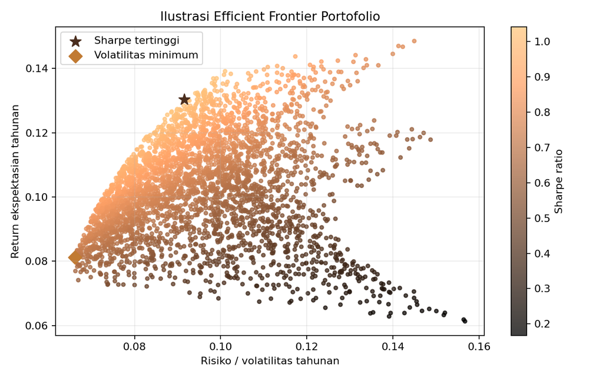

Gambar efficient frontier membantu mahasiswa memahami bahwa portofolio bukan sekadar daftar aset, melainkan kombinasi bobot yang menghasilkan pasangan return-risiko tertentu. Titik dengan Sharpe ratio tinggi belum tentu cocok untuk semua investor, tetapi menjadi kandidat penting ketika aset bebas risiko digunakan sebagai pembanding.

## 12.2 Payoff opsi

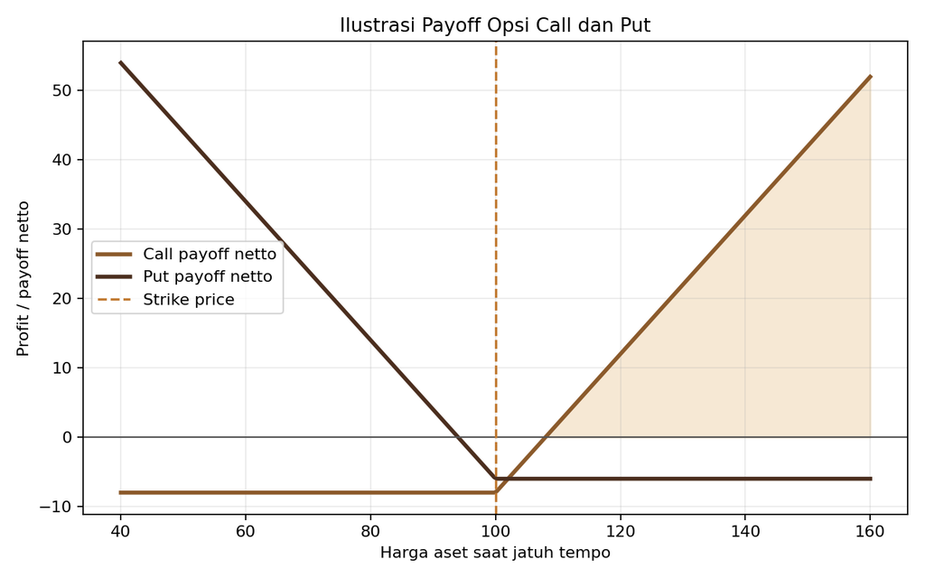

Payoff opsi menunjukkan sifat asimetris kontrak derivatif. Pembeli call memperoleh keuntungan ketika harga aset melampaui strike plus premi, sedangkan pembeli put memperoleh perlindungan ketika harga aset turun di bawah strike dikurangi biaya premi. Bentuk asimetris ini menjelaskan mengapa opsi digunakan untuk hedging dan spekulasi.

## 12.3 Binomial Tree

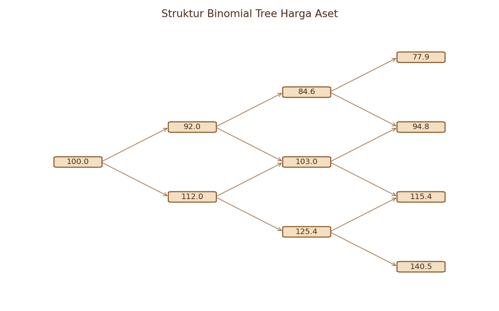

Binomial Tree mengajarkan prinsip backward induction: mulai dari payoff pada jatuh tempo, kemudian bergerak mundur menuju harga awal. Struktur ini sangat baik untuk pembelajaran karena setiap node memiliki makna ekonomi dan komputasi yang eksplisit.

## 12.4 Brownian motion dan jalur harga aset

Agentic AI dengan checkpoint

#### Penerapan pada Brownian motion dan jalur harga aset

**Konteks:** Pertemuan 11: Galeri Ilustrasi Konsep.

Agen dapat menjalankan rangkaian pemeriksaan data–model–diagnostik secara bertahap. Tetapkan checkpoint sebelum perubahan data, pemilihan model, dan penerbitan hasil. **Mahasiswa wajib memeriksa:** ketepatan konsep, asumsi metode, hasil numerik, dan interpretasi substantif. Simpan prompt log ringkas, keluaran awal, perubahan yang dilakukan mahasiswa, sumber pembanding, kode/notebook yang dapat dijalankan ulang, hasil validasi, dan keputusan akhir manusia.

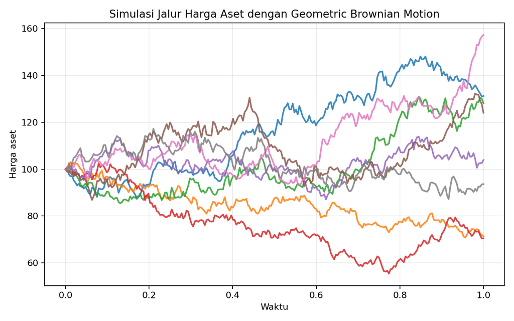

Simulasi jalur harga aset menunjukkan bahwa model stokastik tidak menghasilkan satu masa depan, tetapi distribusi kemungkinan masa depan. Dalam riset harga opsi, cara berpikir distribusional ini jauh lebih penting daripada prediksi titik tunggal.

## 12.5 Sensitivitas harga Black-Scholes

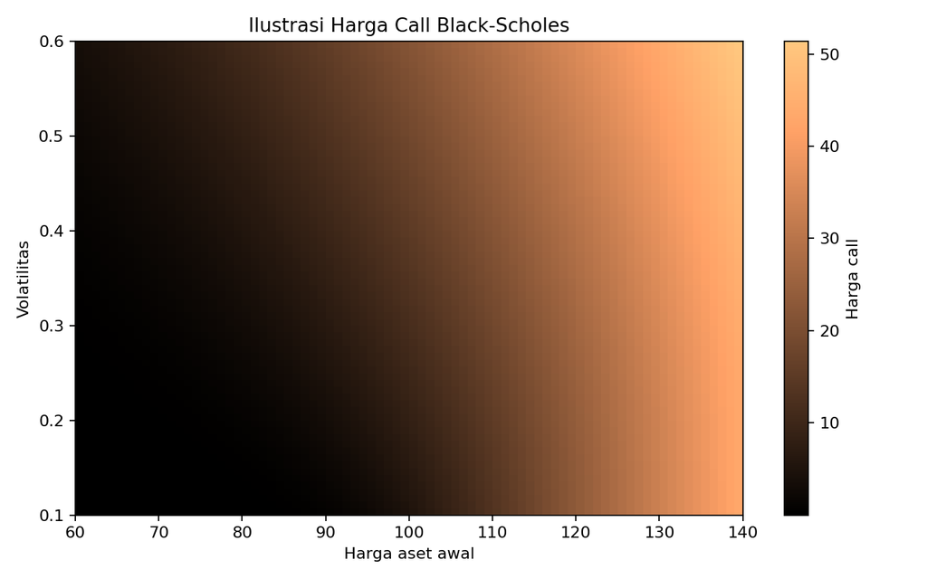

Heatmap Black-Scholes memperlihatkan bagaimana harga call berubah terhadap harga aset awal dan volatilitas. Semakin tinggi harga aset awal dan volatilitas, semakin tinggi nilai call, dengan catatan parameter lain tetap.

# 13 Evaluasi Kinerja Portofolio dan Komunikasi Keputusan Investasi

Integrasi AI pada Bab 12

### Generative dan Agentic AI untuk Evaluasi Kinerja Portofolio dan Komunikasi Keputusan Investasi

**Arah RPS.** Stress testing, backtesting, uncertainty, model risk management, interpretabilitas, dan konsekuensi keputusan finansial.

| Komponen | Implementasi pada bab ini |
| --- | --- |
| Target pembelajaran | Mendukung CPMK3 melalui fokus: Proses Stokastik dalam Keuangan; Brownian motion dan random walk; Brownian motion dengan drift; Proses Ito dan Ito Lemma. |
| Generative AI | Digunakan untuk menghasilkan beberapa skenario pemangku kepentingan dan draf narasi yang kemudian diperiksa terhadap hasil analisis. |
| Agentic AI | Dapat merakit tabel, grafik, pemeriksaan konsistensi, dan daftar klaim–bukti sebelum laporan disetujui manusia; agen wajib berhenti pada checkpoint dosen/mahasiswa. |
| Human checkpoint | Mahasiswa memeriksa kesesuaian klaim dengan bukti, ketidakpastian, keterbatasan, fairness, dan dampak keputusan; keluaran AI tidak diterima sebagai bukti kebenaran. |
| Artefak wajib | prompt log ringkas, keluaran awal, perubahan yang dilakukan mahasiswa, sumber pembanding, kode/notebook yang dapat dijalankan ulang, hasil validasi, dan keputusan akhir manusia. |

**Batas penggunaan.** AI tidak boleh mengerjakan asesmen tertutup, menetapkan kesimpulan akhir, atau menerima/mengirim data sensitif ke layanan yang tidak disetujui. Mahasiswa wajib mampu mengulang dan menjelaskan analisis tanpa bergantung pada percakapan AI.

**Tujuan bab.** Mahasiswa mampu mengevaluasi performa portofolio menggunakan return, volatilitas, Sharpe ratio, drawdown, serta narasi rekomendasi alokasi aset.

## 13.1 Konteks dan ide utama

Portofolio yang optimal secara teori belum tentu optimal secara praktik. Evaluasi kinerja diperlukan untuk melihat stabilitas hasil, risiko penurunan nilai, dan konsistensi kinerja terhadap benchmark. Dalam matematika keuangan, topik ini penting karena menghubungkan konsep abstrak dengan keputusan yang benar-benar dihadapi investor, analis risiko, manajer portofolio, dan pengembang produk derivatif. Mahasiswa S2 Statistika Terapan perlu memandang evaluasi portofolio bukan sekadar sebagai istilah keuangan, tetapi sebagai objek analisis statistik: ada data, ada ketidakpastian, ada model, ada parameter, ada estimasi, dan ada keputusan.

Literatur investasi modern menekankan bahwa keputusan keuangan selalu melibatkan trade-off antara return dan risiko (Bodie, Kane, dan Marcus 2021). Pada saat yang sama, pemodelan derivatif dan risiko pasar membutuhkan pemahaman probabilitas, simulasi, dan proses stokastik (Hull 2022; Shreve 2004). Karena itu, bagian ini selalu dibaca dengan dua kacamata: kacamata ekonomi-keuangan untuk memahami makna keputusan, dan kacamata statistika-komputasi untuk memahami bagaimana angka dihasilkan. Rujukan utama bagian ini antara lain (Bodie, Kane, dan Marcus 2021); (Meucci 2005).

Dalam analisis keuangan, nilai numerik sebaiknya tidak diperlakukan sebagai jawaban final, melainkan sebagai titik awal interpretasi. Return tinggi dapat menarik, tetapi tanpa pemahaman volatilitas, korelasi, drawdown, likuiditas, dan horizon investasi, keputusan akan menjadi rapuh. Inilah alasan pendekatan statistika sangat penting: statistika membantu membedakan sinyal dari kebisingan, pola dari kebetulan, dan risiko terukur dari ketidakpastian yang belum dipahami.

Setiap model membawa asumsi. Pada tahap pembelajaran, asumsi sering tampak sebagai syarat teknis; pada praktik profesional, asumsi berubah menjadi sumber risiko model. Asumsi normalitas return, kestasioneran volatilitas, independensi residual, atau tidak adanya biaya transaksi dapat memudahkan perhitungan, tetapi hasilnya perlu diuji dengan data dan dibaca secara kritis.

Kekuatan mata kuliah ini terletak pada integrasi teori, komputasi, dan komunikasi. Mahasiswa diharapkan mampu menulis kode yang benar, tetapi juga mampu menjelaskan keluaran kode tersebut. Grafik, tabel, dan angka ringkasan perlu diterjemahkan menjadi narasi keputusan: apakah portofolio terlalu terkonsentrasi, apakah VaR terlalu optimistis, apakah opsi terlihat mahal atau murah, dan apakah model masih sesuai dengan kondisi pasar.

Dalam kelas S2, pembahasan tidak cukup berhenti pada contoh sederhana. Contoh sederhana tetap penting untuk membangun intuisi, tetapi setelah itu mahasiswa perlu bertanya: bagaimana jika data tidak normal, bagaimana jika return memiliki ekor tebal, bagaimana jika korelasi berubah saat krisis, bagaimana jika volatilitas naik tiba-tiba, dan bagaimana jika pembatasan investasi membuat solusi optimal secara matematis tidak realistis secara kebijakan.

Secara praktis, evaluasi portofolio sering menuntut keputusan yang tidak sepenuhnya pasti. Misalnya, ketika analis memilih instrumen investasi, ia tidak mengetahui harga masa depan; ketika menghitung VaR, ia tidak mengetahui kerugian esok hari; ketika memilih bobot portofolio, ia tidak mengetahui return aktual; dan ketika menentukan harga opsi, ia tidak mengetahui lintasan harga aset hingga jatuh tempo. Model berperan sebagai peta, bukan wilayah itu sendiri. Peta yang baik membantu perjalanan, tetapi peta tetap perlu dibandingkan dengan medan sebenarnya. Dalam bahasa keuangan: model harus berguna, tetapi pengguna model tidak boleh jatuh cinta terlalu dalam pada modelnya. Model itu partner kerja, bukan jodoh abadi.

Dalam pembelajaran, kita memisahkan tiga lapis pemahaman. Lapis pertama adalah definisi dan formula. Lapis kedua adalah algoritma komputasi. Lapis ketiga adalah interpretasi dan evaluasi model. Banyak kesalahan mahasiswa terjadi ketika hanya menguasai lapis pertama, tetapi tidak memahami lapis kedua dan ketiga. Sebaliknya, banyak kesalahan praktisi terjadi ketika kode berjalan lancar, tetapi asumsi model tidak dibaca. Oleh karena itu, setiap pembahasan dalam bab ini akan diarahkan pada pemahaman konseptual, prosedural, dan kritis.

## 13.2 Definisi, notasi, dan formula inti

### 13.2.1 Formula yang perlu dikuasai

$$\text{Sharpe} = \frac{\bar{R}_p - R_f}{\sigma_p}$$

$$\text{Maximum Drawdown}=\max_{t}\left(\frac{\max_{s\le t}V_s -
V_t}{\max_{s\le t}V_s}\right)$$

$$\text{Information Ratio}=\frac{\bar{R}_p-\bar{R}_b}{\sigma(R_p-R_b)}$$

Formula di atas harus dibaca bersama konteksnya. Simbol yang sama dapat memiliki arti berbeda dalam topik berbeda. Misalnya, $r$ dapat berarti tingkat bunga bebas risiko, return diskrit, atau log-return tergantung model. Demikian pula $\sigma$ dapat berarti volatilitas historis, volatilitas implisit, atau parameter difusi pada proses stokastik. Dalam laporan akademik, notasi harus ditulis konsisten sejak awal. Ketidakkonsistenan notasi sering membuat pembaca merasa seperti membaca peta harta karun, tetapi petanya digambar oleh tiga bajak laut yang tidak saling bicara.

Pada level komputasi, formula harus diterjemahkan menjadi langkah yang dapat diuji. Setiap variabel harus berasal dari data atau asumsi yang eksplisit. Jika menggunakan data harga, jelaskan apakah return yang dihitung adalah return sederhana atau log-return. Jika menggunakan volatilitas, jelaskan apakah volatilitas diannualisasi. Jika menggunakan tingkat bunga, jelaskan apakah bunga dinyatakan dalam compounding diskrit atau kontinu. Detail seperti ini terlihat kecil, tetapi dapat mengubah hasil secara substansial.

## 13.3 Contoh kasus terarah: presentasi portofolio dan alokasi aset pada pertemuan UTS

AI untuk aplikasi dan komunikasi

#### Penerapan pada Contoh kasus terarah: presentasi portofolio dan alokasi aset pada pertemuan UTS

**Konteks:** Pertemuan 12: Evaluasi Kinerja Portofolio dan Komunikasi Keputusan Investasi.

Terapkan arahan RPS berikut pada kasus bab ini: Stress testing, backtesting, uncertainty, model risk management, interpretabilitas, dan konsekuensi keputusan finansial. Generative AI dapat menghasilkan beberapa skenario pemangku kepentingan dan draf narasi yang kemudian diperiksa terhadap hasil analisis; Agentic AI dapat merakit tabel, grafik, pemeriksaan konsistensi, dan daftar klaim–bukti sebelum laporan disetujui manusia. Checkpoint manusia mencakup kesesuaian klaim dengan bukti, ketidakpastian, keterbatasan, fairness, dan dampak keputusan. Semua klaim harus ditautkan ke output, ketidakpastian, dan sumber yang dapat diperiksa.

Bayangkan seorang analis pada institusi keuangan ingin menggunakan evaluasi portofolio untuk membantu keputusan alokasi dana. Data yang tersedia berupa harga historis beberapa instrumen, informasi tingkat bunga bebas risiko, dan batasan kebijakan investasi. Tujuan analis bukan hanya menghitung angka, melainkan menyusun argumen yang dapat dipertanggungjawabkan: instrumen mana yang dipilih, risiko mana yang dominan, asumsi mana yang digunakan, hasil mana yang stabil, dan rekomendasi apa yang masuk akal.

Langkah pertama adalah melakukan pemeriksaan data. Periksa missing value, outlier, perubahan denominasi, corporate action, serta konsistensi frekuensi data. Dalam data keuangan, kesalahan kecil pada data harga dapat menghasilkan return ekstrem yang bukan risiko pasar, melainkan risiko spreadsheet. Langkah kedua adalah menghitung ringkasan statistik: mean, median, standar deviasi, quantile, skewness, kurtosis, korelasi, dan grafik time series. Langkah ketiga adalah menerapkan model sesuai tujuan analisis. Langkah keempat adalah mengevaluasi kewajaran output model dan menulis interpretasi.

Pada laporan mahasiswa, contoh kasus sebaiknya tidak berhenti pada angka final. Misalnya, jika hasil menunjukkan bahwa suatu aset memiliki volatilitas tinggi, jelaskan apakah volatilitas itu konsisten dengan karakter aset tersebut. Jika hasil menunjukkan korelasi negatif antara dua aset, jelaskan implikasinya untuk diversifikasi. Jika hasil opsi menunjukkan harga model lebih rendah dari harga pasar, diskusikan kemungkinan adanya perbedaan volatilitas implisit, biaya transaksi, likuiditas, atau asumsi model.

## 13.4 Implementasi awal di R

Agentic AI dengan checkpoint

#### Penerapan pada Implementasi awal di R

**Konteks:** Pertemuan 12: Evaluasi Kinerja Portofolio dan Komunikasi Keputusan Investasi.

Agen dapat merakit tabel, grafik, pemeriksaan konsistensi, dan daftar klaim–bukti sebelum laporan disetujui manusia. Tetapkan checkpoint sebelum perubahan data, pemilihan model, dan penerbitan hasil. **Mahasiswa wajib memeriksa:** kesesuaian klaim dengan bukti, ketidakpastian, keterbatasan, fairness, dan dampak keputusan. Simpan prompt log ringkas, keluaran awal, perubahan yang dilakukan mahasiswa, sumber pembanding, kode/notebook yang dapat dijalankan ulang, hasil validasi, dan keputusan akhir manusia.

```r
# Fungsi maximum drawdown sederhana
max_drawdown <- function(returns) {
  value <- cumprod(1 + returns)
  peak <- cummax(value)
  drawdown <- (peak - value) / peak
  max(drawdown)
}
set.seed(77)
rp <- rnorm(252, 0.0005, 0.012)
c(mean_return = mean(rp), volatility = sd(rp), max_drawdown = max_drawdown(rp))
```

Kode di atas bersifat kerangka awal. Dalam praktikum, mahasiswa perlu menyesuaikan kode dengan data riil, nama kolom, frekuensi data, dan tujuan analisis. Dosen dapat meminta mahasiswa menjalankan kode secara bertahap: mulai dari import data, pembersihan, transformasi return, estimasi parameter, visualisasi, hingga penyusunan output. Pendekatan bertahap ini membantu menghindari kesalahan umum ketika mahasiswa langsung menyalin kode panjang tanpa memahami fungsi setiap baris.

## 13.5 Interpretasi, validasi, dan jebakan umum

Validasi dalam evaluasi portofolio mencakup validasi matematis dan validasi empiris. Validasi matematis berarti memeriksa apakah formula, batasan, dan algoritma sudah benar. Validasi empiris berarti memeriksa apakah output masuk akal terhadap data dan konteks pasar. Dalam kasus VaR, validasi empiris dapat berupa backtesting jumlah pelanggaran. Dalam kasus portofolio, validasi dapat berupa uji sensitivitas terhadap estimasi mean dan kovarians. Dalam kasus opsi, validasi dapat berupa pembandingan harga model dengan harga pasar atau dengan model lain.

Jebakan pertama adalah memperlakukan data historis sebagai masa depan yang pasti. Data historis penting, tetapi pasar bisa berubah. Jebakan kedua adalah mengabaikan horizon waktu. Risiko satu hari tidak sama dengan risiko satu bulan, dan volatilitas harian tidak boleh dicampur dengan return bulanan tanpa annualization yang benar. Jebakan ketiga adalah menganggap optimasi selalu menghasilkan jawaban yang stabil. Pada portofolio mean-variance, bobot optimal dapat berubah drastis ketika estimasi mean sedikit berubah. Jebakan keempat adalah menafsirkan hasil model tanpa mempertimbangkan biaya transaksi, likuiditas, pajak, dan batasan institusional.

Dari sisi penulisan akademik, interpretasi yang baik memiliki tiga komponen: angka, makna, dan konsekuensi. Angka menunjukkan hasil. Makna menjelaskan apa arti hasil itu dalam bahasa statistik dan keuangan. Konsekuensi menjelaskan implikasi keputusan. Contoh interpretasi yang lemah adalah: “VaR sebesar 2%.” Contoh yang lebih kuat adalah: “Pada tingkat keyakinan 95%, estimasi VaR harian portofolio sebesar 2% menunjukkan bahwa dalam kondisi historis yang digunakan, kerugian harian diperkirakan tidak melebihi 2% pada sekitar 95 dari 100 hari; namun hasil ini sensitif terhadap periode data dan tidak menangkap risiko ekor ekstrem secara sempurna.”

## 13.6 Latihan dan diskusi

Aturan AI untuk latihan dan asesmen

#### Penerapan pada Latihan dan diskusi

**Konteks:** Pertemuan 12: Evaluasi Kinerja Portofolio dan Komunikasi Keputusan Investasi.

Ikuti status asesmen yang ditetapkan dosen: tanpa AI, AI terbatas, atau AI terbuka. Jika diizinkan, AI hanya memberi kritik, pertanyaan tandingan, atau pemeriksaan awal; jawaban, keputusan metode, dan pembelaan lisan tetap karya mahasiswa. Bukti yang diserahkan: prompt log ringkas, keluaran awal, perubahan yang dilakukan mahasiswa, sumber pembanding, kode/notebook yang dapat dijalankan ulang, hasil validasi, dan keputusan akhir manusia.

1. Hitung Sharpe ratio, volatilitas, dan maximum drawdown untuk satu portofolio.
2. Buat dashboard ringkas evaluasi portofolio.
3. Tuliskan rekomendasi investasi maksimal 250 kata berdasarkan hasil analisis.

Untuk diskusi kelas, mahasiswa dapat diminta membandingkan jawaban antar-kelompok. Perbedaan hasil bukan selalu berarti ada kelompok yang salah. Dalam analisis keuangan, hasil dapat berbeda karena pilihan periode data, frekuensi return, metode estimasi volatilitas, asumsi risk-free rate, atau batasan optimasi. Yang penting adalah setiap pilihan metodologis dijelaskan secara transparan dan konsisten.

# 14 Teori Opsi: Call, Put, Eropa, Amerika, Nilai Intrinsik, dan Payoff

Integrasi AI pada Bab 13

### Generative dan Agentic AI untuk Teori Opsi: Call, Put, Eropa, Amerika, Nilai Intrinsik, dan Payoff

**Arah RPS.** Studi kasus menggunakan data pasar nyata dengan dokumentasi asumsi, keterbatasan, dan risiko penggunaan otomatisasi.

| Komponen | Implementasi pada bab ini |
| --- | --- |
| Target pembelajaran | Mendukung CPMK4 melalui fokus: Pemodelan stokastik harga aset keuangan; Model Black-Scholes; Turunan rumus Black-Scholes untuk opsi Eropa (call dan put). |
| Generative AI | Digunakan untuk membandingkan kandidat model, menuliskan alasan pemilihan, dan mengusulkan diagnostik. |
| Agentic AI | Dapat memasang kandidat model, menjalankan diagnostik, membandingkan metrik, dan menghentikan proses pada kegagalan asumsi atau konvergensi; agen wajib berhenti pada checkpoint dosen/mahasiswa. |
| Human checkpoint | Mahasiswa memeriksa spesifikasi model, data leakage, konvergensi, residual, kalibrasi, ketidakpastian, dan overfitting; keluaran AI tidak diterima sebagai bukti kebenaran. |
| Artefak wajib | prompt log ringkas, keluaran awal, perubahan yang dilakukan mahasiswa, sumber pembanding, kode/notebook yang dapat dijalankan ulang, hasil validasi, dan keputusan akhir manusia. |

**Batas penggunaan.** AI tidak boleh mengerjakan asesmen tertutup, menetapkan kesimpulan akhir, atau menerima/mengirim data sensitif ke layanan yang tidak disetujui. Mahasiswa wajib mampu mengulang dan menjelaskan analisis tanpa bergantung pada percakapan AI.

**Tujuan bab.** Mahasiswa mampu menjelaskan definisi opsi call dan put, perbedaan opsi Eropa dan Amerika, nilai intrinsik, nilai waktu, serta bentuk payoff.

## 14.1 Konteks dan ide utama

Opsi adalah kontrak derivatif yang memberikan hak, bukan kewajiban, kepada pemegangnya. Opsi call memberi hak membeli aset dasar pada harga strike, sedangkan opsi put memberi hak menjual aset dasar pada harga strike. Dalam matematika keuangan, topik ini penting karena menghubungkan konsep abstrak dengan keputusan yang benar-benar dihadapi investor, analis risiko, manajer portofolio, dan pengembang produk derivatif. Mahasiswa S2 Statistika Terapan perlu memandang teori opsi bukan sekadar sebagai istilah keuangan, tetapi sebagai objek analisis statistik: ada data, ada ketidakpastian, ada model, ada parameter, ada estimasi, dan ada keputusan.

Literatur investasi modern menekankan bahwa keputusan keuangan selalu melibatkan trade-off antara return dan risiko (Bodie, Kane, dan Marcus 2021). Pada saat yang sama, pemodelan derivatif dan risiko pasar membutuhkan pemahaman probabilitas, simulasi, dan proses stokastik (Hull 2022; Shreve 2004). Karena itu, bagian ini selalu dibaca dengan dua kacamata: kacamata ekonomi-keuangan untuk memahami makna keputusan, dan kacamata statistika-komputasi untuk memahami bagaimana angka dihasilkan. Rujukan utama bagian ini antara lain (Hull 2022); (Cox, Ross, dan Rubinstein 1979).

Dalam analisis keuangan, nilai numerik sebaiknya tidak diperlakukan sebagai jawaban final, melainkan sebagai titik awal interpretasi. Return tinggi dapat menarik, tetapi tanpa pemahaman volatilitas, korelasi, drawdown, likuiditas, dan horizon investasi, keputusan akan menjadi rapuh. Inilah alasan pendekatan statistika sangat penting: statistika membantu membedakan sinyal dari kebisingan, pola dari kebetulan, dan risiko terukur dari ketidakpastian yang belum dipahami.

Setiap model membawa asumsi. Pada tahap pembelajaran, asumsi sering tampak sebagai syarat teknis; pada praktik profesional, asumsi berubah menjadi sumber risiko model. Asumsi normalitas return, kestasioneran volatilitas, independensi residual, atau tidak adanya biaya transaksi dapat memudahkan perhitungan, tetapi hasilnya perlu diuji dengan data dan dibaca secara kritis.

Kekuatan mata kuliah ini terletak pada integrasi teori, komputasi, dan komunikasi. Mahasiswa diharapkan mampu menulis kode yang benar, tetapi juga mampu menjelaskan keluaran kode tersebut. Grafik, tabel, dan angka ringkasan perlu diterjemahkan menjadi narasi keputusan: apakah portofolio terlalu terkonsentrasi, apakah VaR terlalu optimistis, apakah opsi terlihat mahal atau murah, dan apakah model masih sesuai dengan kondisi pasar.

Dalam kelas S2, pembahasan tidak cukup berhenti pada contoh sederhana. Contoh sederhana tetap penting untuk membangun intuisi, tetapi setelah itu mahasiswa perlu bertanya: bagaimana jika data tidak normal, bagaimana jika return memiliki ekor tebal, bagaimana jika korelasi berubah saat krisis, bagaimana jika volatilitas naik tiba-tiba, dan bagaimana jika pembatasan investasi membuat solusi optimal secara matematis tidak realistis secara kebijakan.

Secara praktis, teori opsi sering menuntut keputusan yang tidak sepenuhnya pasti. Misalnya, ketika analis memilih instrumen investasi, ia tidak mengetahui harga masa depan; ketika menghitung VaR, ia tidak mengetahui kerugian esok hari; ketika memilih bobot portofolio, ia tidak mengetahui return aktual; dan ketika menentukan harga opsi, ia tidak mengetahui lintasan harga aset hingga jatuh tempo. Model berperan sebagai peta, bukan wilayah itu sendiri. Peta yang baik membantu perjalanan, tetapi peta tetap perlu dibandingkan dengan medan sebenarnya. Dalam bahasa keuangan: model harus berguna, tetapi pengguna model tidak boleh jatuh cinta terlalu dalam pada modelnya. Model itu partner kerja, bukan jodoh abadi.

Dalam pembelajaran, kita memisahkan tiga lapis pemahaman. Lapis pertama adalah definisi dan formula. Lapis kedua adalah algoritma komputasi. Lapis ketiga adalah interpretasi dan evaluasi model. Banyak kesalahan mahasiswa terjadi ketika hanya menguasai lapis pertama, tetapi tidak memahami lapis kedua dan ketiga. Sebaliknya, banyak kesalahan praktisi terjadi ketika kode berjalan lancar, tetapi asumsi model tidak dibaca. Oleh karena itu, setiap pembahasan dalam bab ini akan diarahkan pada pemahaman konseptual, prosedural, dan kritis.

## 14.2 Definisi, notasi, dan formula inti

### 14.2.1 Formula yang perlu dikuasai

$$C_T=\max(S_T-K,0)$$

$$P_T=\max(K-S_T,0)$$

$$\text{Nilai opsi}=\text{nilai intrinsik}+\text{nilai waktu}$$

Formula di atas harus dibaca bersama konteksnya. Simbol yang sama dapat memiliki arti berbeda dalam topik berbeda. Misalnya, $r$ dapat berarti tingkat bunga bebas risiko, return diskrit, atau log-return tergantung model. Demikian pula $\sigma$ dapat berarti volatilitas historis, volatilitas implisit, atau parameter difusi pada proses stokastik. Dalam laporan akademik, notasi harus ditulis konsisten sejak awal. Ketidakkonsistenan notasi sering membuat pembaca merasa seperti membaca peta harta karun, tetapi petanya digambar oleh tiga bajak laut yang tidak saling bicara.

Pada level komputasi, formula harus diterjemahkan menjadi langkah yang dapat diuji. Setiap variabel harus berasal dari data atau asumsi yang eksplisit. Jika menggunakan data harga, jelaskan apakah return yang dihitung adalah return sederhana atau log-return. Jika menggunakan volatilitas, jelaskan apakah volatilitas diannualisasi. Jika menggunakan tingkat bunga, jelaskan apakah bunga dinyatakan dalam compounding diskrit atau kontinu. Detail seperti ini terlihat kecil, tetapi dapat mengubah hasil secara substansial.

## 14.3 Contoh kasus terarah: analisis payoff opsi pada saham dengan beberapa skenario harga jatuh tempo

AI untuk aplikasi dan komunikasi

#### Penerapan pada Contoh kasus terarah: analisis payoff opsi pada saham dengan beberapa skenario harga jatuh tempo

**Konteks:** Pertemuan 13: Teori Opsi: Call, Put, Eropa, Amerika, Nilai Intrinsik, dan Payoff.

Terapkan arahan RPS berikut pada kasus bab ini: Studi kasus menggunakan data pasar nyata dengan dokumentasi asumsi, keterbatasan, dan risiko penggunaan otomatisasi. Generative AI dapat menghasilkan beberapa skenario pemangku kepentingan dan draf narasi yang kemudian diperiksa terhadap hasil analisis; Agentic AI dapat merakit tabel, grafik, pemeriksaan konsistensi, dan daftar klaim–bukti sebelum laporan disetujui manusia. Checkpoint manusia mencakup kesesuaian klaim dengan bukti, ketidakpastian, keterbatasan, fairness, dan dampak keputusan. Semua klaim harus ditautkan ke output, ketidakpastian, dan sumber yang dapat diperiksa.

Bayangkan seorang analis pada institusi keuangan ingin menggunakan teori opsi untuk membantu keputusan alokasi dana. Data yang tersedia berupa harga historis beberapa instrumen, informasi tingkat bunga bebas risiko, dan batasan kebijakan investasi. Tujuan analis bukan hanya menghitung angka, melainkan menyusun argumen yang dapat dipertanggungjawabkan: instrumen mana yang dipilih, risiko mana yang dominan, asumsi mana yang digunakan, hasil mana yang stabil, dan rekomendasi apa yang masuk akal.

Langkah pertama adalah melakukan pemeriksaan data. Periksa missing value, outlier, perubahan denominasi, corporate action, serta konsistensi frekuensi data. Dalam data keuangan, kesalahan kecil pada data harga dapat menghasilkan return ekstrem yang bukan risiko pasar, melainkan risiko spreadsheet. Langkah kedua adalah menghitung ringkasan statistik: mean, median, standar deviasi, quantile, skewness, kurtosis, korelasi, dan grafik time series. Langkah ketiga adalah menerapkan model sesuai tujuan analisis. Langkah keempat adalah mengevaluasi kewajaran output model dan menulis interpretasi.

Pada laporan mahasiswa, contoh kasus sebaiknya tidak berhenti pada angka final. Misalnya, jika hasil menunjukkan bahwa suatu aset memiliki volatilitas tinggi, jelaskan apakah volatilitas itu konsisten dengan karakter aset tersebut. Jika hasil menunjukkan korelasi negatif antara dua aset, jelaskan implikasinya untuk diversifikasi. Jika hasil opsi menunjukkan harga model lebih rendah dari harga pasar, diskusikan kemungkinan adanya perbedaan volatilitas implisit, biaya transaksi, likuiditas, atau asumsi model.

## 14.4 Implementasi awal di R

Agentic AI dengan checkpoint

#### Penerapan pada Implementasi awal di R

**Konteks:** Pertemuan 13: Teori Opsi: Call, Put, Eropa, Amerika, Nilai Intrinsik, dan Payoff.

Agen dapat menjalankan rangkaian pemeriksaan data–model–diagnostik secara bertahap. Tetapkan checkpoint sebelum perubahan data, pemilihan model, dan penerbitan hasil. **Mahasiswa wajib memeriksa:** ketepatan konsep, asumsi metode, hasil numerik, dan interpretasi substantif. Simpan prompt log ringkas, keluaran awal, perubahan yang dilakukan mahasiswa, sumber pembanding, kode/notebook yang dapat dijalankan ulang, hasil validasi, dan keputusan akhir manusia.

```r
# Payoff opsi call dan put
S <- seq(50, 150, by = 1)
K <- 100
call_payoff <- pmax(S - K, 0)
put_payoff <- pmax(K - S, 0)
plot(S, call_payoff, type = "l", lwd = 2, col = "brown",
     xlab = "Harga aset saat jatuh tempo", ylab = "Payoff")
lines(S, put_payoff, lwd = 2, col = "darkorange")
legend("topleft", legend = c("Call", "Put"), lwd = 2,
       col = c("brown", "darkorange"))
```

Kode di atas bersifat kerangka awal. Dalam praktikum, mahasiswa perlu menyesuaikan kode dengan data riil, nama kolom, frekuensi data, dan tujuan analisis. Dosen dapat meminta mahasiswa menjalankan kode secara bertahap: mulai dari import data, pembersihan, transformasi return, estimasi parameter, visualisasi, hingga penyusunan output. Pendekatan bertahap ini membantu menghindari kesalahan umum ketika mahasiswa langsung menyalin kode panjang tanpa memahami fungsi setiap baris.

## 14.5 Interpretasi, validasi, dan jebakan umum

Validasi dalam teori opsi mencakup validasi matematis dan validasi empiris. Validasi matematis berarti memeriksa apakah formula, batasan, dan algoritma sudah benar. Validasi empiris berarti memeriksa apakah output masuk akal terhadap data dan konteks pasar. Dalam kasus VaR, validasi empiris dapat berupa backtesting jumlah pelanggaran. Dalam kasus portofolio, validasi dapat berupa uji sensitivitas terhadap estimasi mean dan kovarians. Dalam kasus opsi, validasi dapat berupa pembandingan harga model dengan harga pasar atau dengan model lain.

Jebakan pertama adalah memperlakukan data historis sebagai masa depan yang pasti. Data historis penting, tetapi pasar bisa berubah. Jebakan kedua adalah mengabaikan horizon waktu. Risiko satu hari tidak sama dengan risiko satu bulan, dan volatilitas harian tidak boleh dicampur dengan return bulanan tanpa annualization yang benar. Jebakan ketiga adalah menganggap optimasi selalu menghasilkan jawaban yang stabil. Pada portofolio mean-variance, bobot optimal dapat berubah drastis ketika estimasi mean sedikit berubah. Jebakan keempat adalah menafsirkan hasil model tanpa mempertimbangkan biaya transaksi, likuiditas, pajak, dan batasan institusional.

Dari sisi penulisan akademik, interpretasi yang baik memiliki tiga komponen: angka, makna, dan konsekuensi. Angka menunjukkan hasil. Makna menjelaskan apa arti hasil itu dalam bahasa statistik dan keuangan. Konsekuensi menjelaskan implikasi keputusan. Contoh interpretasi yang lemah adalah: “VaR sebesar 2%.” Contoh yang lebih kuat adalah: “Pada tingkat keyakinan 95%, estimasi VaR harian portofolio sebesar 2% menunjukkan bahwa dalam kondisi historis yang digunakan, kerugian harian diperkirakan tidak melebihi 2% pada sekitar 95 dari 100 hari; namun hasil ini sensitif terhadap periode data dan tidak menangkap risiko ekor ekstrem secara sempurna.”

## 14.6 Latihan dan diskusi

Aturan AI untuk latihan dan asesmen

#### Penerapan pada Latihan dan diskusi

**Konteks:** Pertemuan 13: Teori Opsi: Call, Put, Eropa, Amerika, Nilai Intrinsik, dan Payoff.

Ikuti status asesmen yang ditetapkan dosen: tanpa AI, AI terbatas, atau AI terbuka. Jika diizinkan, AI hanya memberi kritik, pertanyaan tandingan, atau pemeriksaan awal; jawaban, keputusan metode, dan pembelaan lisan tetap karya mahasiswa. Bukti yang diserahkan: prompt log ringkas, keluaran awal, perubahan yang dilakukan mahasiswa, sumber pembanding, kode/notebook yang dapat dijalankan ulang, hasil validasi, dan keputusan akhir manusia.

1. Gambarkan payoff call dan put untuk tiga nilai strike berbeda.
2. Jelaskan perbedaan hak dan kewajiban pembeli opsi dan penjual opsi.
3. Diskusikan mengapa opsi Amerika tidak lebih murah dari opsi Eropa yang sebanding.

Untuk diskusi kelas, mahasiswa dapat diminta membandingkan jawaban antar-kelompok. Perbedaan hasil bukan selalu berarti ada kelompok yang salah. Dalam analisis keuangan, hasil dapat berbeda karena pilihan periode data, frekuensi return, metode estimasi volatilitas, asumsi risk-free rate, atau batasan optimasi. Yang penting adalah setiap pilihan metodologis dijelaskan secara transparan dan konsisten.

# 15 Put-Call Parity dan Strategi Defensif serta Spekulatif

Integrasi AI pada Bab 14

### Generative dan Agentic AI untuk Put-Call Parity dan Strategi Defensif serta Spekulatif

**Arah RPS.** AI untuk forecasting, pricing, portfolio analytics, dan deteksi anomali dengan pembanding model matematis/statistik.

| Komponen | Implementasi pada bab ini |
| --- | --- |
| Target pembelajaran | Mendukung CPMK4 melalui fokus: Aplikasi dan evaluasi model Black-Scholes; Pengembangan model inovatif untuk harga opsi; Studi Kasus dan Inovasi dalam Matematika Keuangan. |
| Generative AI | Digunakan untuk menghasilkan beberapa skenario pemangku kepentingan dan draf narasi yang kemudian diperiksa terhadap hasil analisis. |
| Agentic AI | Dapat merakit tabel, grafik, pemeriksaan konsistensi, dan daftar klaim–bukti sebelum laporan disetujui manusia; agen wajib berhenti pada checkpoint dosen/mahasiswa. |
| Human checkpoint | Mahasiswa memeriksa kesesuaian klaim dengan bukti, ketidakpastian, keterbatasan, fairness, dan dampak keputusan; keluaran AI tidak diterima sebagai bukti kebenaran. |
| Artefak wajib | prompt log ringkas, keluaran awal, perubahan yang dilakukan mahasiswa, sumber pembanding, kode/notebook yang dapat dijalankan ulang, hasil validasi, dan keputusan akhir manusia. |

**Batas penggunaan.** AI tidak boleh mengerjakan asesmen tertutup, menetapkan kesimpulan akhir, atau menerima/mengirim data sensitif ke layanan yang tidak disetujui. Mahasiswa wajib mampu mengulang dan menjelaskan analisis tanpa bergantung pada percakapan AI.

**Tujuan bab.** Mahasiswa mampu menggunakan put-call parity untuk memeriksa konsistensi harga opsi dan memahami strategi protective put, covered call, straddle, dan spread.

## 15.1 Konteks dan ide utama

Put-call parity adalah relasi fundamental antara harga call, put, aset dasar, dan obligasi bebas risiko untuk opsi Eropa tanpa dividen. Relasi ini penting karena menunjukkan bagaimana kombinasi instrumen dapat mereplikasi payoff instrumen lain. Dalam matematika keuangan, topik ini penting karena menghubungkan konsep abstrak dengan keputusan yang benar-benar dihadapi investor, analis risiko, manajer portofolio, dan pengembang produk derivatif. Mahasiswa S2 Statistika Terapan perlu memandang put-call parity dan strategi opsi bukan sekadar sebagai istilah keuangan, tetapi sebagai objek analisis statistik: ada data, ada ketidakpastian, ada model, ada parameter, ada estimasi, dan ada keputusan.

Literatur investasi modern menekankan bahwa keputusan keuangan selalu melibatkan trade-off antara return dan risiko (Bodie, Kane, dan Marcus 2021). Pada saat yang sama, pemodelan derivatif dan risiko pasar membutuhkan pemahaman probabilitas, simulasi, dan proses stokastik (Hull 2022; Shreve 2004). Karena itu, bagian ini selalu dibaca dengan dua kacamata: kacamata ekonomi-keuangan untuk memahami makna keputusan, dan kacamata statistika-komputasi untuk memahami bagaimana angka dihasilkan. Rujukan utama bagian ini antara lain (Hull 2022); (Black dan Scholes 1973).

Dalam analisis keuangan, nilai numerik sebaiknya tidak diperlakukan sebagai jawaban final, melainkan sebagai titik awal interpretasi. Return tinggi dapat menarik, tetapi tanpa pemahaman volatilitas, korelasi, drawdown, likuiditas, dan horizon investasi, keputusan akan menjadi rapuh. Inilah alasan pendekatan statistika sangat penting: statistika membantu membedakan sinyal dari kebisingan, pola dari kebetulan, dan risiko terukur dari ketidakpastian yang belum dipahami.

Setiap model membawa asumsi. Pada tahap pembelajaran, asumsi sering tampak sebagai syarat teknis; pada praktik profesional, asumsi berubah menjadi sumber risiko model. Asumsi normalitas return, kestasioneran volatilitas, independensi residual, atau tidak adanya biaya transaksi dapat memudahkan perhitungan, tetapi hasilnya perlu diuji dengan data dan dibaca secara kritis.

Kekuatan mata kuliah ini terletak pada integrasi teori, komputasi, dan komunikasi. Mahasiswa diharapkan mampu menulis kode yang benar, tetapi juga mampu menjelaskan keluaran kode tersebut. Grafik, tabel, dan angka ringkasan perlu diterjemahkan menjadi narasi keputusan: apakah portofolio terlalu terkonsentrasi, apakah VaR terlalu optimistis, apakah opsi terlihat mahal atau murah, dan apakah model masih sesuai dengan kondisi pasar.

Dalam kelas S2, pembahasan tidak cukup berhenti pada contoh sederhana. Contoh sederhana tetap penting untuk membangun intuisi, tetapi setelah itu mahasiswa perlu bertanya: bagaimana jika data tidak normal, bagaimana jika return memiliki ekor tebal, bagaimana jika korelasi berubah saat krisis, bagaimana jika volatilitas naik tiba-tiba, dan bagaimana jika pembatasan investasi membuat solusi optimal secara matematis tidak realistis secara kebijakan.

Secara praktis, put-call parity dan strategi opsi sering menuntut keputusan yang tidak sepenuhnya pasti. Misalnya, ketika analis memilih instrumen investasi, ia tidak mengetahui harga masa depan; ketika menghitung VaR, ia tidak mengetahui kerugian esok hari; ketika memilih bobot portofolio, ia tidak mengetahui return aktual; dan ketika menentukan harga opsi, ia tidak mengetahui lintasan harga aset hingga jatuh tempo. Model berperan sebagai peta, bukan wilayah itu sendiri. Peta yang baik membantu perjalanan, tetapi peta tetap perlu dibandingkan dengan medan sebenarnya. Dalam bahasa keuangan: model harus berguna, tetapi pengguna model tidak boleh jatuh cinta terlalu dalam pada modelnya. Model itu partner kerja, bukan jodoh abadi.

Dalam pembelajaran, kita memisahkan tiga lapis pemahaman. Lapis pertama adalah definisi dan formula. Lapis kedua adalah algoritma komputasi. Lapis ketiga adalah interpretasi dan evaluasi model. Banyak kesalahan mahasiswa terjadi ketika hanya menguasai lapis pertama, tetapi tidak memahami lapis kedua dan ketiga. Sebaliknya, banyak kesalahan praktisi terjadi ketika kode berjalan lancar, tetapi asumsi model tidak dibaca. Oleh karena itu, setiap pembahasan dalam bab ini akan diarahkan pada pemahaman konseptual, prosedural, dan kritis.

## 15.2 Definisi, notasi, dan formula inti

### 15.2.1 Formula yang perlu dikuasai

$$C + K e^{-rT} = P + S_0$$

$$P = C + K e^{-rT} - S_0$$

$$\Pi_{\text{protective put}} = S_T + \max(K-S_T,0)$$

Formula di atas harus dibaca bersama konteksnya. Simbol yang sama dapat memiliki arti berbeda dalam topik berbeda. Misalnya, $r$ dapat berarti tingkat bunga bebas risiko, return diskrit, atau log-return tergantung model. Demikian pula $\sigma$ dapat berarti volatilitas historis, volatilitas implisit, atau parameter difusi pada proses stokastik. Dalam laporan akademik, notasi harus ditulis konsisten sejak awal. Ketidakkonsistenan notasi sering membuat pembaca merasa seperti membaca peta harta karun, tetapi petanya digambar oleh tiga bajak laut yang tidak saling bicara.

Pada level komputasi, formula harus diterjemahkan menjadi langkah yang dapat diuji. Setiap variabel harus berasal dari data atau asumsi yang eksplisit. Jika menggunakan data harga, jelaskan apakah return yang dihitung adalah return sederhana atau log-return. Jika menggunakan volatilitas, jelaskan apakah volatilitas diannualisasi. Jika menggunakan tingkat bunga, jelaskan apakah bunga dinyatakan dalam compounding diskrit atau kontinu. Detail seperti ini terlihat kecil, tetapi dapat mengubah hasil secara substansial.

## 15.3 Contoh kasus terarah: menguji kemungkinan arbitrase dari harga call dan put yang diamati di pasar

AI untuk aplikasi dan komunikasi

#### Penerapan pada Contoh kasus terarah: menguji kemungkinan arbitrase dari harga call dan put yang diamati di pasar

**Konteks:** Pertemuan 14: Put-Call Parity dan Strategi Defensif serta Spekulatif.

Terapkan arahan RPS berikut pada kasus bab ini: AI untuk forecasting, pricing, portfolio analytics, dan deteksi anomali dengan pembanding model matematis/statistik. Generative AI dapat menghasilkan beberapa skenario pemangku kepentingan dan draf narasi yang kemudian diperiksa terhadap hasil analisis; Agentic AI dapat merakit tabel, grafik, pemeriksaan konsistensi, dan daftar klaim–bukti sebelum laporan disetujui manusia. Checkpoint manusia mencakup kesesuaian klaim dengan bukti, ketidakpastian, keterbatasan, fairness, dan dampak keputusan. Semua klaim harus ditautkan ke output, ketidakpastian, dan sumber yang dapat diperiksa.

Bayangkan seorang analis pada institusi keuangan ingin menggunakan put-call parity dan strategi opsi untuk membantu keputusan alokasi dana. Data yang tersedia berupa harga historis beberapa instrumen, informasi tingkat bunga bebas risiko, dan batasan kebijakan investasi. Tujuan analis bukan hanya menghitung angka, melainkan menyusun argumen yang dapat dipertanggungjawabkan: instrumen mana yang dipilih, risiko mana yang dominan, asumsi mana yang digunakan, hasil mana yang stabil, dan rekomendasi apa yang masuk akal.

Langkah pertama adalah melakukan pemeriksaan data. Periksa missing value, outlier, perubahan denominasi, corporate action, serta konsistensi frekuensi data. Dalam data keuangan, kesalahan kecil pada data harga dapat menghasilkan return ekstrem yang bukan risiko pasar, melainkan risiko spreadsheet. Langkah kedua adalah menghitung ringkasan statistik: mean, median, standar deviasi, quantile, skewness, kurtosis, korelasi, dan grafik time series. Langkah ketiga adalah menerapkan model sesuai tujuan analisis. Langkah keempat adalah mengevaluasi kewajaran output model dan menulis interpretasi.

Pada laporan mahasiswa, contoh kasus sebaiknya tidak berhenti pada angka final. Misalnya, jika hasil menunjukkan bahwa suatu aset memiliki volatilitas tinggi, jelaskan apakah volatilitas itu konsisten dengan karakter aset tersebut. Jika hasil menunjukkan korelasi negatif antara dua aset, jelaskan implikasinya untuk diversifikasi. Jika hasil opsi menunjukkan harga model lebih rendah dari harga pasar, diskusikan kemungkinan adanya perbedaan volatilitas implisit, biaya transaksi, likuiditas, atau asumsi model.

## 15.4 Implementasi awal di R

Agentic AI dengan checkpoint

#### Penerapan pada Implementasi awal di R

**Konteks:** Pertemuan 14: Put-Call Parity dan Strategi Defensif serta Spekulatif.

Agen dapat menjalankan rangkaian pemeriksaan data–model–diagnostik secara bertahap. Tetapkan checkpoint sebelum perubahan data, pemilihan model, dan penerbitan hasil. **Mahasiswa wajib memeriksa:** ketepatan konsep, asumsi metode, hasil numerik, dan interpretasi substantif. Simpan prompt log ringkas, keluaran awal, perubahan yang dilakukan mahasiswa, sumber pembanding, kode/notebook yang dapat dijalankan ulang, hasil validasi, dan keputusan akhir manusia.

```r
# Put-call parity check
S0 <- 100; K <- 100; r <- 0.05; T <- 0.5
C_market <- 8.2
P_implied <- C_market + K * exp(-r * T) - S0
P_implied
```

Kode di atas bersifat kerangka awal. Dalam praktikum, mahasiswa perlu menyesuaikan kode dengan data riil, nama kolom, frekuensi data, dan tujuan analisis. Dosen dapat meminta mahasiswa menjalankan kode secara bertahap: mulai dari import data, pembersihan, transformasi return, estimasi parameter, visualisasi, hingga penyusunan output. Pendekatan bertahap ini membantu menghindari kesalahan umum ketika mahasiswa langsung menyalin kode panjang tanpa memahami fungsi setiap baris.

## 15.5 Interpretasi, validasi, dan jebakan umum

Validasi dalam put-call parity dan strategi opsi mencakup validasi matematis dan validasi empiris. Validasi matematis berarti memeriksa apakah formula, batasan, dan algoritma sudah benar. Validasi empiris berarti memeriksa apakah output masuk akal terhadap data dan konteks pasar. Dalam kasus VaR, validasi empiris dapat berupa backtesting jumlah pelanggaran. Dalam kasus portofolio, validasi dapat berupa uji sensitivitas terhadap estimasi mean dan kovarians. Dalam kasus opsi, validasi dapat berupa pembandingan harga model dengan harga pasar atau dengan model lain.

Jebakan pertama adalah memperlakukan data historis sebagai masa depan yang pasti. Data historis penting, tetapi pasar bisa berubah. Jebakan kedua adalah mengabaikan horizon waktu. Risiko satu hari tidak sama dengan risiko satu bulan, dan volatilitas harian tidak boleh dicampur dengan return bulanan tanpa annualization yang benar. Jebakan ketiga adalah menganggap optimasi selalu menghasilkan jawaban yang stabil. Pada portofolio mean-variance, bobot optimal dapat berubah drastis ketika estimasi mean sedikit berubah. Jebakan keempat adalah menafsirkan hasil model tanpa mempertimbangkan biaya transaksi, likuiditas, pajak, dan batasan institusional.

Dari sisi penulisan akademik, interpretasi yang baik memiliki tiga komponen: angka, makna, dan konsekuensi. Angka menunjukkan hasil. Makna menjelaskan apa arti hasil itu dalam bahasa statistik dan keuangan. Konsekuensi menjelaskan implikasi keputusan. Contoh interpretasi yang lemah adalah: “VaR sebesar 2%.” Contoh yang lebih kuat adalah: “Pada tingkat keyakinan 95%, estimasi VaR harian portofolio sebesar 2% menunjukkan bahwa dalam kondisi historis yang digunakan, kerugian harian diperkirakan tidak melebihi 2% pada sekitar 95 dari 100 hari; namun hasil ini sensitif terhadap periode data dan tidak menangkap risiko ekor ekstrem secara sempurna.”

## 15.6 Latihan dan diskusi

Aturan AI untuk latihan dan asesmen

#### Penerapan pada Latihan dan diskusi

**Konteks:** Pertemuan 14: Put-Call Parity dan Strategi Defensif serta Spekulatif.

Ikuti status asesmen yang ditetapkan dosen: tanpa AI, AI terbatas, atau AI terbuka. Jika diizinkan, AI hanya memberi kritik, pertanyaan tandingan, atau pemeriksaan awal; jawaban, keputusan metode, dan pembelaan lisan tetap karya mahasiswa. Bukti yang diserahkan: prompt log ringkas, keluaran awal, perubahan yang dilakukan mahasiswa, sumber pembanding, kode/notebook yang dapat dijalankan ulang, hasil validasi, dan keputusan akhir manusia.

1. Gunakan put-call parity untuk menghitung harga put implisit.
2. Jelaskan protective put sebagai asuransi portofolio.
3. Buat payoff diagram untuk straddle dan bull spread.

Untuk diskusi kelas, mahasiswa dapat diminta membandingkan jawaban antar-kelompok. Perbedaan hasil bukan selalu berarti ada kelompok yang salah. Dalam analisis keuangan, hasil dapat berbeda karena pilihan periode data, frekuensi return, metode estimasi volatilitas, asumsi risk-free rate, atau batasan optimasi. Yang penting adalah setiap pilihan metodologis dijelaskan secara transparan dan konsisten.

# 16 Risk-Neutral Pricing dan Model Binomial Satu Periode

Integrasi AI pada Bab 15

### Generative dan Agentic AI untuk Risk-Neutral Pricing dan Model Binomial Satu Periode

**Arah RPS.** Stress testing, backtesting, uncertainty, model risk management, interpretabilitas, dan konsekuensi keputusan finansial.

| Komponen | Implementasi pada bab ini |
| --- | --- |
| Target pembelajaran | Mendukung CPMK4 melalui fokus: Penerapan model-model matematika keuangan pada kasus nyata; Analisis kritis hasil simulasi dan interpretasi bisnis/industri; Mini project riset inovasi model keuangan. |
| Generative AI | Digunakan untuk menghasilkan beberapa skenario pemangku kepentingan dan draf narasi yang kemudian diperiksa terhadap hasil analisis. |
| Agentic AI | Dapat merakit tabel, grafik, pemeriksaan konsistensi, dan daftar klaim–bukti sebelum laporan disetujui manusia; agen wajib berhenti pada checkpoint dosen/mahasiswa. |
| Human checkpoint | Mahasiswa memeriksa kesesuaian klaim dengan bukti, ketidakpastian, keterbatasan, fairness, dan dampak keputusan; keluaran AI tidak diterima sebagai bukti kebenaran. |
| Artefak wajib | prompt log ringkas, keluaran awal, perubahan yang dilakukan mahasiswa, sumber pembanding, kode/notebook yang dapat dijalankan ulang, hasil validasi, dan keputusan akhir manusia. |

**Batas penggunaan.** AI tidak boleh mengerjakan asesmen tertutup, menetapkan kesimpulan akhir, atau menerima/mengirim data sensitif ke layanan yang tidak disetujui. Mahasiswa wajib mampu mengulang dan menjelaskan analisis tanpa bergantung pada percakapan AI.

**Tujuan bab.** Mahasiswa mampu menurunkan harga opsi satu periode menggunakan portofolio replikasi dan probabilitas risk-neutral.

## 16.1 Konteks dan ide utama

Risk-neutral pricing adalah salah satu gagasan paling elegan dalam matematika keuangan. Dalam dunia risk-neutral, harga derivatif diperoleh sebagai nilai sekarang dari ekspektasi payoff di bawah probabilitas yang telah disesuaikan sehingga aset tumbuh pada tingkat bebas risiko. Dalam matematika keuangan, topik ini penting karena menghubungkan konsep abstrak dengan keputusan yang benar-benar dihadapi investor, analis risiko, manajer portofolio, dan pengembang produk derivatif. Mahasiswa S2 Statistika Terapan perlu memandang risk-neutral pricing bukan sekadar sebagai istilah keuangan, tetapi sebagai objek analisis statistik: ada data, ada ketidakpastian, ada model, ada parameter, ada estimasi, dan ada keputusan.

Literatur investasi modern menekankan bahwa keputusan keuangan selalu melibatkan trade-off antara return dan risiko (Bodie, Kane, dan Marcus 2021). Pada saat yang sama, pemodelan derivatif dan risiko pasar membutuhkan pemahaman probabilitas, simulasi, dan proses stokastik (Hull 2022; Shreve 2004). Karena itu, bagian ini selalu dibaca dengan dua kacamata: kacamata ekonomi-keuangan untuk memahami makna keputusan, dan kacamata statistika-komputasi untuk memahami bagaimana angka dihasilkan. Rujukan utama bagian ini antara lain (Cox, Ross, dan Rubinstein 1979); (Hull 2022).

Dalam analisis keuangan, nilai numerik sebaiknya tidak diperlakukan sebagai jawaban final, melainkan sebagai titik awal interpretasi. Return tinggi dapat menarik, tetapi tanpa pemahaman volatilitas, korelasi, drawdown, likuiditas, dan horizon investasi, keputusan akan menjadi rapuh. Inilah alasan pendekatan statistika sangat penting: statistika membantu membedakan sinyal dari kebisingan, pola dari kebetulan, dan risiko terukur dari ketidakpastian yang belum dipahami.

Setiap model membawa asumsi. Pada tahap pembelajaran, asumsi sering tampak sebagai syarat teknis; pada praktik profesional, asumsi berubah menjadi sumber risiko model. Asumsi normalitas return, kestasioneran volatilitas, independensi residual, atau tidak adanya biaya transaksi dapat memudahkan perhitungan, tetapi hasilnya perlu diuji dengan data dan dibaca secara kritis.

Kekuatan mata kuliah ini terletak pada integrasi teori, komputasi, dan komunikasi. Mahasiswa diharapkan mampu menulis kode yang benar, tetapi juga mampu menjelaskan keluaran kode tersebut. Grafik, tabel, dan angka ringkasan perlu diterjemahkan menjadi narasi keputusan: apakah portofolio terlalu terkonsentrasi, apakah VaR terlalu optimistis, apakah opsi terlihat mahal atau murah, dan apakah model masih sesuai dengan kondisi pasar.

Dalam kelas S2, pembahasan tidak cukup berhenti pada contoh sederhana. Contoh sederhana tetap penting untuk membangun intuisi, tetapi setelah itu mahasiswa perlu bertanya: bagaimana jika data tidak normal, bagaimana jika return memiliki ekor tebal, bagaimana jika korelasi berubah saat krisis, bagaimana jika volatilitas naik tiba-tiba, dan bagaimana jika pembatasan investasi membuat solusi optimal secara matematis tidak realistis secara kebijakan.

Secara praktis, risk-neutral pricing sering menuntut keputusan yang tidak sepenuhnya pasti. Misalnya, ketika analis memilih instrumen investasi, ia tidak mengetahui harga masa depan; ketika menghitung VaR, ia tidak mengetahui kerugian esok hari; ketika memilih bobot portofolio, ia tidak mengetahui return aktual; dan ketika menentukan harga opsi, ia tidak mengetahui lintasan harga aset hingga jatuh tempo. Model berperan sebagai peta, bukan wilayah itu sendiri. Peta yang baik membantu perjalanan, tetapi peta tetap perlu dibandingkan dengan medan sebenarnya. Dalam bahasa keuangan: model harus berguna, tetapi pengguna model tidak boleh jatuh cinta terlalu dalam pada modelnya. Model itu partner kerja, bukan jodoh abadi.

Dalam pembelajaran, kita memisahkan tiga lapis pemahaman. Lapis pertama adalah definisi dan formula. Lapis kedua adalah algoritma komputasi. Lapis ketiga adalah interpretasi dan evaluasi model. Banyak kesalahan mahasiswa terjadi ketika hanya menguasai lapis pertama, tetapi tidak memahami lapis kedua dan ketiga. Sebaliknya, banyak kesalahan praktisi terjadi ketika kode berjalan lancar, tetapi asumsi model tidak dibaca. Oleh karena itu, setiap pembahasan dalam bab ini akan diarahkan pada pemahaman konseptual, prosedural, dan kritis.

## 16.2 Definisi, notasi, dan formula inti

### 16.2.1 Formula yang perlu dikuasai

$$p^* = \frac{e^{r\Delta t}-d}{u-d}$$

$$f_0 = e^{-r\Delta t}\left[p^* f_u + (1-p^*)f_d\right]$$

$$\Delta = \frac{f_u-f_d}{S_0u-S_0d}$$

Formula di atas harus dibaca bersama konteksnya. Simbol yang sama dapat memiliki arti berbeda dalam topik berbeda. Misalnya, $r$ dapat berarti tingkat bunga bebas risiko, return diskrit, atau log-return tergantung model. Demikian pula $\sigma$ dapat berarti volatilitas historis, volatilitas implisit, atau parameter difusi pada proses stokastik. Dalam laporan akademik, notasi harus ditulis konsisten sejak awal. Ketidakkonsistenan notasi sering membuat pembaca merasa seperti membaca peta harta karun, tetapi petanya digambar oleh tiga bajak laut yang tidak saling bicara.

Pada level komputasi, formula harus diterjemahkan menjadi langkah yang dapat diuji. Setiap variabel harus berasal dari data atau asumsi yang eksplisit. Jika menggunakan data harga, jelaskan apakah return yang dihitung adalah return sederhana atau log-return. Jika menggunakan volatilitas, jelaskan apakah volatilitas diannualisasi. Jika menggunakan tingkat bunga, jelaskan apakah bunga dinyatakan dalam compounding diskrit atau kontinu. Detail seperti ini terlihat kecil, tetapi dapat mengubah hasil secara substansial.

## 16.3 Contoh kasus terarah: penentuan harga call satu periode dengan dua kemungkinan harga naik dan turun

AI untuk aplikasi dan komunikasi

#### Penerapan pada Contoh kasus terarah: penentuan harga call satu periode dengan dua kemungkinan harga naik dan turun

**Konteks:** Pertemuan 15: Risk-Neutral Pricing dan Model Binomial Satu Periode.

Terapkan arahan RPS berikut pada kasus bab ini: Stress testing, backtesting, uncertainty, model risk management, interpretabilitas, dan konsekuensi keputusan finansial. Generative AI dapat menghasilkan beberapa skenario pemangku kepentingan dan draf narasi yang kemudian diperiksa terhadap hasil analisis; Agentic AI dapat merakit tabel, grafik, pemeriksaan konsistensi, dan daftar klaim–bukti sebelum laporan disetujui manusia. Checkpoint manusia mencakup kesesuaian klaim dengan bukti, ketidakpastian, keterbatasan, fairness, dan dampak keputusan. Semua klaim harus ditautkan ke output, ketidakpastian, dan sumber yang dapat diperiksa.

Bayangkan seorang analis pada institusi keuangan ingin menggunakan risk-neutral pricing untuk membantu keputusan alokasi dana. Data yang tersedia berupa harga historis beberapa instrumen, informasi tingkat bunga bebas risiko, dan batasan kebijakan investasi. Tujuan analis bukan hanya menghitung angka, melainkan menyusun argumen yang dapat dipertanggungjawabkan: instrumen mana yang dipilih, risiko mana yang dominan, asumsi mana yang digunakan, hasil mana yang stabil, dan rekomendasi apa yang masuk akal.

Langkah pertama adalah melakukan pemeriksaan data. Periksa missing value, outlier, perubahan denominasi, corporate action, serta konsistensi frekuensi data. Dalam data keuangan, kesalahan kecil pada data harga dapat menghasilkan return ekstrem yang bukan risiko pasar, melainkan risiko spreadsheet. Langkah kedua adalah menghitung ringkasan statistik: mean, median, standar deviasi, quantile, skewness, kurtosis, korelasi, dan grafik time series. Langkah ketiga adalah menerapkan model sesuai tujuan analisis. Langkah keempat adalah mengevaluasi kewajaran output model dan menulis interpretasi.

Pada laporan mahasiswa, contoh kasus sebaiknya tidak berhenti pada angka final. Misalnya, jika hasil menunjukkan bahwa suatu aset memiliki volatilitas tinggi, jelaskan apakah volatilitas itu konsisten dengan karakter aset tersebut. Jika hasil menunjukkan korelasi negatif antara dua aset, jelaskan implikasinya untuk diversifikasi. Jika hasil opsi menunjukkan harga model lebih rendah dari harga pasar, diskusikan kemungkinan adanya perbedaan volatilitas implisit, biaya transaksi, likuiditas, atau asumsi model.

## 16.4 Implementasi awal di R

Agentic AI dengan checkpoint

#### Penerapan pada Implementasi awal di R

**Konteks:** Pertemuan 15: Risk-Neutral Pricing dan Model Binomial Satu Periode.

Agen dapat memasang kandidat model, menjalankan diagnostik, membandingkan metrik, dan menghentikan proses pada kegagalan asumsi atau konvergensi. Tetapkan checkpoint sebelum perubahan data, pemilihan model, dan penerbitan hasil. **Mahasiswa wajib memeriksa:** spesifikasi model, data leakage, konvergensi, residual, kalibrasi, ketidakpastian, dan overfitting. Simpan prompt log ringkas, keluaran awal, perubahan yang dilakukan mahasiswa, sumber pembanding, kode/notebook yang dapat dijalankan ulang, hasil validasi, dan keputusan akhir manusia.

```r
# Binomial satu periode
S0 <- 100; K <- 100; u <- 1.2; d <- 0.85; r <- 0.04; dt <- 1
p_star <- (exp(r * dt) - d) / (u - d)
fu <- max(S0 * u - K, 0)
fd <- max(S0 * d - K, 0)
f0 <- exp(-r * dt) * (p_star * fu + (1 - p_star) * fd)
c(p_star = p_star, harga_call = f0)
```

Kode di atas bersifat kerangka awal. Dalam praktikum, mahasiswa perlu menyesuaikan kode dengan data riil, nama kolom, frekuensi data, dan tujuan analisis. Dosen dapat meminta mahasiswa menjalankan kode secara bertahap: mulai dari import data, pembersihan, transformasi return, estimasi parameter, visualisasi, hingga penyusunan output. Pendekatan bertahap ini membantu menghindari kesalahan umum ketika mahasiswa langsung menyalin kode panjang tanpa memahami fungsi setiap baris.

## 16.5 Interpretasi, validasi, dan jebakan umum

Validasi dalam risk-neutral pricing mencakup validasi matematis dan validasi empiris. Validasi matematis berarti memeriksa apakah formula, batasan, dan algoritma sudah benar. Validasi empiris berarti memeriksa apakah output masuk akal terhadap data dan konteks pasar. Dalam kasus VaR, validasi empiris dapat berupa backtesting jumlah pelanggaran. Dalam kasus portofolio, validasi dapat berupa uji sensitivitas terhadap estimasi mean dan kovarians. Dalam kasus opsi, validasi dapat berupa pembandingan harga model dengan harga pasar atau dengan model lain.

Jebakan pertama adalah memperlakukan data historis sebagai masa depan yang pasti. Data historis penting, tetapi pasar bisa berubah. Jebakan kedua adalah mengabaikan horizon waktu. Risiko satu hari tidak sama dengan risiko satu bulan, dan volatilitas harian tidak boleh dicampur dengan return bulanan tanpa annualization yang benar. Jebakan ketiga adalah menganggap optimasi selalu menghasilkan jawaban yang stabil. Pada portofolio mean-variance, bobot optimal dapat berubah drastis ketika estimasi mean sedikit berubah. Jebakan keempat adalah menafsirkan hasil model tanpa mempertimbangkan biaya transaksi, likuiditas, pajak, dan batasan institusional.

Dari sisi penulisan akademik, interpretasi yang baik memiliki tiga komponen: angka, makna, dan konsekuensi. Angka menunjukkan hasil. Makna menjelaskan apa arti hasil itu dalam bahasa statistik dan keuangan. Konsekuensi menjelaskan implikasi keputusan. Contoh interpretasi yang lemah adalah: “VaR sebesar 2%.” Contoh yang lebih kuat adalah: “Pada tingkat keyakinan 95%, estimasi VaR harian portofolio sebesar 2% menunjukkan bahwa dalam kondisi historis yang digunakan, kerugian harian diperkirakan tidak melebihi 2% pada sekitar 95 dari 100 hari; namun hasil ini sensitif terhadap periode data dan tidak menangkap risiko ekor ekstrem secara sempurna.”

## 16.6 Latihan dan diskusi

Aturan AI untuk latihan dan asesmen

#### Penerapan pada Latihan dan diskusi

**Konteks:** Pertemuan 15: Risk-Neutral Pricing dan Model Binomial Satu Periode.

Ikuti status asesmen yang ditetapkan dosen: tanpa AI, AI terbatas, atau AI terbuka. Jika diizinkan, AI hanya memberi kritik, pertanyaan tandingan, atau pemeriksaan awal; jawaban, keputusan metode, dan pembelaan lisan tetap karya mahasiswa. Bukti yang diserahkan: prompt log ringkas, keluaran awal, perubahan yang dilakukan mahasiswa, sumber pembanding, kode/notebook yang dapat dijalankan ulang, hasil validasi, dan keputusan akhir manusia.

1. Turunkan harga call satu periode dengan portofolio replikasi.
2. Jelaskan mengapa probabilitas risk-neutral bukan probabilitas prediksi nyata.
3. Periksa syarat tidak arbitrase untuk u, d, dan r.

Untuk diskusi kelas, mahasiswa dapat diminta membandingkan jawaban antar-kelompok. Perbedaan hasil bukan selalu berarti ada kelompok yang salah. Dalam analisis keuangan, hasil dapat berbeda karena pilihan periode data, frekuensi return, metode estimasi volatilitas, asumsi risk-free rate, atau batasan optimasi. Yang penting adalah setiap pilihan metodologis dijelaskan secara transparan dan konsisten.

# 17 Algoritma Binomial Tree untuk Opsi Eropa

Integrasi AI pada Bab 16

### Generative dan Agentic AI untuk Algoritma Binomial Tree untuk Opsi Eropa

**Arah RPS.** Audit akhir prompt, sumber, kode, hasil, ketidakpastian, keterbatasan, fairness/privasi, serta log agen bila digunakan.

| Komponen | Implementasi pada bab ini |
| --- | --- |
| Target pembelajaran | Mendukung CPMK3–4 melalui fokus: Ujian Akhir Semester / proyek akhir. |
| Generative AI | Digunakan untuk menghasilkan beberapa skenario pemangku kepentingan dan draf narasi yang kemudian diperiksa terhadap hasil analisis. |
| Agentic AI | Dapat merakit tabel, grafik, pemeriksaan konsistensi, dan daftar klaim–bukti sebelum laporan disetujui manusia; agen wajib berhenti pada checkpoint dosen/mahasiswa. |
| Human checkpoint | Mahasiswa memeriksa kesesuaian klaim dengan bukti, ketidakpastian, keterbatasan, fairness, dan dampak keputusan; keluaran AI tidak diterima sebagai bukti kebenaran. |
| Artefak wajib | prompt log ringkas, keluaran awal, perubahan yang dilakukan mahasiswa, sumber pembanding, kode/notebook yang dapat dijalankan ulang, hasil validasi, dan keputusan akhir manusia. |

**Batas penggunaan.** AI tidak boleh mengerjakan asesmen tertutup, menetapkan kesimpulan akhir, atau menerima/mengirim data sensitif ke layanan yang tidak disetujui. Mahasiswa wajib mampu mengulang dan menjelaskan analisis tanpa bergantung pada percakapan AI.

**Tujuan bab.** Mahasiswa mampu merancang algoritma multi-periode untuk menghitung harga opsi Eropa call dan put dengan backward induction.

## 17.1 Konteks dan ide utama

Model Binomial Tree memperluas logika satu periode menjadi banyak langkah. Harga aset bergerak naik atau turun pada setiap node, payoff dihitung pada jatuh tempo, kemudian didiskonto mundur hingga waktu awal. Dalam matematika keuangan, topik ini penting karena menghubungkan konsep abstrak dengan keputusan yang benar-benar dihadapi investor, analis risiko, manajer portofolio, dan pengembang produk derivatif. Mahasiswa S2 Statistika Terapan perlu memandang Binomial Tree opsi Eropa bukan sekadar sebagai istilah keuangan, tetapi sebagai objek analisis statistik: ada data, ada ketidakpastian, ada model, ada parameter, ada estimasi, dan ada keputusan.

Literatur investasi modern menekankan bahwa keputusan keuangan selalu melibatkan trade-off antara return dan risiko (Bodie, Kane, dan Marcus 2021). Pada saat yang sama, pemodelan derivatif dan risiko pasar membutuhkan pemahaman probabilitas, simulasi, dan proses stokastik (Hull 2022; Shreve 2004). Karena itu, bagian ini selalu dibaca dengan dua kacamata: kacamata ekonomi-keuangan untuk memahami makna keputusan, dan kacamata statistika-komputasi untuk memahami bagaimana angka dihasilkan. Rujukan utama bagian ini antara lain (Cox, Ross, dan Rubinstein 1979); (Hull 2022).

Dalam analisis keuangan, nilai numerik sebaiknya tidak diperlakukan sebagai jawaban final, melainkan sebagai titik awal interpretasi. Return tinggi dapat menarik, tetapi tanpa pemahaman volatilitas, korelasi, drawdown, likuiditas, dan horizon investasi, keputusan akan menjadi rapuh. Inilah alasan pendekatan statistika sangat penting: statistika membantu membedakan sinyal dari kebisingan, pola dari kebetulan, dan risiko terukur dari ketidakpastian yang belum dipahami.

Setiap model membawa asumsi. Pada tahap pembelajaran, asumsi sering tampak sebagai syarat teknis; pada praktik profesional, asumsi berubah menjadi sumber risiko model. Asumsi normalitas return, kestasioneran volatilitas, independensi residual, atau tidak adanya biaya transaksi dapat memudahkan perhitungan, tetapi hasilnya perlu diuji dengan data dan dibaca secara kritis.

Kekuatan mata kuliah ini terletak pada integrasi teori, komputasi, dan komunikasi. Mahasiswa diharapkan mampu menulis kode yang benar, tetapi juga mampu menjelaskan keluaran kode tersebut. Grafik, tabel, dan angka ringkasan perlu diterjemahkan menjadi narasi keputusan: apakah portofolio terlalu terkonsentrasi, apakah VaR terlalu optimistis, apakah opsi terlihat mahal atau murah, dan apakah model masih sesuai dengan kondisi pasar.

Dalam kelas S2, pembahasan tidak cukup berhenti pada contoh sederhana. Contoh sederhana tetap penting untuk membangun intuisi, tetapi setelah itu mahasiswa perlu bertanya: bagaimana jika data tidak normal, bagaimana jika return memiliki ekor tebal, bagaimana jika korelasi berubah saat krisis, bagaimana jika volatilitas naik tiba-tiba, dan bagaimana jika pembatasan investasi membuat solusi optimal secara matematis tidak realistis secara kebijakan.

Secara praktis, Binomial Tree opsi Eropa sering menuntut keputusan yang tidak sepenuhnya pasti. Misalnya, ketika analis memilih instrumen investasi, ia tidak mengetahui harga masa depan; ketika menghitung VaR, ia tidak mengetahui kerugian esok hari; ketika memilih bobot portofolio, ia tidak mengetahui return aktual; dan ketika menentukan harga opsi, ia tidak mengetahui lintasan harga aset hingga jatuh tempo. Model berperan sebagai peta, bukan wilayah itu sendiri. Peta yang baik membantu perjalanan, tetapi peta tetap perlu dibandingkan dengan medan sebenarnya. Dalam bahasa keuangan: model harus berguna, tetapi pengguna model tidak boleh jatuh cinta terlalu dalam pada modelnya. Model itu partner kerja, bukan jodoh abadi.

Dalam pembelajaran, kita memisahkan tiga lapis pemahaman. Lapis pertama adalah definisi dan formula. Lapis kedua adalah algoritma komputasi. Lapis ketiga adalah interpretasi dan evaluasi model. Banyak kesalahan mahasiswa terjadi ketika hanya menguasai lapis pertama, tetapi tidak memahami lapis kedua dan ketiga. Sebaliknya, banyak kesalahan praktisi terjadi ketika kode berjalan lancar, tetapi asumsi model tidak dibaca. Oleh karena itu, setiap pembahasan dalam bab ini akan diarahkan pada pemahaman konseptual, prosedural, dan kritis.

## 17.2 Definisi, notasi, dan formula inti

### 17.2.1 Formula yang perlu dikuasai

$$u=e^{\sigma\sqrt{\Delta t}}, \quad d=e^{-\sigma\sqrt{\Delta t}}$$

$$p^*=\frac{e^{r\Delta t}-d}{u-d}$$

$$f_{i,j}=e^{-r\Delta t}\left[p^* f_{i+1,j}+(1-p^*)f_{i+1,j+1}\right]$$

Formula di atas harus dibaca bersama konteksnya. Simbol yang sama dapat memiliki arti berbeda dalam topik berbeda. Misalnya, $r$ dapat berarti tingkat bunga bebas risiko, return diskrit, atau log-return tergantung model. Demikian pula $\sigma$ dapat berarti volatilitas historis, volatilitas implisit, atau parameter difusi pada proses stokastik. Dalam laporan akademik, notasi harus ditulis konsisten sejak awal. Ketidakkonsistenan notasi sering membuat pembaca merasa seperti membaca peta harta karun, tetapi petanya digambar oleh tiga bajak laut yang tidak saling bicara.

Pada level komputasi, formula harus diterjemahkan menjadi langkah yang dapat diuji. Setiap variabel harus berasal dari data atau asumsi yang eksplisit. Jika menggunakan data harga, jelaskan apakah return yang dihitung adalah return sederhana atau log-return. Jika menggunakan volatilitas, jelaskan apakah volatilitas diannualisasi. Jika menggunakan tingkat bunga, jelaskan apakah bunga dinyatakan dalam compounding diskrit atau kontinu. Detail seperti ini terlihat kecil, tetapi dapat mengubah hasil secara substansial.

## 17.3 Contoh kasus terarah: project algoritma harga opsi Eropa menggunakan R/Python sesuai SubCPMK3

AI untuk aplikasi dan komunikasi

#### Penerapan pada Contoh kasus terarah: project algoritma harga opsi Eropa menggunakan R/Python sesuai SubCPMK3

**Konteks:** Pertemuan 16: Algoritma Binomial Tree untuk Opsi Eropa.

Terapkan arahan RPS berikut pada kasus bab ini: Audit akhir prompt, sumber, kode, hasil, ketidakpastian, keterbatasan, fairness/privasi, serta log agen bila digunakan. Generative AI dapat menghasilkan beberapa skenario pemangku kepentingan dan draf narasi yang kemudian diperiksa terhadap hasil analisis; Agentic AI dapat merakit tabel, grafik, pemeriksaan konsistensi, dan daftar klaim–bukti sebelum laporan disetujui manusia. Checkpoint manusia mencakup kesesuaian klaim dengan bukti, ketidakpastian, keterbatasan, fairness, dan dampak keputusan. Semua klaim harus ditautkan ke output, ketidakpastian, dan sumber yang dapat diperiksa.

Bayangkan seorang analis pada institusi keuangan ingin menggunakan Binomial Tree opsi Eropa untuk membantu keputusan alokasi dana. Data yang tersedia berupa harga historis beberapa instrumen, informasi tingkat bunga bebas risiko, dan batasan kebijakan investasi. Tujuan analis bukan hanya menghitung angka, melainkan menyusun argumen yang dapat dipertanggungjawabkan: instrumen mana yang dipilih, risiko mana yang dominan, asumsi mana yang digunakan, hasil mana yang stabil, dan rekomendasi apa yang masuk akal.

Langkah pertama adalah melakukan pemeriksaan data. Periksa missing value, outlier, perubahan denominasi, corporate action, serta konsistensi frekuensi data. Dalam data keuangan, kesalahan kecil pada data harga dapat menghasilkan return ekstrem yang bukan risiko pasar, melainkan risiko spreadsheet. Langkah kedua adalah menghitung ringkasan statistik: mean, median, standar deviasi, quantile, skewness, kurtosis, korelasi, dan grafik time series. Langkah ketiga adalah menerapkan model sesuai tujuan analisis. Langkah keempat adalah mengevaluasi kewajaran output model dan menulis interpretasi.

Pada laporan mahasiswa, contoh kasus sebaiknya tidak berhenti pada angka final. Misalnya, jika hasil menunjukkan bahwa suatu aset memiliki volatilitas tinggi, jelaskan apakah volatilitas itu konsisten dengan karakter aset tersebut. Jika hasil menunjukkan korelasi negatif antara dua aset, jelaskan implikasinya untuk diversifikasi. Jika hasil opsi menunjukkan harga model lebih rendah dari harga pasar, diskusikan kemungkinan adanya perbedaan volatilitas implisit, biaya transaksi, likuiditas, atau asumsi model.

## 17.4 Implementasi awal di R

Agentic AI dengan checkpoint

#### Penerapan pada Implementasi awal di R

**Konteks:** Pertemuan 16: Algoritma Binomial Tree untuk Opsi Eropa.

Agen dapat menjalankan rangkaian pemeriksaan data–model–diagnostik secara bertahap. Tetapkan checkpoint sebelum perubahan data, pemilihan model, dan penerbitan hasil. **Mahasiswa wajib memeriksa:** ketepatan konsep, asumsi metode, hasil numerik, dan interpretasi substantif. Simpan prompt log ringkas, keluaran awal, perubahan yang dilakukan mahasiswa, sumber pembanding, kode/notebook yang dapat dijalankan ulang, hasil validasi, dan keputusan akhir manusia.

```r
# Fungsi harga opsi Eropa dengan Binomial Tree
binom_euro <- function(S0, K, r, sigma, T, N, type = "call") {
  dt <- T / N
  u <- exp(sigma * sqrt(dt))
  d <- 1 / u
  p <- (exp(r * dt) - d) / (u - d)
  j <- 0:N
  ST <- S0 * u^(N - j) * d^j
  payoff <- if (type == "call") pmax(ST - K, 0) else pmax(K - ST, 0)
  value <- payoff
  for (i in N:1) {
    value <- exp(-r * dt) * (p * value[-length(value)] + (1 - p) * value[-1])
  }
  value[1]
}
binom_euro(100, 100, 0.05, 0.2, 1, 100, "call")
```

Kode di atas bersifat kerangka awal. Dalam praktikum, mahasiswa perlu menyesuaikan kode dengan data riil, nama kolom, frekuensi data, dan tujuan analisis. Dosen dapat meminta mahasiswa menjalankan kode secara bertahap: mulai dari import data, pembersihan, transformasi return, estimasi parameter, visualisasi, hingga penyusunan output. Pendekatan bertahap ini membantu menghindari kesalahan umum ketika mahasiswa langsung menyalin kode panjang tanpa memahami fungsi setiap baris.

## 17.5 Interpretasi, validasi, dan jebakan umum

Validasi dalam Binomial Tree opsi Eropa mencakup validasi matematis dan validasi empiris. Validasi matematis berarti memeriksa apakah formula, batasan, dan algoritma sudah benar. Validasi empiris berarti memeriksa apakah output masuk akal terhadap data dan konteks pasar. Dalam kasus VaR, validasi empiris dapat berupa backtesting jumlah pelanggaran. Dalam kasus portofolio, validasi dapat berupa uji sensitivitas terhadap estimasi mean dan kovarians. Dalam kasus opsi, validasi dapat berupa pembandingan harga model dengan harga pasar atau dengan model lain.

Jebakan pertama adalah memperlakukan data historis sebagai masa depan yang pasti. Data historis penting, tetapi pasar bisa berubah. Jebakan kedua adalah mengabaikan horizon waktu. Risiko satu hari tidak sama dengan risiko satu bulan, dan volatilitas harian tidak boleh dicampur dengan return bulanan tanpa annualization yang benar. Jebakan ketiga adalah menganggap optimasi selalu menghasilkan jawaban yang stabil. Pada portofolio mean-variance, bobot optimal dapat berubah drastis ketika estimasi mean sedikit berubah. Jebakan keempat adalah menafsirkan hasil model tanpa mempertimbangkan biaya transaksi, likuiditas, pajak, dan batasan institusional.

Dari sisi penulisan akademik, interpretasi yang baik memiliki tiga komponen: angka, makna, dan konsekuensi. Angka menunjukkan hasil. Makna menjelaskan apa arti hasil itu dalam bahasa statistik dan keuangan. Konsekuensi menjelaskan implikasi keputusan. Contoh interpretasi yang lemah adalah: “VaR sebesar 2%.” Contoh yang lebih kuat adalah: “Pada tingkat keyakinan 95%, estimasi VaR harian portofolio sebesar 2% menunjukkan bahwa dalam kondisi historis yang digunakan, kerugian harian diperkirakan tidak melebihi 2% pada sekitar 95 dari 100 hari; namun hasil ini sensitif terhadap periode data dan tidak menangkap risiko ekor ekstrem secara sempurna.”

## 17.6 Latihan dan diskusi

Aturan AI untuk latihan dan asesmen

#### Penerapan pada Latihan dan diskusi

**Konteks:** Pertemuan 16: Algoritma Binomial Tree untuk Opsi Eropa.

Ikuti status asesmen yang ditetapkan dosen: tanpa AI, AI terbatas, atau AI terbuka. Jika diizinkan, AI hanya memberi kritik, pertanyaan tandingan, atau pemeriksaan awal; jawaban, keputusan metode, dan pembelaan lisan tetap karya mahasiswa. Bukti yang diserahkan: prompt log ringkas, keluaran awal, perubahan yang dilakukan mahasiswa, sumber pembanding, kode/notebook yang dapat dijalankan ulang, hasil validasi, dan keputusan akhir manusia.

1. Implementasikan fungsi Binomial Tree untuk call dan put Eropa.
2. Bandingkan harga untuk N = 5, 25, 100, dan 500.
3. Jelaskan mengapa harga cenderung konvergen ketika N bertambah.

Untuk diskusi kelas, mahasiswa dapat diminta membandingkan jawaban antar-kelompok. Perbedaan hasil bukan selalu berarti ada kelompok yang salah. Dalam analisis keuangan, hasil dapat berbeda karena pilihan periode data, frekuensi return, metode estimasi volatilitas, asumsi risk-free rate, atau batasan optimasi. Yang penting adalah setiap pilihan metodologis dijelaskan secara transparan dan konsisten.

# 18 Opsi Amerika dan Keputusan Early Exercise

Integrasi AI pada Bab 17

### Generative dan Agentic AI untuk Opsi Amerika dan Keputusan Early Exercise

**Arah RPS.** Audit akhir prompt, sumber, kode, hasil, ketidakpastian, keterbatasan, fairness/privasi, serta log agen bila digunakan.

| Komponen | Implementasi pada bab ini |
| --- | --- |
| Target pembelajaran | Mendukung CPMK3–4 melalui fokus: Ujian Akhir Semester / proyek akhir. |
| Generative AI | Digunakan untuk menghasilkan beberapa skenario pemangku kepentingan dan draf narasi yang kemudian diperiksa terhadap hasil analisis. |
| Agentic AI | Dapat merakit tabel, grafik, pemeriksaan konsistensi, dan daftar klaim–bukti sebelum laporan disetujui manusia; agen wajib berhenti pada checkpoint dosen/mahasiswa. |
| Human checkpoint | Mahasiswa memeriksa kesesuaian klaim dengan bukti, ketidakpastian, keterbatasan, fairness, dan dampak keputusan; keluaran AI tidak diterima sebagai bukti kebenaran. |
| Artefak wajib | prompt log ringkas, keluaran awal, perubahan yang dilakukan mahasiswa, sumber pembanding, kode/notebook yang dapat dijalankan ulang, hasil validasi, dan keputusan akhir manusia. |

**Batas penggunaan.** AI tidak boleh mengerjakan asesmen tertutup, menetapkan kesimpulan akhir, atau menerima/mengirim data sensitif ke layanan yang tidak disetujui. Mahasiswa wajib mampu mengulang dan menjelaskan analisis tanpa bergantung pada percakapan AI.

**Tujuan bab.** Mahasiswa mampu membedakan algoritma opsi Eropa dan Amerika serta mengimplementasikan keputusan exercise dini pada setiap node.

## 18.1 Konteks dan ide utama

Opsi Amerika dapat dieksekusi kapan saja hingga jatuh tempo. Fitur ini membuat penilaian lebih kompleks karena pada setiap node harus dibandingkan nilai melanjutkan opsi dengan nilai exercise segera. Dalam matematika keuangan, topik ini penting karena menghubungkan konsep abstrak dengan keputusan yang benar-benar dihadapi investor, analis risiko, manajer portofolio, dan pengembang produk derivatif. Mahasiswa S2 Statistika Terapan perlu memandang opsi Amerika bukan sekadar sebagai istilah keuangan, tetapi sebagai objek analisis statistik: ada data, ada ketidakpastian, ada model, ada parameter, ada estimasi, dan ada keputusan.

Literatur investasi modern menekankan bahwa keputusan keuangan selalu melibatkan trade-off antara return dan risiko (Bodie, Kane, dan Marcus 2021). Pada saat yang sama, pemodelan derivatif dan risiko pasar membutuhkan pemahaman probabilitas, simulasi, dan proses stokastik (Hull 2022; Shreve 2004). Karena itu, bagian ini selalu dibaca dengan dua kacamata: kacamata ekonomi-keuangan untuk memahami makna keputusan, dan kacamata statistika-komputasi untuk memahami bagaimana angka dihasilkan. Rujukan utama bagian ini antara lain (Hull 2022); (Cox, Ross, dan Rubinstein 1979).

Dalam analisis keuangan, nilai numerik sebaiknya tidak diperlakukan sebagai jawaban final, melainkan sebagai titik awal interpretasi. Return tinggi dapat menarik, tetapi tanpa pemahaman volatilitas, korelasi, drawdown, likuiditas, dan horizon investasi, keputusan akan menjadi rapuh. Inilah alasan pendekatan statistika sangat penting: statistika membantu membedakan sinyal dari kebisingan, pola dari kebetulan, dan risiko terukur dari ketidakpastian yang belum dipahami.

Setiap model membawa asumsi. Pada tahap pembelajaran, asumsi sering tampak sebagai syarat teknis; pada praktik profesional, asumsi berubah menjadi sumber risiko model. Asumsi normalitas return, kestasioneran volatilitas, independensi residual, atau tidak adanya biaya transaksi dapat memudahkan perhitungan, tetapi hasilnya perlu diuji dengan data dan dibaca secara kritis.

Kekuatan mata kuliah ini terletak pada integrasi teori, komputasi, dan komunikasi. Mahasiswa diharapkan mampu menulis kode yang benar, tetapi juga mampu menjelaskan keluaran kode tersebut. Grafik, tabel, dan angka ringkasan perlu diterjemahkan menjadi narasi keputusan: apakah portofolio terlalu terkonsentrasi, apakah VaR terlalu optimistis, apakah opsi terlihat mahal atau murah, dan apakah model masih sesuai dengan kondisi pasar.

Dalam kelas S2, pembahasan tidak cukup berhenti pada contoh sederhana. Contoh sederhana tetap penting untuk membangun intuisi, tetapi setelah itu mahasiswa perlu bertanya: bagaimana jika data tidak normal, bagaimana jika return memiliki ekor tebal, bagaimana jika korelasi berubah saat krisis, bagaimana jika volatilitas naik tiba-tiba, dan bagaimana jika pembatasan investasi membuat solusi optimal secara matematis tidak realistis secara kebijakan.

Secara praktis, opsi Amerika sering menuntut keputusan yang tidak sepenuhnya pasti. Misalnya, ketika analis memilih instrumen investasi, ia tidak mengetahui harga masa depan; ketika menghitung VaR, ia tidak mengetahui kerugian esok hari; ketika memilih bobot portofolio, ia tidak mengetahui return aktual; dan ketika menentukan harga opsi, ia tidak mengetahui lintasan harga aset hingga jatuh tempo. Model berperan sebagai peta, bukan wilayah itu sendiri. Peta yang baik membantu perjalanan, tetapi peta tetap perlu dibandingkan dengan medan sebenarnya. Dalam bahasa keuangan: model harus berguna, tetapi pengguna model tidak boleh jatuh cinta terlalu dalam pada modelnya. Model itu partner kerja, bukan jodoh abadi.

Dalam pembelajaran, kita memisahkan tiga lapis pemahaman. Lapis pertama adalah definisi dan formula. Lapis kedua adalah algoritma komputasi. Lapis ketiga adalah interpretasi dan evaluasi model. Banyak kesalahan mahasiswa terjadi ketika hanya menguasai lapis pertama, tetapi tidak memahami lapis kedua dan ketiga. Sebaliknya, banyak kesalahan praktisi terjadi ketika kode berjalan lancar, tetapi asumsi model tidak dibaca. Oleh karena itu, setiap pembahasan dalam bab ini akan diarahkan pada pemahaman konseptual, prosedural, dan kritis.